# @TheBlueHouseKR 텍스트 분석

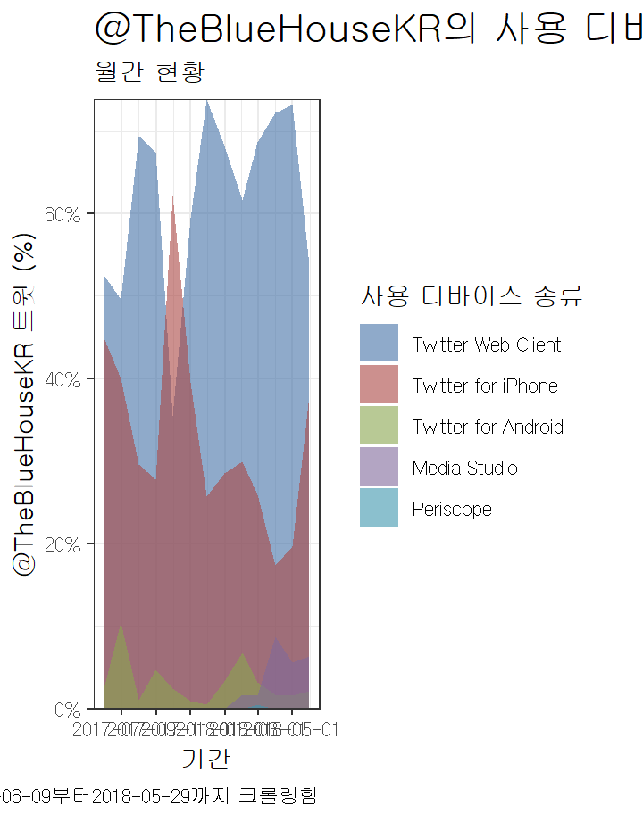

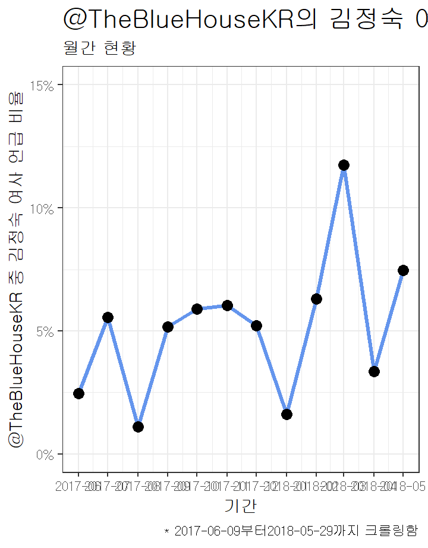

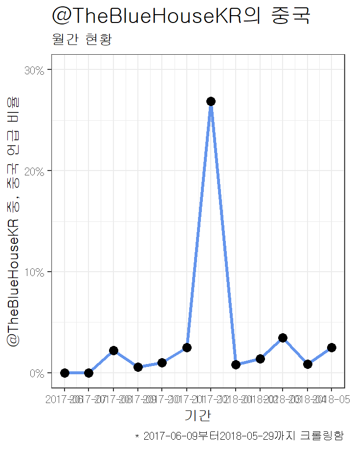

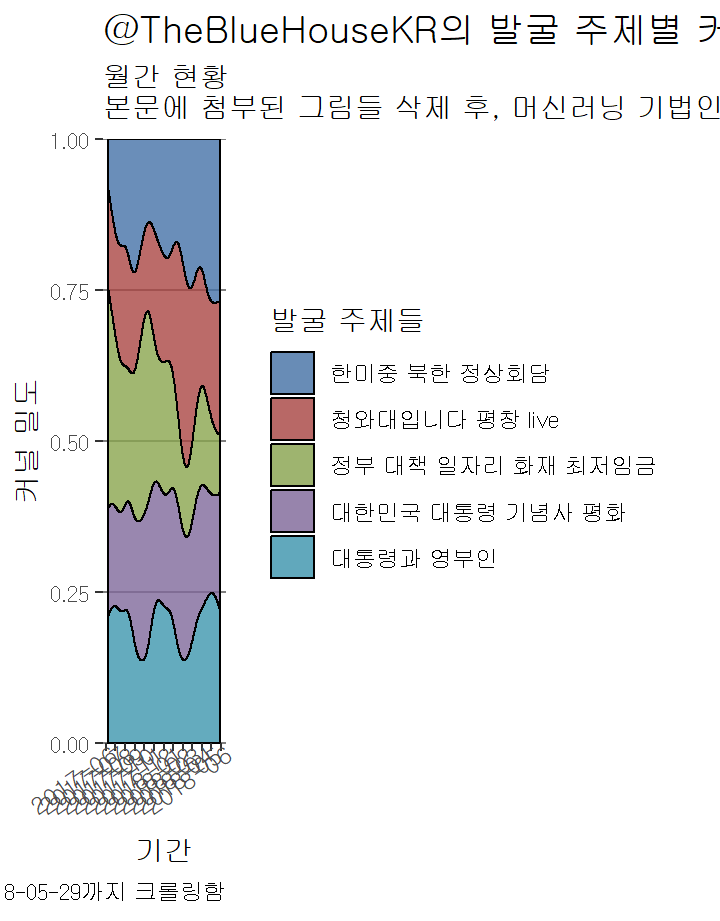

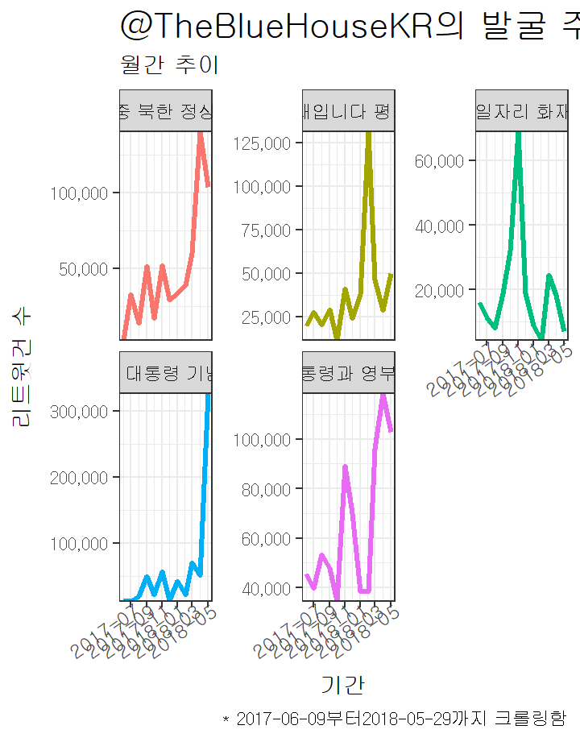

# Intro

참조 사이트 :

- https://rstudio-pubs-static.s3.amazonaws.com/342596_14ebb1f7375f49f189a9d5cec5401e5d.html#
- https://columbia-university-qmss.github.io/trump_final_proj/
- http://4four.us/article/2010/11/latent-dirichlet-allocation-simply

# @TheBlueHouseKR

### @TheBlueHouseKR

created_at

id

full_text

retweet_count

favorite_count

source

2018-05-29 18:23:30

1001393584447176704

‘세벌대기단, 굴도리집, 겹처마, 띠살, 교살, 딱지소..혹시 도종환 장관님, 뜻을 한 번 설명하실 수 있겠습니까? 국민이 원하지 않는 정보가 엄청나게 어렵게 표시되어 있습니다." 적극적 행정에 이어 공공언어에 대한 당부도 이어졌습니다. 오늘 국무회의 현장을 전합니다. https://t.co/YUMoBEFRkr https://t.co/hynmcl8i6O

389

452

Twitter Web Client

2018-05-29 18:22:47

1001393405023285248

“법으로 금지되어 있지 않는한 적극적으로 해석해 행정을 해야합니다. 일일이 다 법에 근거가 있어야만 할 수 있다고 하니까, 행정이 늦고, 빠른 현실을 따라가지도 못합니다. 규제도 마찬가지입니다. 새로운 사업의 경우, 금지규정 없으면 일단 할 수 있다고 해석해야죠.” https://t.co/OOUSKKTh4e

799

862

Twitter Web Client

2018-05-29 17:54:34

1001386305337540608

오늘 오후 열린 가계소득동향 점검회의. 문재인 대통령과 참석자들은 금년도 1/4분기 1분위 가계소득이 줄어든 통계치를 엄중하게 보고, 그 원인에 대해 다각도로 검토했습니다. 참석자들은 1분위 소득 성장을 위한 ‘특별한’ 노력을 기울여야 한다는 데 의견을 모았습니다. https://t.co/U8pkXu2eEX https://t.co/yQEiVpz2kA

605

699

Twitter Web Client

2018-05-29 16:54:16

1001371129435467776

7월 1일부터, 노동시간을 단축합니다. 노동자는 인간다운 삶을 기업은 생산성 향상을 노동시장에는 새로운 일자리를! https://t.co/D0ukZ2ykbQ

1028

1022

Twitter Web Client

2018-05-29 14:29:27

1001334683865526272

조선일보 및 TV조선 보도 관련 김의겸 청와대 대변인의 논평입니다. https://t.co/js6Mmueg15

3458

2775

Twitter for iPhone

2018-05-29 12:57:30

1001311543764566016

오늘 오전 10시. 청와대 본관 세종실에서 제24회 국무회의가 열렸습니다. 국무회의 결과를 김의겸 청와대 대변인이 전해드립니다. https://t.co/29iHsnQQlm

893

1019

Twitter for iPhone

2018-05-28 21:47:34

1001082554651308032

RT @moonriver365: Congratulations to the Seven Music-loving Boys and Their Wings, ‘ARMY’! The songs, dance, dreams and enthusiasm of BTS en…

239730

0

Twitter for iPhone

2018-05-28 20:42:53

1001066275290791936

문재인 대통령이 ‘빌보드 200’ 1위에 오른 방탄소년단 과 ‘아미’ 에게 축하의 메시지를 보냈습니다. 방탄소년단의 도전과 성공을 청와대도 함께 축하드립니다! @BTS_twt https://t.co/Ls40qgrUzr

39000

56037

Twitter for iPhone

2018-05-28 17:53:14

1001023579620716544

이 영상을 보시면 55초만에 청년일자리대책을 정복하실 수 있습니다. 텅장이 통장이 되는 마법! 집값 교통비 지원도 오케이! 청년일자리대책 더 자세히 알아보기 ▶https://t.co/O5Uc8u2ZtH https://t.co/Gq5cofpYvl

695

770

Media Studio

2018-05-28 16:53:25

1001008526364295168

5월 26일, 일상적인 만남처럼 이뤄진 두 번째 남북정상회담. https://t.co/mxEXRERyRC

1053

1355

Twitter Web Client

2018-05-28 15:54:00

1000993576581386240

월요일마다 열리는 수보회의. 문재인 대통령은 5.26남북정상회담에 대해 ‘번잡한 절차와 형식을 생략한 것’에 큰 의미가 있다고 말했습니다. 더불어 경제 정책의 방향을 흔들림 없이 추진하고 경제성장의 혜택으로부터 소외된 저소득 국민에 대한 정책 강화를 당부했습니다. https://t.co/3j9PuMkU5Z https://t.co/YQjk94zxrY

1094

1407

Twitter Web Client

2018-05-28 11:49:44

1000932103385591808

1. 관계자들도, 기자들도, 모두가 분주했던 청와대의 주말 2. 주말동안 급변했던 한반도 상황에 대한 외신의 시각 3.외신기자들의 온라인 반응 - 풍계리에 간 외신기자들, 청와대 출입 외신기자들의 트위터를 들여다봤습니다 https://t.co/yEqANKdssR

719

969

Twitter Web Client

2018-05-27 20:16:10

1000697161955270656

“완전히 새로운 시작. 남북은 이렇게 만나야 합니다. 지금 우리는 역사의 물줄기를 바꾸고 있습니다. 한반도의 완전한 비핵화와 평화에 이르는 길이 결코 순탄하지 않을 것입니다. 그러나 반드시 성공할 것입니다. 함께 해주시기 바랍니다”두번째 남북정상회담,문재인 대통령이 직접 국민에게 전합니다 https://t.co/eIkCFdrD2S

2585

3139

Media Studio

2018-05-27 18:02:30

1000663526329827328

5.27(일) 오후 정의용 국가안보실장 주재로 NSC 상임위원회가 개최되었습니다.

상임위원들은 5.26 남북정상회담에서 합의한 고위급회담 개최 등 후속조치 방안과, 북미정상회담의 성공적 개최를 위한 우리 정부 차원의 협력방안에 대해 논의하였습니다. https://t.co/eqotmFSCYV

1023

1169

Twitter for iPhone

2018-05-27 15:27:55

1000624621865979904

RT @Mylife_KTV: #문재인 대통령이 직접 얘기한, 2차 남북정상회담 그 내용은?

5월 26일 오후에 진행된 문재인 대통령과 #김정은 위원장의 2차 #남북정상회담! 문재인 대통령은 27일 오전, 그 결과에 대해 직접 발표했습니다. 그…

743

0

Twitter for iPhone

2018-05-27 12:00:59

1000572547618893824

대통령은 어제 회담 내용을 오늘 발표하는데 대해서도 답했습니다. 북한 김정은 국무위원장의 요청에 따른 것으로 ‘북측의 형편 때문에 북측은 오늘 관련 내용을 보도할 수 있다고 하면서 우리도 오늘 발표해줬으면 좋겠다’ 는 요청을 받았다고 전했습니다. https://t.co/PMtrpeHlaJ

929

1264

Twitter Web Client

2018-05-27 11:58:27

1000571910655131648

대통령은 브리핑 직후 이어진 기자들의 질문에도 직접 답변했습니다. 기자들은 ‘어제 회담이 북미정상회담에 끼칠 영향과 남은 변수, 김정은 국무위워장의 비핵화 의지’ 등에 대해서 질문했습니다. 대통령은 김정은 위원장의 비핵화 의지가 확고하다는 것을 다시금 강조했습니다. https://t.co/EnLs3oLm4z

880

1234

Twitter Web Client

2018-05-27 11:55:50

1000571251176361984

“6.12 북미정상회담을 앞둔 준비 과정에서 약간의 어려운 사정들이 있었습니다. 그런 사정들을 불식시키고, 북미정상회담 성공을 기원하는 것, 그리고 또 4.27 판문점선언의 신속한 이행을 함께 해나가는 것이 매우 중요한 시점이라고 보았습니다.” - 5월 27일 춘추관 브리핑에서 문재인 대통령 https://t.co/bxX928nI5A

601

555

Twitter Web Client

2018-05-27 11:53:30

1000570663801839616

문재인 대통령은 오늘 오전 10시, 청와대 춘추관을 찾아 어제 이뤄진 두 번째 남북정상회담에 대해 직접 브리핑했습니다. https://t.co/u9ez6qR0h1

605

640

Twitter Web Client

2018-05-27 11:24:06

1000563264709787648

문재인 대통령은 오늘 오전 10시에 청와대 춘추관에서 어제 이뤄진 5.26 남북정상회담 결과에 대해 직접 브리핑하고 기자들의 질문에 답변했습니다. 브리핑 직후 이뤄진 기자들과의 질의응답 내용입니다. https://t.co/Mx4OKPhgZu https://t.co/o5H3Kw4QP2

1336

1640

Twitter Web Client

2018-05-27 10:18:34

1000546771863457792

RT @moonriver365: 존경하는 국민 여러분!

저는 어제 오후, 판문점 북측지역 통일각에서 김정은 국무위원장과 두 번째 남북정상회담을 가졌습니다. 지난 4월 27일 판문점 평화의 집에서 첫 회담을 한 후, 꼭 한 달만입니다. http…

15895

0

Twitter for Android

2018-05-27 09:50:22

1000539673972785152

잠시 후, 문재인 대통령이 어제 열린 두번째 남북정상회담 결과에 대해 직접 발표할 예정입니다. 청와대 춘추관 라이브입니다. https://t.co/zhquknJ8BY

1386

1581

Twitter for iPhone

2018-05-27 09:33:03

1000535316644560896

문재인 대통령과 김정은 국무위원장은 회담을 마치고 북한 조선인민군 명예위병이 정렬한 가운데 회담장인 통일각을 나섰습니다. 두 정상은 악수와 포옹을 나눴습니다. 김 국무위원장은 문 대통령의 차량이 떠날 때까지 배웅했습니다. 한반도 평화와 번영을 위한 두 정상의 노력은 계속될 것입니다. https://t.co/gBzqbJIYIj

1400

1674

Twitter Web Client

2018-05-27 09:27:34

1000533937637081088

26일 오후 3시쯤 통일각 회담장에서 시작된 남북정상회담은 2시간 가까이 이어졌습니다. 서훈 국가정보원장과 북한 노동당 중앙위원회 김영철 부위원장 겸 통일전선부장이 배석했습니다. https://t.co/ZMBAiFWtVV

1187

1483

Twitter Web Client

2018-05-27 09:22:04

1000532553281912832

남북정상회담이 열린 판문점 북측 통일각에는 김여정 북한 노동당 중앙위원회 제1부부장과 함께 조선인민군 명예위병들이 문재인 대통령을 맞이했습니다. 김정은 국무위원장은 문 대통령과 기념촬영을 한 뒤 남측 수행원들과 악수하며 반갑게 인사를 나눴습니다. https://t.co/iPsGmicNXj

822

735

Twitter Web Client

2018-05-27 09:14:03

1000530537352646656

문재인 대통령과 김정은 국무위원장의 두번째 정상회담. 현장 모습 추가로 전합니다. 문 대통령은 판문점 북측 통일각 방명록에 ’한반도의 평화와 번영, 조선민주주의인민공화국 김정은위원장과 함께! 2018.5.26 대한민국 대통령 문재인’이라고 글을 남겼습니다. https://t.co/ECH5ZXFETk

2626

2812

Twitter Web Client

2018-05-26 21:02:53

1000346530539171840

26일 문재인 대통령과 김정은 국무위원장의 두번째 정상회담, 영상으로 전하는 현장 모습입니다. https://t.co/fVyFt5j34o

5714

6055

Media Studio

2018-05-26 20:14:52

1000334450524176384

이날 문재인 대통령은 통일각에서 김여정 노동당 중앙위원회 제1부부장도 만나 반갑게 인사를 나눴습니다. 정상회담에는 서훈 국정원장과 김영철 북한 통일전선부장이 함께 했습니다. https://t.co/gOd1FtYbU5

3481

4238

Twitter Web Client

2018-05-26 20:10:10

1000333266296098816

문재인 대통령과 김정은 국무위원장이 26일 오후 판문점 북측지역 통일각에서 만난 모습입니다. https://t.co/IMARcJ9pRY

9519

9517

Twitter Web Client

2018-05-26 19:52:31

1000328825170022400

양측 합의에 따라 회담 결과는 내일 오전 10시 문 대통령께서 직접 발표할 예정입니다. 국민소통수석 윤영찬

4275

2265

Twitter Web Client

2018-05-26 19:52:11

1000328738549088256

문재인 대통령은 26일 오후 3시부터 5시까지 판문점 북측지역 통일각에서 김정은 국무위원장과 두 번째 정상회담을 개최했습니다. 양 정상은 4.27 판문점 선언의 이행과 북미 정상회담의 성공적 개최를 위해 허심탄회하게 의견을 교환했습니다.

10366

5918

Twitter Web Client

2018-05-25 17:17:38

999927458106232832

한반도 비핵화와 항구적 평화는 포기할 수도, 미룰수도 없는 역사적 과제입니다. https://t.co/RA8GEyzWUN

2165

2565

Twitter Web Client

2018-05-25 16:37:43

999917414593642496

오늘 오후 3시부터 4시까지 정의용 국가안보실장 주재로 개최된 NSC 상임위원회 회의 결과 관련, 윤영찬 국민소통수석의 브리핑을 전해드립니다. https://t.co/an41NR3i4t

868

972

Twitter for iPhone

2018-05-25 16:24:17

999914033862995968

NSC 회의결과에 대한 윤영찬 국민소통수석의 브리핑이 생중계 됩니다. https://t.co/4zJ89ohk5c

377

554

Twitter for iPhone

2018-05-25 14:43:07

999888572009213952

‘로드리고 두테르테’ 필리핀공화국 대통령이 문재인 대통령의 초청으로 6월3일부터 5일까지 우리나라를 공식방문 합니다. https://t.co/AIsH4FqSnR

727

727

Twitter for iPhone

2018-05-25 14:37:58

999887276019564544

문재인 대통령은 김용 세계은행(World Bank)총재와 만남을 가졌습니다. 세계은행은 세계의 빈곤 퇴치와 개발도상국의 경제 발전을 목표로 하는 다자개발은행입니다. 오늘 만남에서 문 대통령은 “아프리카의 경제 개발에 더 적극적으로 기여할 뜻이 있다”고 밝혔습니다. https://t.co/GxOjezHmrr https://t.co/la9qdMh3IM

839

999

Twitter Web Client

2018-05-25 11:55:33

999846405563858944

RT @moonriver365: 촛불 민심을 헌법에 담기 위한 개헌이 끝내 무산됐습니다. 국민과의 약속을 지키지 못해 매우 송구스럽고 안타깝습니다. 이번 국회에서 개헌이 가능하리라고 믿었던 기대를 내려놓습니다. 언젠가 국민들께서 개헌의 동력을 다시…

12603

0

Twitter Web Client

2018-05-25 11:49:38

999844913716969472

국민청원에 답합니다. 215,036명이 참여한 ‘세월호 관련 청문회 위증 조여옥 대위 징계’청원. 정혜승 뉴미디어비서관이 답변합니다. https://t.co/XY51aQyDW1

449

539

Twitter Web Client

2018-05-25 10:21:08

999822641220354048

RT @mofa_kr: 강경화 장관은 폼페오 美 국무장관과 전화통화를 갖고, 북미 정상회담 관련 트럼프 대통령 발표 등 상황을 공유하며 향후 추진 방향에 대해 심도있는 논의를 가졌습니다. 폼페오 장관은 이번 발표 배경 등을 설명하고, 미측으로서도 북…

2041

0

Twitter for iPhone

2018-05-25 01:34:40

999690151700787200

문제 해결을 위해 노력해온 당사자들의 진심은 변하지 않았다. 지금의 소통방식으로는 민감하고 어려운 외교 문제를 해결하기 어렵다. 정상간 보다 직접적이고 긴밀한 대화로 해결해 가기를 기대한다. - 대통령 문재인 -

3557

3241

Twitter Web Client

2018-05-25 01:34:21

999690075007893504

[문재인 대통령은 25일 0시부터 1시간 동안 NSC 상임위원 긴급회의를 소집하고 다음과 같은 입장을 표명했습니다.] 북미정상회담이 예정된 6월12일에 열리지 않게된데 대해 당혹스럽고 매우 유감이다. 한반도 비핵화와 항구적 평화는 포기할 수도, 미룰수도 없는 역사적 과제이다.

4050

3394

Twitter Web Client

2018-05-24 20:32:03

999613995806965760

앤드류스 합동기지에 도착한 대통령을 기내영접하기 위해 1호기를 바삐 오르는 조윤제 주미대사의 모습. Photo by 최종건 평화군비통제 비서관입니다. https://t.co/3R9qCzZeLR

267

443

Twitter for iPhone

2018-05-24 20:23:10

999611763422195712

숨가빴던 워싱턴 일정을 마치고 1호기에 몸을 실었습니다. 세차게 내리던 비는 멈추고 무지개가 떠오르는 순간. 곧 날이 저물어갑니다. 서울로 돌아가는 길. 교민들과 대통령과의 짧은 만남, 그 감동을 가슴에 담고 갑니다. https://t.co/hpBOC8vTxB

386

714

Twitter for iPhone

2018-05-24 20:21:26

999611325067096064

항상 따뜻한 커피와 브라우니가 놓여있는 블레어 하우스의 거실. 뉴욕 타임즈가 놓여있는 책상. 10개월 만에 다시 온 블레어 하우스는 그대로 고풍스러운 모습이네요. https://t.co/GGoLUl53OD

276

533

Twitter for iPhone

2018-05-24 20:19:25

999610817833189376

주미대한제국공사관 앞에서 대통령을 기다리던 교민들을 만났습니다. “사랑해요 문재인! 지지해요 끝까지!” 빗 속에서 외쳐주시고 기다려주시던 마음을 잊지 않겠습니다. 안전사고 대비를 위해 잠시 도로를 통제하는 미국 측 경호원들. https://t.co/V8j64u0aOT

487

788

Twitter for iPhone

2018-05-24 20:18:01

999610464525996032

한미정상회담 직후, 백악관을 떠나 워싱턴 시내 호텔에 마련된 프레스센터로 달려온 윤영찬 수석이 기자들을 만났습니다. 내, 외신의 열띤 취재경쟁. 현지 통역사의 도움을 받아 해외 통신사 기자들도 윤 수석의 브리핑을 받아 적습니다. https://t.co/S2x8QDSc79

327

546

Twitter for iPhone

2018-05-24 20:16:31

999610089668423680

블레어 하우스의 접견실 리 드로잉 룸에서 문재인 대통령을 기다리는 폼페이오 장관과 볼튼 보좌관의 뒷 모습. 잠시 후, 문재인 대통령이 내려옵니다. https://t.co/ILHpZUNiDB

239

238

Twitter for iPhone

2018-05-24 20:14:24

999609556484308992

백악관에서의 정상회담 전. 볼튼 보좌관, 정의용 실장, 조윤제 대사, 강경화 장관, 윤영찬 수석과 폼페이오 장관 등 한미 수행원들이 대화 중입니다. 강경화 장관의 포즈와 표정을 보니 무슨 대화를 나누었을지 궁금합니다. https://t.co/pyfCuUYH09

641

875

Twitter for iPhone

2018-05-24 20:04:14

999606995794575360

1박 4일의 워싱턴 방문. 짧고 굵은 일정 속에서도 대통령과 함께 일하는 사람들의 이야기는 계속됩니다. 정상회담 직전의 수행원들, 공사관 앞에서 만난 교민들이 선사한 감동. 청와대 B컷으로 보세요. https://t.co/y6CbZM7KAl https://t.co/EnTstWbAqU

902

1129

Twitter for iPhone

2018-05-24 18:51:38

999588727407104000

법과, 제도, 예산으로 개헌의 정신을 살려나가겠습니다. https://t.co/oPhsdm1nC2

764

879

Twitter Web Client

2018-05-24 16:46:43

999557288946946048

상임위 위원들은 풍계리 핵실험장 폐기와 관련, 북한의 핵실험장 폐기가 북한의 완전한 비핵화를 위한 첫 번째 조치임을 평가하고, 폐기 참관 동향 점검 및 향후 조치에 대해서도 논의했습니다.

414

577

Twitter Web Client

2018-05-24 16:46:42

999557287059472384

오늘, 정의용 국가안보실장 주재로 NSC 상임위원회 회의가 개최되었습니다. 상임위 위원들은 22일 한미 정상간 이루어진 솔직한 의견 교환을 바탕으로 6.12로 예정된 북미 정상회담의 성공적 개최를 위한 정부 차원의 다각적인 지원방안을 심도있게 논의했습니다.

554

743

Twitter Web Client

2018-05-24 16:11:10

999548342412558336

RT @moonriver365: 한미정상회담차 가는 미국행 비행기 안에서, 주치의 송인성 박사가 한 번 읽어보라며 여러 겹 접은 신문을 건네주었습니다. ‘도보다리 풍경’ 의 묘사는 정말 압권이었습니다. 저는 그 때 그 풍경 속에 있었고, 이 글을 통…

5527

0

Twitter Web Client

2018-05-24 15:41:39

999540914426032128

워싱턴 D.C의 주미대한제국공사관 앞, 비바람이 몰아치는 와중에 수십 여명의 교민들이 문재인 대통령을 응원하러 와 주셨습니다. 응원해 주시던 교민들의 모습, 감사를 드리는 대통령의 모습. 휴대폰 카메라로 찍은 영상이지만 현장의 생생함을 담았습니다. 고맙습니다. 늘 기억하겠습니다. https://t.co/oNptpXR9R0

1718

2266

Media Studio

2018-05-24 15:11:02

999533212224311296

문재인 대통령이 발의한 개헌안이 오늘 국회에서 ‘투표 불성립’되었습니다. 이에 대한 김의겸 청와대 대변인의 논평입니다. https://t.co/WWLn5RWaln

2144

1210

Twitter for iPhone

2018-05-24 15:01:12

999530736016228352

개헌안 처리 관련 김의겸 청와대 대변인의 브리핑입니다. https://t.co/G9KaZDdQuC

410

457

Twitter for iPhone

2018-05-24 11:50:23

999482717073899520

오늘 11시 50분에서는 1. 1박 4일의 미국 워싱턴 방문과 한미정상회담의 생생한 뒷이야기 2.한미정상회담 관련보도, 이렇게 봅니다 3. 외신이 본 한미정상회담까지. 세 가지 소식을 전해드립니다 :) 청와대라이브 보시고 맛점하세요! https://t.co/iYtTkd3VPw

451

619

Twitter Web Client

2018-05-23 18:10:17

999215934362431488

한미정상회담을 통해 다시 한 번 확인한 평화와 번영을 향한 단단한 동맹. https://t.co/Rx9F39sdLo

1055

1480

Twitter Web Client

2018-05-23 18:08:11

999215404193955840

22일 열린 문재인 대통령과 트럼프 대통령의 정상회담. 많은 해외 언론도 이번 한미정상회담을 주목했는데요. 외신이 바라본 한미정상회담은 어떤 모습일까요? https://t.co/mOI9YKaZ9z https://t.co/Qj1uTYJU1x

869

954

Twitter Web Client

2018-05-23 15:55:38

999182046986551296

RT @moonriver365: 1882년 5월 22일 조선과 미국 사이에 조미수호통상조약이 체결됐습니다. 우리가 자주적으로 체결한 최초의 근대조약입니다. 기울어가는 국운을 외교를 통해 지켜보려던 노력이었습니다. 136년이 흐른 바로 그 날 한미정…

4727

0

Twitter Web Client

2018-05-23 11:50:34

999120373219184640

점심먹기전에는? 청와대라이브와 함께! 세 가지 소식 전해드립니다. 1. 북한, 풍계리 핵실험장 폐기 우리 측 기자단 명단 접수 2. ‘북한의 1만 달러 요구’ 명백한 오보입니다 3. 외신이 본 한미정상회담 https://t.co/RJXU2qWtsS

541

696

Twitter Web Client

2018-05-23 10:17:44

999097010690011136

모든 방미 일정을 마치고 한국으로 돌아갑니다. 문재인 대통령은 현지시간으로 22일 저녁, 앤드루스 공군기지에서 환송행사를 마친 후 귀국길에 올랐습니다. 문재인 대통령은 24일 새벽, 서울 공항에 도착할 예정입니다. https://t.co/1vTnluIqVF

1300

1770

Twitter Web Client

2018-05-23 08:46:55

999074155499741184

트럼프 대통령과 정상회담을 마친 문재인 대통령은 미국 마지막 일정으로, 워싱턴D.C.에 있는 주미대한제국공사관을 찾았습니다. 1889년 우리 역사상 최초로 서양국가에 설치한 외교공관이지만 1910년 일본에게 단돈 5달러에 강제 매입당한 아픈 역사를 가지고 있습니다. https://t.co/bfppvJ2GZa https://t.co/03fWnjYNkN

1287

1395

Twitter Web Client

2018-05-23 04:44:51

999013237847969792

윤영찬 국민소통수석은 워싱턴 D.C에서 진행한 브리핑에서 한미정상회담에 대해 전했습니다. 양 정상은 6월12일로 예정된 북미정상회담이 차질 없이 진행될 수 있도록 최선을 다하자는 데 의견을 모으고 판문점 선언에서 천명한 종전선언 이행에 대해서도 논의했습니다. https://t.co/WITD3LuXLC https://t.co/jW5G9PFkPS

853

974

Twitter for iPhone

2018-05-23 04:13:06

999005249938640896

김정숙 여사가 미국 부통령 부인인 카렌 펜스 여사와 다시 만났습니다. 평창동계올림픽 이후 세 번째 재회로 두 사람은 D.C의 역사적 주택인 디케이터 하우스Decatur house 를 함께 돌아보고 오찬을 나누며 평화를 기원했습니다. https://t.co/MlEmjkJI4i https://t.co/TCBCSbJYzs

1050

1416

Twitter for iPhone

2018-05-23 03:32:45

998995092248592384

“트럼프 대통령께서 북미정상회담도 성공시켜서 한국전쟁을 종식시키고, 북한의 완전한 비핵화를 이루고 한반도의 항구적인 평화체제를 구축할 수 있을 것이라 확신합니다.” 문재인 대통령과 트럼프 대통령의 단독 정상회담은 예정에 없던 기자간담회로 이어졌습니다. https://t.co/4ou47Qbe9P https://t.co/y5Ys18AIzb

1515

1734

Twitter for iPhone

2018-05-23 01:00:03

998956664475676672

RT @WhiteHouse: Today, President Trump welcomes President Moon Jae-in of the Republic of Korea to the White House. https://t.co/jZbP4A7py8

1730

0

Twitter for iPhone

2018-05-23 00:54:12

998955192597954560

문재인 대통령이 한미정상회담을 위해 백악관에 도착하는 모습입니다. 라이브로 전해드립니다. https://t.co/5BTIk8SDor

1032

1508

Twitter for iPhone

2018-05-23 00:34:14

998950169529012224

미국을 방문중인 문재인 대통령은 22일 오전(미국 현지시간) 워싱턴 영빈관에서 마이크 폼페이오 국무장관, 존 볼튼 백악관 국가안보보좌관을 접견하고 내달 12일로 예정된 역사적 미북정상회담의 성공을 위해 최선을 다해달라고 당부했습니다. https://t.co/2B7kZX1iBf https://t.co/AcYE1IqKp6

1034

1241

Twitter for iPhone

2018-05-22 16:29:46

998828248112009216

한미정상회담을 위해 날아온 이 곳은 워싱턴 D.C 입니다. 미국의 수도이며 정치의 중심지인 D.C는 인상적인 건축물로 가득합니다. 워싱턴 기념탑, 국회의사당, 링컨 기념관과 백악관이 그것이죠. 1박 4일의 숨가쁜일정, 문재인 대통령이 머무는 워싱턴의 밤을 청와대 전속 사진작가가 담았습니다. https://t.co/yS8VuFSjdS

1225

1477

Twitter for iPhone

2018-05-22 13:20:58

998780736395243520

11:50 청와대입니다 in Washington D.C 한미정상회담이 열릴 워싱턴 디씨에 왔습니다. 1박 4일의 일정 소개, 5번째 한미정상회담을 보는 미국 현지 언론 동향, 한미, 북미회담의 성공과 평화를 기원하며 워싱턴에서 전하는 11:50 함께 보세요. https://t.co/e1dewu8XEk

660

899

Twitter for iPhone

2018-05-22 11:39:06

998755098070167552

“6.12 정상회담을 어떻게 성공적으로 성사시키고 중요한 합의를 이룰 수 있게 할지, 합의를 이룰 경우 그 합의를 어떻게 잘 이행할 것인가에 대한 두 정상간 허심탄회한 논의가 있을 것입니다.” 워싱턴 가는 길, 정의용 청와대 국가안보실장의 기내 기자간담회 내용입니다. https://t.co/riCcy22krz

1156

1353

Twitter Web Client

2018-05-22 08:57:02

998714316474888192

13시간 40분의 비행 끝에 미국 시간으로 21일 오후 5시 40분 경 앤드류스 공군기지에 도착했습니다. 조윤제 주미대사 부부를 비롯 미국 측 핸더슨 의전장 대리, 마크 내퍼 주미대사 대리, 램버트 동아태부차관보 대행, 태쳐트 앤드류스 기지 비행단장 등이 맞이했습니다. https://t.co/fFLA1A13ti

1682

2124

Twitter for iPhone

2018-05-21 17:22:31

998479137521131520

다녀오겠습니다. https://t.co/1MvuVlIZSO

1026

1606

Twitter for iPhone

2018-05-21 17:18:18

998478073258377216

문재인 대통령은 21일 오후 서울공항을 통해 미국 워싱턴으로 출발했습니다. 이6월로 예정된 북미 정상회담을 앞두고 한미 양국 정상의 의견을 교환하기 위한 공식실무방문입니다. 총 체류시간이 24시간이 안 되는, 1박 4일의 일정, 청와대 페이스북, 트위터, 유튜브로 소식 전하겠습니다. https://t.co/VyLNJp1WkT

1486

1832

Twitter for iPhone

2018-05-21 11:48:46

998395146491211776

세 가지 국민청원에 지금! 답변합니다. o 여성도 대한민국 국민, 국가 보호 요청 o 몰카 범죄 처벌 강화 o 합정 불법누드 촬영 수사 및 진상규명 페이스북 ▶ https://t.co/xp75JwL3Gy  
유튜브 ▶https://t.co/SDzAXVX4ik  
인스타그램 ▶ https://t.co/1ZdXNcYKiz https://t.co/Hk6Qu1Uze9

1456

533

Twitter Web Client

2018-05-21 10:25:21

998374152116494336

국민청원에 답합니다. o ‘여성도 대한민국 국민, 국가 보호 요청’ 청원 o ‘몰카 범죄 처벌 강화’ 청원 o ‘합정 불법누드 촬영 수사 및 진상규명’ 청원 페북▶ https://t.co/xp75JwL3Gy  
유튜브▶https://t.co/SDzAXVX4ik  
인스타▶ https://t.co/1ZdXNcYKiz https://t.co/lMimKULa5k

1259

515

Twitter Web Client

2018-05-20 17:14:40

998114773869912064

반장식 청와대 일자리수석은 춘추관에서 기자들과 만나 일자리 상황과 전망에 관해 이야기를 나눴습니다. 반 수석은 일자리 안정자금 안착과 고용 여건 회복, 중국 관광객 회복 조짐, 노동시간 단축 정책 효과 등이 향후 일자리에 긍정적 요인이 될 것으로 전망했습니다. https://t.co/EOYwJ9PZeJ https://t.co/3bI3h5D1RJ

618

773

Twitter for Android

2018-05-20 15:59:21

998095818698588160

성년의 날을 맞아 김정숙 여사와 청년들이 함께한 특별한 자리. 김정숙 여사는 맞아 ‘홀로서기’의 첫 걸음을 내딛는 보호 종료 아동에게 멘토 활동을 하고 있는 ‘바람개비 서포터즈’ 선배들을 격려하고 만찬을 함께했습니다. https://t.co/1h1vMp5QLz https://t.co/t4Kp5eQYUo

1086

1493

Twitter for iPhone

2018-05-20 14:07:05

998067566659616768

문재인 대통령은 20일 오전 11시30분부터 20분간 도널드 트럼프 대통령과 통화했습니다. 양 정상은 최근 북한이 보이고 있는 여러가지 반응들에 대해 의견을 교환했습니다. https://t.co/PwEZQglodS

1202

1456

Twitter for iPhone

2018-05-18 16:02:33

997371846587641856

문재인 대통령은 5월21일, 22일 양일간 미국을 공식 실무 방문하여 트럼프 대통령과 5월22일 백악관에서 정상회담 등 일정을 가질 예정입니다. 이와 관련해 남관표 국가안보실 제2차장이 브리핑을 가졌습니다. https://t.co/ubGuYpiPHa

1217

1327

Twitter for iPhone

2018-05-18 15:07:08

997357902489767936

5.18 민주화운동 38주년입니다. 광주의 오월, 잊지 않겠습니다. https://t.co/LL4XIzK7P2

1096

1006

Twitter Web Client

2018-05-18 14:10:09

997343562411880448

RT @moonriver365: 짓밟힌 여성들의 삶을 보듬는 것에서 진실의 역사를 다시 시작하겠습니다. 민주주의의 가치만큼 소중한, 한 사람의 삶을 치유하는 데 무심하지 않았는지 돌아보겠습니다. 광주라는 이름으로 통칭되었던 한 사람 한 사람의 삶을…

18197

0

Twitter Web Client

2018-05-18 11:49:23

997308138624708608

오늘은 제38주년 5.18 민주화운동 기념일입니다. 청와대 라이브, 두 가지 소식 전해드립니다. 1. 5.18 민주화운동 기념식, 기억하겠습니다. 2. 혁신성장보고대회 돌아보기 ‘일자리를 만드는 혁신성장, 대한민국 30년 먹거리’ 만들겠습니다. https://t.co/5NJlGVPG7H

503

687

Twitter Web Client

2018-05-18 10:02:36

997281262573309952

RT @Mylife_KTV: [KTV Live] 이낙연 총리 참석 제38주년 5·18 민주화운동 기념식 https://t.co/SBOsLQ32io

793

0

Twitter Web Client

2018-05-17 18:31:27

997046932550791168

‘혁신성장’ 국민이 피부로 느낄 수 있도록 하겠습니다. https://t.co/KKWLuPjfr2

545

642

Twitter Web Client

2018-05-17 18:19:36

997043951931572224

⚡️국민과 함께 달려온 문재인 대통령과 정부의 1년을 다양한 콘텐츠로 돌아봤습니다. 5월 10일 아침 출근길의 대통령, 분주한 청와대의 아침, 국민의 품으로 돌아가는 인왕산과 청와대 녹지원에서의 1주년 기념 주민초청 음악회. 그리고 대통령의 1주년 메시지까지.

https://t.co/IVpSaKaWHP

1313

1631

Twitter Web Client

2018-05-17 16:53:32

997022290255560704

혁신성장 정책의 성과를 점검·평가 하고 추진계획을 논의하는, ‘2018년 대한민국 혁신성장 보고대회’! 문재인 대통령은 “국민들이 혁신기술을 실생활에서 사용할 수 있어야 한다”며 “경제가 새롭게 도약하기 위해서는 혁신성장에 반드시 성공해야 한다”고 말했습니다. https://t.co/ZSWW1S9Bt2 https://t.co/RP9QCdPKI7

783

924

Twitter Web Client

2018-05-17 14:08:30

996980759343677440

RT @Mylife_KTV: [KTV Live] 문 대통령 주재 혁신성장점검회의 - 문재인 대통령모두발언 및 김동연 부총리 발표 https://t.co/Dte5NTaqGF

339

0

Twitter for iPhone

2018-05-17 11:48:49

996945606613479424

봄비 내리는 촉촉한 목요일, 세가지 소식 전해드립니다. 1.국가안전보장회의 NSC 개최 등 청와대 일정 2. 노동시간 단축, 외환시장 안정화 조치 등 경제 챙기는 정부 3.외신이 본 대통령 취임 1년 + 깜짝 영상 공개! https://t.co/rI1s25pvGE

357

502

Twitter Web Client

2018-05-17 10:26:39

996924927956549632

부정부패를 이겨내며 보편적 평등, 페미니즘, 남북화해를 향해 나아가고 있는 대한민국. 외국인들이 얻을 수 있는 기회도 더 다양해졌다고 합니다. 토드 샘플, 연세대학교 교수 존 델러리, 부산대학교 교수 로버트 켈리, 문명비평가 기 소르망 등 해외 전문가들이 문재인 정부의 1년을 돌아봤습니다. https://t.co/DnMPhMNKEl

1195

1326

Media Studio

2018-05-17 10:07:35

996920130956226560

또한, 상임위 위원들은 풍계리 핵실험장 폐기 참관, 6･15 공동행사 준비 등 앞으로의 남북관계 일정들을 판문점선언의 합의 정신에 따라 차질없이 이행해 나가기로 했습니다.

370

545

Twitter Web Client

2018-05-17 10:07:35

996920129169453056

위원들은 판문점선언이 차질없이 이행되어야 한다는 입장을 재확인하고, 남북고위급회담의 조속한 개최를 위해 북측과 계속 협의해 나가기로 했습니다. 또한 북미정상회담이 성공적으로 진행될 수 있도록 한미 간과 남북 간에 여러 채널을 통해 긴밀히 입장을 조율해 나가기로 했습니다.

441

599

Twitter Web Client

2018-05-17 10:07:34

996920127634292736

<14차 NSC 상임위원회 개최 결과> 오늘 오전 7시, 정의용 국가안보실장 주재로 NSC 상임위원회 회의가 개최되었습니다. 상임위에서는 북한이 5월 16일, 예정된 남북고위급회담 연기를 통보해 온 것과 관련한 향후 대책에 대해 논의했습니다.

559

713

Twitter Web Client

2018-05-16 15:34:39

996640051034443776

<1년차에는 국민안전, 2년차에는 지방분권!_11:50 하이라이트 with 김부겸 행정안전부 장관>3.7일에 1번 꼴로 현장을 찾은 김부겸 장관, 정부 2년차에는 ’지방이양일괄법’을 추진해 지방정부가 확실한 권한과 재정 뒷받침 속에서 행정·복지·교육 서비스를 할 수 있도록 이어가겠다는 다짐을 했습니다. https://t.co/6IeCmheIhl

715

843

Media Studio

2018-05-16 11:48:52

996583229514702848

‘11시50분 청와대입니다’ 국민청원에 답합니다. ‘미세먼지 대책마련 청원’ with 김혜애 기후환경 비서관 https://t.co/lvqWRaXnMo

239

372

Twitter for Android

2018-05-16 10:12:41

996559024580521984

오늘 ‘11시50분 청와대입니다’에서는 김혜애 기후환경비서관이 출연해 ’미세먼지 대책 마련’ 청원에 대해 답변합니다. https://t.co/GycRZ7Oqpt

251

340

Twitter Web Client

2018-05-15 18:55:36

996328232445100032

문재인 대통령은 가정폭력, 데이트폭력, 몰카범죄 등 여성 대상 범죄의 심각성을 지적하며 이런 사건들을 다루는 ‘관점의 대전환’ 을 주문했습니다. “성차별적 사회를 바꿔나갑시다, 사건을 다루는 관점의 변화가 필요합니다.” - 2018년 5월 15일, 문재인 대통령 SNS 메시지 중에서 https://t.co/srikqXln90

1793

1362

Twitter Web Client

2018-05-15 17:23:58

996305173440950272

<11:50 청와대입니다>일년 동안 98번, 3일에 한 번 꼴로 현장을 찾아 국민안전을 챙겼던 김부겸 행정안전부 장관을 만났습니다. 그가 말하는 1년의 성과와 2년 차의 목표는? 그리고 얼굴 작아보이도록 셀카 찍는 비결은? 11:50 청와대입니다에서 확인하세요. https://t.co/q5qx4MPHiy https://t.co/5Ix7IDjKT3

473

629

Twitter for iPhone

2018-05-15 17:03:29

996300016728788992

‘11시50분청와대입니다’ 하이라이트 with도종환 문체부장관!  
평양공연단과 단체 사진을 찍기 전, 김정은 위원장의 한마디는 무엇이었을까요? 평창올림픽부터 2018 남북정상회담까지.도종환 장관이 이야기하는 남북 화해의 뒷이야기와 문체부의 지난1년을 돌아봅니다. https://t.co/819Fl36QQW

648

815

Media Studio

2018-05-15 14:04:43

996255031765561344

추경 관련 이낙연 국무총리의 시정연설 생중계입니다. https://t.co/TbBOHmWsdz

637

733

Twitter for iPhone

2018-05-15 11:48:11

996220671268028416

김부겸 행정안전부 장관과 함께합니다. 문재인 정부 1년, 행안부의 성과를 돌아보고 앞으로의 과제를 이야기합니다. 지금 청와대 라이브와 함께하세요! https://t.co/g3M4IECJJU

251

403

Twitter Web Client

2018-05-15 11:21:33

996213968350756864

오늘 ’11:50 청와대입니다’에는 김부겸 행정안전부 장관이 출연합니다. ’문재인 정부 1년, 행정안전부의 성과와 앞으로의 과제’에 대해 이야기를 나눌 예정입니다. 많은 시청 부탁드립니다. https://t.co/nKSxGXlBo4

209

330

Twitter Web Client

2018-05-15 10:39:50

996203469525561344

14일 열린 대통령주재 수석보좌관회의에서 문재인 대통령이 발언한 ’몰카범죄, 데이트 폭력" 관련 내용 공유합니다. https://t.co/iigx5FPiqx

992

967

Twitter Web Client

2018-05-15 08:32:01

996171302091214848

50년 만에 개방되는 인왕산 길. 산길을 막고 있던 날카로운 철조망을 걷어내고 잠긴 자물쇠를 없애 인왕산이 완전히 국민의 품으로 돌아갑니다. 수도 서울의 오랜 역사와 아름다움을 한 눈에 조망할 수 있는 인왕산 길, 국민과 함께 하겠습니다. https://t.co/NaxM9SmIC9

1440

1749

Media Studio

2018-05-14 18:18:51

995956598223781888

핵실험장 폐기 비핵화의 시작

“풍계리 핵실험장 폐기를 국제사회에 투명하게 공개하기로 한 것을 환영합니다“

-2018.5.14. 수석보좌관 회의에서 문재인 대통령- https://t.co/Im6A4gT7zj

921

1076

Twitter Web Client

2018-05-14 18:15:02

995955637778497536

‘11시50분청와대입니다’ 하이라이트 with김동연 경제부총리 가까운 곳에 난 불, 그런데 물은 멀리있다? ‘근화원수(近火遠水)’와 같은 한국의 일자리 상황. 김동연 경제부총리가 제시하는 해결책은 무엇일까요? 150초로 만나는 ‘11시50분 청와대입니다’ 하이라이트를 공개합니다. https://t.co/KrXEntum41

720

915

Media Studio

2018-05-14 16:47:39

995933645293568000

청원이 문을 연 작년 8월 19일부터 하루 평균 6-700개의 청원글이 올라오고 있고, 20만명 이상 추천을 받은 청원도 35건이 되었습니다. 청원 빅데이터 분석을 통해 청원에 담긴 국민의 마음을 짚어봤습니다. https://t.co/5n0sG7vb9B https://t.co/M597zSJoXV

566

570

Twitter Web Client

2018-05-14 16:30:22

995929295426998272

<11:50 청와대입니다>에 출연한 도종환 장관의 눈시울이 붉어진 이유는? 문화, 체육, 관광이 모두 위기였던 문체부 수장으로 보낸 1년, 시인 장관은 아직도 시를 쓰고 있을까요? 햇살 좋은 오늘, 청와대 상춘재에서 도종환 장관에게 물어봤습니다. https://t.co/bJeyzNL73i https://t.co/KCuyQEChEV

616

775

Twitter Web Client

2018-05-14 16:10:57

995924411654946816

매주 월요일 열리는 수석보좌관 회의. 문재인 대통령은 북한이 풍계리 핵실험장 폐기를 국제사회에 공개하기로 한 것을 높이 평가했습니다. 또한 8월에 있을 ‘국가인권위원장’의 투명한 임명 절차를 당부하고 ‘역외탈세’에 대한 조사와 처벌, 범죄수익의 환수를 지시했습니다. https://t.co/b04NYgjHXO https://t.co/3Z5DIvz8mn

1046

1240

Twitter Web Client

2018-05-14 11:50:12

995858788916781056

도종환 문화체육관광부 장관과 함께합니다. 문재인 정부 1년, 문체부 성과와 과제 그리고 남북 화해 뒷이야기를 들어봅니다. 페이스북 ▶ https://t.co/xp75JwL3Gy  
유튜브 ▶https://t.co/SDzAXVX4ik  
인스타그램 ▶ https://t.co/1ZdXNcYKiz https://t.co/1cdxduIrfB

227

356

Twitter Web Client

2018-05-14 11:03:15

995846974959009792

도종환 문체부 장관이 ’11:50 청와대입니다’에 출연합니다. 문재인 정부 1년, 문체부의 성과와 과제 그리고 남북 화해의 뒷이야기까지! 11시 50분, 청와대 라이브(유튜브,페이스북,인스타그램)와 함께하세요. https://t.co/CyBcFoNqke

320

512

Twitter Web Client

2018-05-13 16:49:43

995571777496465408

청와대 민정수석실이 ‘적폐청산’의 추진경과와 성과, 방향에 대해 밝혔습니다. 권력형적폐 청산에 주력했던 1년, 분야별 적폐사안에 대한 진상조사, 재발방지 대책이 수립되었으며 잘못된 관행은 바로잡히고 있습니다. 앞으로는 민생 속 ’생활적폐’ 청산에 주력할 계획입니다. https://t.co/rM3e0FKwEj

1619

1868

Twitter Web Client

2018-05-13 11:10:40

995486451759394816

북한이 풍계리 핵실험장을 23일부터 25일 사이에 폐쇄하겠다고 발표했습니다. 환영합니다. 북미정상회담에 앞서 두 나라 지도자 사이에 믿음이 두터워지리라 기대합니다. https://t.co/IcC0Z1Vilf

1810

1786

Twitter for iPhone

2018-05-13 10:51:19

995481583493595136

RT @Mylife_KTV: [KTV Live] 풍계리 핵실험장 폐쇄 관련 청와대 브리핑 https://t.co/vNdqCmj2s8

367

0

Twitter for Android

2018-05-11 17:13:28

994852977860063232

<11시 50분 청와대입니다>가 김동연 경제부총리를 만나 정부 경제정책의 성과와 과제를 돌아봤습니다. 36년 전 사무관 시절 명패를 아직도 사용하며 직원 자녀들에게 친필 편지를 보내고 답장도 받는 김 부총리가 말하는 우리 경제의 과제와 성과들. 11:50 라이브로 보세요. https://t.co/XNcaAJKYFP https://t.co/bDwN6eBsiz

582

740

Twitter Web Client

2018-05-11 16:36:20

994843633055682560

5월 9일, 한‧일‧중 정상회의부터 한‧일 정상회담, 한‧중 정상회담까지. 숨 가빴던 그 날의 일정을 영상으로 담아봤습니다. 한반도와 동북아의 평화와 세계사적 대전환의 동반자가 될 한‧일‧중 3국! 평화를 함께 만들고 지켜가기를 기원합니다. https://t.co/4UTEe9iLcb

1260

1673

Media Studio

2018-05-11 16:24:46

994840722766553088

청와대 경비대 근무교대식이 처음으로 공개됐습니다. 기수 1명, 지휘자 1명, 부대원 36명 등 총 40명의 대원이 참여해 멋진 교대식을 선보였는데요, 앞으로 매주 수요일 오전 9시 30분부터 15분간 공개될 예정입니다. 교대식이 열리는 동안 잠시 청와대 앞길 교통 통제도 이뤄집니다. https://t.co/s2r8dzVcsP

1017

1210

Twitter Web Client

2018-05-11 15:21:29

994824798424518656

문재인 대통령은 ’남북평화 협력기원 남측예술단’을 초청해 점심식사를 함께했습니다. 윤상 음악감독과 가수 #조용필, #이선희, #최진희, #백지영, #윤도현, #레드벨벳, 피아니스트 #김광민 씨와, 남북정상회담 때 공연한 #정재일, #강은일, #이병우 씨와 제주소년 #오연준 군 등도 참석했습니다. https://t.co/zqBOqpNDwZ

3660

4030

Twitter Web Client

2018-05-11 15:13:17

994822734239682560

6월 12일, 싱가포르에서 북미정상회담이 열립니다. 한반도에 평화와 번영의 문이 활짝 열리기를 기대합니다. https://t.co/ink1adleY5

1189

1314

Twitter for iPhone

2018-05-11 11:47:38

994770983063048192

오늘 11시 50분 청와대입니다, 김동연 경제부총리와 함께합니다. 문재인 정부 1년, 경제 정책의 성과를 돌아보고 앞으로의 과제를 이야기합니다. https://t.co/Llq0RricKv https://t.co/3VZNg2eoQR

275

417

Twitter Web Client

2018-05-11 11:09:12

994761309605564416

국민과 문재인 정부가 함께한 지 1년입니다. 1년 동안, 국민의 호응을 가장 많이 받은 청와대 콘텐츠는 무엇일까요? 링크를 클릭하면 TOP3콘텐츠를 확인 할 수 있습니다~! https://t.co/oGJE2yPjB8

530

673

Twitter Web Client

2018-05-11 10:49:45

994756413904666624

오늘 ’11:50 청와대입니다’에는 김동연 경제부총리 겸 기획재정부 장관이 출연해 ’문재인 정부 1년, 경제 정책의 성과와 앞으로의 과제’에 대해 이야기를 나눌 예정입니다. 많은 시청 부탁드립니다. https://t.co/sKLMVbX1Fi

261

419

Twitter Web Client

2018-05-11 10:23:43

994749861885919232

신선한 5월의 밤, 청와대 녹지원에서 인근 주민들과 함께 한 작은 음악회, 이 시간을 기억하며 앞으로도 언제나 국민과 함께하는 청와대가 되겠습니다. 배경음악은 #옥상달빛 의 입니다. https://t.co/gaFvqnmqVa

1292

1729

Media Studio

2018-05-10 21:09:05

994549886715547648

청와대 녹지원에서 열린 작은 음악회. ’달빛이 흐른다’라는 이름으로 열린 음악회는 문재인 대통령이 ‘청와대로 인해 교통과 통행 등에 불편함을 겪었을 주민들에게 고마움을 전하자’고 하면서 기획되었습니다. 문재인 대통령 부부도 손자와 함께 효자동 주민으로서 주민 300명과 함께 참석했습니다. https://t.co/PsLiLertRL

1637

2065

Twitter Web Client

2018-05-10 20:14:16

994536093226680320

최저시급 인상으로 인한 사장님들의 부담을 정부가 직접 지원해주는 , 올해 목표의 80%인 55만6천개 사업장에서 신청을 완료했습니다. 장하성 정책 실장은 오늘 근로복지공단 남부지사를 찾아 담당자들의 노고에 감사인사를 전하고, 내년에도 지원을 이어갈 뜻을 밝혔습니다. https://t.co/eFc7mpUcXE

861

947

Twitter for Android

2018-05-10 18:55:05

994516162976235520

“청와대 출입기자가 요즘 기피하는 3D 업종이라 들었습니다. 어쩌겠습니까. 1년간 열심히 해야죠. 저도, 청와대도 국민들로부터 좋은 평가를 받고 또 지지해주시는 것은 우리 언론에서 저와 청와대를 국민들께 잘 전달해주신 덕분이라고 생각합니다” 문재인 대통령이 10일 춘추관을 깜짝 방문했습니다. https://t.co/HyLJcAURwN

900

1158

Twitter Web Client

2018-05-10 18:50:31

994515016878505984

국민과 함께한 문재인 대통령의 1년. 그동안의 기록과 앞으로의 다짐을 담아, 청와대 국민소통의 허브인 청와대 홈페이지, ’국민소통플랫폼’에 문재인 대통령 1주년 특집 페이지를 만들었습니다. https://t.co/Byu2eev2pG https://t.co/8rInks1VjT

816

1019

Twitter for iPhone

2018-05-10 17:58:09

994501836836036608

5월 10일, 오늘은 ‘한부모가족의 날’입니다. 지난 1월 제정된 후 맞는 첫 한부모가족의 날. “지난 1년간 가장 인상에 남은 일은 한부모가족과 함께한 시간이었습니다” 김정숙 여사는 한부모가족 기념행사에 깜짝 방문해 축하의 인사를 전했습니다. https://t.co/Hj0YUmmpP0 https://t.co/JTkF6Zs0qo

793

1059

Twitter Web Client

2018-05-10 17:51:41

994500211077660672

@DrTigerKim 20만명의 국민께서 참여해주신 청원에 대해서는, 청원 마감 후 한 달 내에 답변하는것으로 국민께 약속드렸고, 답변을 준비 중에 있습니다.

7

13

Twitter Web Client

2018-05-10 17:49:02

994499542870511616

국민과 함께한 문재인 대통령의 1년. 처음처럼 국민과 함께 가겠습니다. https://t.co/QW6OrtWmqS

1553

2084

Twitter Web Client

2018-05-10 16:33:08

994480442064584704

@dnlemans 해외순방 가실 때 차비로 쓰시라며 꽃봉투에 천원을 넣어 준 초등학교 3학년 학생도 있고요, 감사하고 감동적인 사연도 많이 있습니다~

64

70

Twitter Web Client

2018-05-10 16:24:15

994478207976882176

문재인 정부 1년 동안 대통령비서실로 접수되어 처리된 민원은 총 48,177건으로 이전 정부 1년 차 때보다 45% 늘어났습니다. 청와대로 가장 많이 접수된 민원은 바로~~ 링크 클릭해주시면 보실 수 있습니다 https://t.co/3Oxbifg6f6

862

1042

Twitter Web Client

2018-05-10 15:06:05

994458534883377152

RT @moonriver365: “1년 전 오늘, 숨 가쁜 하루를 보냈는데 어느덧 1년이 됐습니다. 국민이 세운 정부라는 것을 끝까지 잊지 않고, 국민의 삶이 나아질 수 있도록 최선을 다하겠습니다. 감사합니다.“ https://t.co/G1zHEJ…

8435

0

Twitter Web Client

2018-05-10 14:55:18

994455819465908224

RT @moonriver365: 지난 1년, 과분한 사랑을 받았습니다. 국민이 문재인 정부를 세웠다는 사실을 결코 잊지 않겠습니다. 광장의 소리를 기억하겠습니다. 임기를 마칠 때쯤이면 “음, 많이 달라졌어. 사는 것이 나아졌어.”라는 말을 꼭 듣고…

13370

0

Twitter for iPhone

2018-05-10 13:38:11

994436415952904192

2018.4.5 식목일을 맞아 문재인 대통령과 김정숙 여사는 관저에 미선나무 한 그루를 심었습니다. 열매의 모양이 둥근 부채를 닮았다는 미선나무. 문재인 대통령이 흙을 뿌리고, 김정숙 여사가 정성스러운 손길을 더합니다. 향기로운 흰 꽃과 함께 열매를 맺는 날을 기다려봅니다. https://t.co/5oQ2hN3mfA

489

834

Twitter Web Client

2018-05-10 13:38:11

994436412140220416

2018.4.4 청와대 관저 마당에 편히 앉아 마루와 함께 즐거운 시간을 보냅니다. “마루~!” 김정숙 여사가 양 팔을 활짝 뻗어 마루를 부르자, 따뜻한 봄바람을 맞으며 마루가 달려옵니다. https://t.co/RQTEmaXqXr

819

1215

Twitter Web Client

2018-05-10 13:38:10

994436408759672832

2018.4.4 붉은 고추와 숯을 엮은 금줄을 두른 청와대 관저의 장독대. 따스한 봄 햇살을 맞아 그 모습이 더 정겨운데요. ‘장이 잘 익어가고 있나~’ 뚜껑을 열고 장을 살펴보는 김정숙 여사. 청와대에서 익어가는 장 맛이 궁금해집니다. https://t.co/5ARhnRPAqj

487

479

Twitter Web Client

2018-05-10 13:38:09

994436405517402112

2017. 12. 24 비 오는 크리스마스이브, 대통령과 함께 팔짱을 끼고 관저 앞을 나서는 김정숙 여사. 청와대 관저에서의 개인적인 일상은 취임 전과 다를 바 없는 평범한 모습입니다. https://t.co/Vn3DeZ4R8Y

440

466

Twitter Web Client

2018-05-10 13:38:08

994436402468110336

2017.12.22 문재인 대통령과 김정숙 여사가 크리스마스를 보내는 법. 1. 가장 편안한 옷을 입는다 2. 세상 편한 슬리퍼를 신는다 (맨발 필수) 3. 사랑하는 가족과 함께 인증샷을 찍는다! 대통령 품에 꼭 안긴 반려견 토리도 크리스마스에 들뜬 표정이네요. https://t.co/4MmLH30e1G

556

557

Twitter Web Client

2018-05-10 13:38:08

994436399783821312

2017.12.6 한부모 여성과, 어머니, 아이까지 가족3대가 청와대를 찾았습니다. 김정숙 여사의 초대를 받고 청와대를 찾은 손님입니다. 함께 점심을 먹으며 허심탄회하게 이야기를 나눕니다. 국민들의 마음과 이야기를 듣는 것, 김정숙 여사의 중요한 일입니다. https://t.co/2WaDWvvQcA

330

344

Twitter Web Client

2018-05-10 13:38:07

994436396407402496

2017.10.30 청와대 본관에서 초청한 학생들을 반갑게 맞아주는 김정숙 여사. 이 날은 청소년 한부모 시설의 학생들이 청와대를 찾았습니다. 청와대에 손님들이 찾아오면 때때로 김정숙 여사는 가이드가 되어 곳곳의 공간을 소개해주기도 합니다. https://t.co/M0rVjXAM3l

313

337

Twitter Web Client

2018-05-10 13:38:06

994436394524135424

국민과 함께한 문재인 정부 1년. 김정숙 여사도 그 걸음을 함께 했습니다. 상대국의 문화를 공감하는 소프트 외교를 펼치고, 가장 가까이서 국민의 마음과 이야기를 듣고, 때로는 효자동 주민으로, 국민의 이웃이 됩니다. 그동안 공개되지 않았던 사진과 함께 김정숙 여사의 1년을 전해드립니다.

969

1316

Twitter Web Client

2018-05-10 12:02:56

994412442603085824

5월 10일. 나라를 나라답게 만들겠다고 국민 여러분께 약속드린지 꼭 1년이 되는 오늘입니다. 문재인 정부가 맞이한 365번의 아침, 그리고 오늘 다시 밝은 첫 번째 아침. 첫 마음 잊지 않겠습니다. 매일, 새 아침을 여는 마음으로 일하겠습니다. https://t.co/y4vZG0KcbW

2188

2754

Media Studio

2018-05-10 11:53:37

994410097391489024

“문재인 대통령의 1년, 국민과 함께 한 1년이었습니다.”

1주년, 청와대의 아침 영상 공개 2. 한일중 정상회의 성과들 3. 정부 1년, 정책과 소통 성과를 돌아봅니다 4. 외신이 본 문재인 정부 1년 https://t.co/mDtx4h87FE

418

643

Twitter Web Client

2018-05-10 10:31:06

994389332050853888

RT @hellopolicy: #문재인정부 #출범 #1년, ’국민이 주인인 정부’를 만들기 위해 정부가 한 일들을 정리했습니다. https://t.co/lf7hyAg1uj https://t.co/DIXeAvdxzz

632

0

Twitter Web Client

2018-05-10 09:11:29

994369295969730560

청와대 소장품 특별전 《함께, 보다.》 청와대가 40여 년 수집해 온 미술품들이 국민 여러분을 만나기 위해 첫 외출을 합니다. 청와대 사랑채에서 열리는 특별전 《함께, 보다.》 국가미술 재산의 본래 주인인 국민 여러분을 초대합니다. 전시정보더보기▶https://t.co/6Rx238LoyP https://t.co/LqIe4IBGAa

1244

1370

Media Studio

2018-05-10 00:31:03

994238326365347840

트럼프 대통령은 마이크 폼페이오 국무장관이 김정은 국무위원장과 매우 생산적인 토론을 했다고, 북미정상회담 일시와 장소는 조만간 발표하겠다고 전했습니다. 문 대통령은 석방을 축하하며 인권과 인도주의 면에서 아주 잘된 결정이라고, 트럼프 대통령의 결단과 지도력 덕분이라고 말했습니다. https://t.co/s8pis3OBWW

804

1030

Twitter for iPhone

2018-05-10 00:23:29

994236421673181184

문재인 대통령은 9일 오후 11시20분부터 45분까지 도널드 트럼프 미국 대통령과 통화했습니다. 트럼프 대통령은 북한 억류에서 풀려난 3명의 미국인이 건강하며, 석방이 앞으로 북미회담에 긍정적인 영향을 미칠 것이라고 말했습니다. 또 문 대통령이 석방에 도움을 줘 고맙다고 했습니다. https://t.co/dqsWiJeld5

1773

2091

Twitter for iPhone

2018-05-10 00:01:27

994230874655768576

[한일중 정상회의 ‘2018 남북정상회담’ 관련 특별성명]과 [한일중 공동선언문]이 채택됐습니다. 특별성명에서 3개국 정상은 한반도 및 동북아에서의 평화와 안정을 유지하는 것이 공동 이해이자 책임이라는 점을 재확인했습니다. [공동선언문] 내용은 링크에서 확인해주세요. https://t.co/0qGWq19GXx https://t.co/0QKZwmJw1B

729

883

Twitter for iPhone

2018-05-09 21:52:46

994198490526855168

문대통령은 지난달 27일, 남북정상회담에서 김정은 위원장에게 북한에 억류중인 한국인 6명의 조속한 송환을 요청한 바 있습니다.남북간의 화해와 한반도에 불기 시작한 평화의 봄기운을 더욱 확산시키는 의미에서 우리 억류자들의 조속한 송환이 이뤄지길 바랍니다. -국민소통수석 윤영찬-

866

1267

Twitter for iPhone

2018-05-09 21:52:45

994198488098353152

북한이 9일 미국인 억류자 3명을 송환조치키로 한 결정을 환영합니다. 북한의 이같은 결단은 북미 정상회담의 성공적 개최를 위해 매우 긍정적 요인으로 작용할 것입니다. 특히 미국인 억류자 3인이 모두 한국계라는 점에서도 적지않은 의미가 있다고 생각합니다.

1543

1874

Twitter for iPhone

2018-05-09 19:26:36

994161709437747200

청와대 B컷: 한일중 정상회의 편. 가까운 나라, 일본 도쿄에서의 정상회의. 하루 동안의 짧은 일정으로 한반도를 둘러싼 두 이웃나라와의 중요한 회담을 위해 동분서주했던 날이었습니다. 무박 일정의 뒷 이야기, 수행원들이 직접 찍은 B컷으로 함께 보세요. https://t.co/6w4h9LFT9l https://t.co/F3gp6JZ1X4

679

872

Twitter for iPhone

2018-05-09 18:46:22

994151583830048768

문재인 대통령과 리커창 중국 총리는 오늘 45분간 회담을 가졌습니다. 남북정상회담과 북미정상회담으로 조성된 한반도 평화 정착의 기회를 절대 놓쳐서는 안 된다는 데 의견을 같이하고, 양국 간의 전략적 소통을 강화하기로 하였습니다. https://t.co/YrEpCnUH9n

641

833

Twitter Web Client

2018-05-09 18:27:46

994146902324142080

“세계사적 대전환의 동반자” 한일중 정상회의에 참석한 문재인 대통령, 리커창 중국 국무원 총리, 아베 신조 일본 총리, 세 정상이 손을 잡고 함께 평화를 만들고 지켜가기를 기원합니다. https://t.co/5wCGUDLwK3

658

812

Twitter Web Client

2018-05-09 16:47:35

994121690232717312

문재인 대통령은 오후 1시부터 2시간가량 아베 총리와 정상회담 및 오찬회담을 가졌습니다. 한․일 관계 발전 방안, 한반도 평화 문제 등에 대한 의견을 나눴습니다. 오찬 끝 무렵 아베 총리는 문 대통령 취임 1주년 축하 케이크를 내놓는 깜짝 이벤트를 선사하기도 했습니다. https://t.co/hJs2KJBPif https://t.co/9otVd2tgEC

1336

1139

Twitter Web Client

2018-05-09 16:04:46

994110914981871616

문재인 대통령은 ’제6차 한‧일‧중 비즈니스 서밋‘에 참석했습니다. 비즈니스 서밋은 3국 경제계 인사들이 동북아시아 경제협력과 기업인간 우의 증진을 논의하는 자리입니다. 문 대통령은 3국이 새로운 성장방식을 통해 세계 경제질서를 주도해 나갈 것을 제안했습니다. https://t.co/eoKM6kfSvr

719

981

Twitter Web Client

2018-05-09 11:50:28

994046916802396160

여기는 청와대 사랑채입니다. 1. 문재인 대통령, 한‧일‧중 정상회의 참석 2. 청와대 소장품 특별전 - 왕신연 학예사에게 듣는 청와대 소장 미술품 이야기 3. 문재인 정부 1년, 외교‧안보 성과는? https://t.co/TVvGxOqHlk

301

462

Twitter Web Client

2018-05-09 11:16:20

994038326775566336

[LIVE] 잠시 후 11시 20분부터, 문재인 대통령 참석 제7차 한-일-중 정상회담 결과 관련 3국 정상 공동기자회견이 생중계 될 예정입니다. https://t.co/djHJ1v0EJo

294

461

Twitter for iPhone

2018-05-09 10:47:44

994031131384201216

한‧일‧중 정상회의가 시작됐습니다. 문재인 대통령은 모두발언을 통해 “한반도와 동북아의 평화의 여정에서 양국의 협력이 필요하다”고 밝혔습니다. 더불어 이번 정상회의를 통해 3국 국민들이 체감할 수 있는 성과가 있기를 기대했습니다. 문 대통령의 모두발언 전문▶https://t.co/Mx7pMGk1ZG

858

1156

Twitter Web Client

2018-05-09 10:13:24

994022492791488512

RT @Mylife_KTV: [KTV Live] 문재인 대통령, 한일중 정상회의 참석 현장 생중계 @moonriver365 https://t.co/PEIJsFHitE

360

0

Twitter Web Client

2018-05-09 09:20:51

994009268205510656

제7차 한-일-중 정상회의 참석을 위해 일본을 방문한 문재인 대통령은 오전 9시 15분 도쿄 하네다 국제공항에 도착했습니다. 11시 20분부터 약 15분간 예정된 3개국 정상 공동언론발표는 KTV 유튜브, 페이스북, 트위터 계정을 통해서 라이브로 보실 수 있습니다. https://t.co/g3HlFxMEvo

556

696

Twitter for iPhone

2018-05-09 09:04:10

994005067932946432

한일중 정상회의 참석을 위해 문재인 대통령이 일본 하네다 공항에 도착하는 장면입니다. https://t.co/yNyVCYnmKQ

452

620

Twitter Web Client

2018-05-09 07:32:19

993981950778949632

제7차 한-일-중 정상회의 참석을 위해, 우리나라 현직 대통령으로는 6년 반만에 일본을 방문하게 됩니다. 오늘 아침 출국하여, 오늘 밤에 귀국하는 무박 1일의 짧은 일정이지만, 정상회담과 3국 정상 공동언론발표, 비즈니스서밋 등 꽉찬 일정이 기다리고있습니다 https://t.co/6uKk1gVLHV

1074

1338

Twitter for Android

2018-05-08 19:27:39

993799584076906496

어버이날에 치매안심센터를 찾은 김정숙 여사. 60세 이상 어르신들을 대상으로 가벼운 건망증과 치매를 구별할 수 있게 도와주는 선별검사실에서 “치매일지 모른다는 불안을 떨치게 하기 위해서라도 센터가 있다는 것을 적극 알렸으면 좋겠다.” 고 말했습니다. https://t.co/oUxXaYzqKx https://t.co/45BNPKd65w

1242

1455

Twitter for iPhone

2018-05-08 16:05:00

993748585949753344

오늘은 어버이날입니다. 민주화와 경제성장을 함께 이뤄낸 어버이세대에 깊은 존경과 감사를 드립니다. https://t.co/QHMC0X7ScB

968

1141

Twitter Web Client

2018-05-08 13:46:52

993713822266413056

오늘 열린 제20회 국무회의에서는 법률안 2건, 대통령령안 13건, 일반안건 4건을 심의·의결했습니다. 문재인 대통령은 어버이날을 맞이해 앞으로도 ‘효도하는 정부가’되겠다고 약속했고 이틀 뒤면 다가올 취임 1주년을 맞아 “초심을 지켜가자”고 당부했습니다. https://t.co/zL7fAfziOn https://t.co/QGyiX6cCwo

1073

1296

Twitter Web Client

2018-05-08 11:48:47

993684108793532416

국민청원에 답합니다. ‘GMO 완전표시제 시행 촉구’ 청원, 이진석 사회정책비서관이 답변합니다. 지금, 청와대 라이브로 확인해보세요. 유트브 ▶ https://t.co/GT9RcLFP8e 페이스북 ▶ https://t.co/xp75Jx2F58 인스타그램 ▶ https://t.co/1ZdXNdglH9

275

459

Twitter Web Client

2018-05-08 11:17:33

993676248533499904

‘GMO 완전표시제 시행 촉구’ 청원, 이진석 사회정책비서관이 답변합니다. 11시 50분, 청와대 라이브를 통해서 확인하세요. 페이스북 ▶ https://t.co/xp75JwL3Gy  
유튜브 ▶https://t.co/SDzAXVX4ik 인스타그램 ▶ https://t.co/1ZdXNcYKiz https://t.co/TWcYiRFMe2

247

347

Twitter Web Client

2018-05-08 09:56:00

993655722033360896

문재인 대통령은 일본 요미우리 신문과 서면인터뷰를 진행했습니다. “북-일 대화가 재개되어야” “진정성 있는 반성과 사죄가 일본군위안부 피해자들에게 전달되어야” 남북정상회담의 성과, 북미정상회담의 기대, 한일관계 등 인터뷰 전문은 링크를 클릭해 볼 수 있습니다. https://t.co/XEl22n1VpI

1519

1673

Twitter Web Client

2018-05-05 19:49:22

992717886266327040

5일 청와대에서 국빈급 의전에 따라 어린이날을 보낸 여러분이 나라의 미래입니다. 전통의장대 사열을 비롯해 녹지원 운동회 등 청와대의 화사한 봄을 기억해주세요. 앞으로 마음껏 꿈과 상상력을 키우기 바랍니다. 어린이들의 놓칠 수 없는 순간들, 짧은 영상으로 함께 보시죠. https://t.co/9Lg8GMfRf7

1929

2560

Media Studio

2018-05-05 19:21:14

992710805232566272

오늘 하루 청와대에서 어린이날을 보낸 친구들, 즐거웠나요? 어른이 되어서도 대통령 할아버지와 함께 했던 5월 5일의 추억을 오랫동안 즐겁게 기억했으면 좋겠습니다. 어린이날을 다시 한 번 축하합니다! https://t.co/jHej1Qxmcc

559

925

Twitter for iPhone

2018-05-05 19:18:28

992710107849895936

국빈만찬이 열리는 영빈관에서 간식도 먹고 선물도 가득 받았습니다. 경호관들의 도움을 받아 대통령이 이용하는 의전차량과 경호차량에도 타 보고 청와대의 이모저모를 마음껏 체험했습니다. https://t.co/i1oJDLErwl

762

1121

Twitter for iPhone

2018-05-05 19:16:18

992709563664089088

공연과 야외활동을 마친 어린이들은 청와대 본관으로 이동했습니다. 안내를 받아 TV에서 보던 대통령의 본관 집무실도 둘러보고 레드카펫 위를 신나게 걸었습니다. https://t.co/VY26FBZ1Nw

428

419

Twitter for iPhone

2018-05-05 19:14:15

992709049975123968

어린이들과 김정숙 여사님이 환호하는 이유는? 대통령님 청팀, 여사님 홍팀으로 나뉘어 대결한 박 터트리기에서 홍팀이 승리했기 때문입니다. 이렇게나 열심히 할 일인가 싶지만 막상 모래주머니를 잡았으면 이겨야죠! https://t.co/AdZsUUeWYA

391

381

Twitter for iPhone

2018-05-05 19:11:36

992708381780590592

의외로(?) 귀여웠던 사자놀이. 풍물패 공연, 최정예 군 의장대의 멋진 시범공연에 어린이들도 대통령도 눈을 떼지 못했습니다. 절도있는 의장대 시범과 노래 공연은 흔히 볼 수 없는 특별한 기회였어요. 어린이들을 위해 수고해 주셔서 감사합니다! https://t.co/pybuzIsnzi

365

359

Twitter for iPhone

2018-05-05 19:08:54

992707701430878208

청와대 정문으로 당당하게 입장한 어린이들. 우리에겐 어린이들이 국빈이고 청와대 최고의 손님입니다. 아린이들은 문재인 대통령의 안내를 받아 본관 앞으로 들어왔습니다. 전통의장대 정말 멋지죠? https://t.co/fSUCPk7vV0

436

428

Twitter for iPhone

2018-05-05 19:06:17

992707045043269632

2018년 5월 5일 오전 10시. “대통령님! 어디 가세요?” 어린이날을 맞아 청와대에 놀러오는 어린이들 마중하러 나갑니다. 나가기 전 의장대 마스코트 인형과 악수 한 번. “더운데 고생 많아요~” 어린이들 인솔을 책임질 행사요원들과도 악수하는 사이 어린이들이 전통의장대와 입장합니다. https://t.co/3jBI62E2ra

429

425

Twitter for iPhone

2018-05-05 15:12:32

992648217387974656

뚜뚜뚜루루뚜루~ 청와대에 상어가족 노래가 울려퍼지고, 아이들은 문재인 대통령과 김정숙 여사와 함께 열심히 콩주머니를 던졌습니다. 5월 5일, 청와대에 신나게 놀러온 어린이들~! 어린이날의 청와대를 전해드립니다. https://t.co/lV77v0dHBw https://t.co/9TX52LjgkL

1577

1875

Twitter for iPhone

2018-05-05 09:48:04

992566563797590016

잠시 후 오전 10시 부터 문재인 대통령이 참석하는 어린이날 행사가 시작됩니다. 청와대 대정원에서 대통령과 함께 공연을 관람하고 5월 5일을 축하하는 행사입니다. KTV 라이브로 함께하세요. 모든 어린이들, 어린이날 축하합니다. 건강하고 행복하세요! https://t.co/L1ywo3k2EG

1096

1579

Twitter for iPhone

2018-05-05 08:39:24

992549282027749376

문재인 대통령은 트럼프 미 대통령의 초청으로 미국 워싱턴을 방문해 5월 22일 백악관에서 정상회담을 가질 예정입니다. 문 대통령과 트럼프 대통령은 이번 정상회담에서 한미간의 굳건한 동맹과 양국간의 깊은 우정을 재확인할 예정입니다. - 대변인 김의겸 https://t.co/dQQR8BH0Gf

1527

1692

Twitter for iPhone

2018-05-04 23:45:36

992414950021709824

미국을 방문중인 정의용 청와대 국가안보실장은 4일밤(현지시각 오전 8시) 존 볼튼 미 백악관 국가안보보좌관과 만나 협의를 가졌습니다. 두 사람은 문재인 대통령과 도널드 트럼프 미국 대통령이 북미 정상회담 개최 이전에 워싱턴에서 정상회담을 갖고 관련 사항을 계속 협의해 나가기로 했습니다. https://t.co/ZhRfGmsrsa

1219

1343

Twitter for iPhone

2018-05-04 18:40:41

992338215179730944

문재인 대통령은 오늘 35분 동안 시진핑 중국 국가주석과 전화통화를 했습니다. 두 정상은 종전을 선언하고, 정전협정을 평화협정으로 전환하는 과정에서 한·중 두 나라가 긴밀히 소통하고 적극적으로 협력해나가기로 했습니다.https://t.co/CX1A6a3Hew https://t.co/MJRGV1fGOV

1415

1671

Twitter for iPhone

2018-05-04 18:35:07

992336814487687168

RT @uni_kr: https://t.co/dbar96ns5E

356

0

Twitter for iPhone

2018-05-04 18:35:05

992336803397959680

RT @uni_kr: https://t.co/zzsHwp3wGx

287

0

Twitter for iPhone

2018-05-04 18:34:59

992336778194386944

RT @uni_kr: https://t.co/nUq33pZklU

281

0

Twitter for iPhone

2018-05-04 18:34:55

992336762755137536

RT @uni_kr: [해시태그로 본 2018 남북정상회담-성과와 의의]11년 만에 열린 2018 남북정상회담으로 국내 뿐만 아니라 전세계가 그 성과에 주목하고 있습니다.2018 남북정상회담의 성과와 의의를 카드뉴스로 설명해 드리고자 합니다. #남…

302

0

Twitter for iPhone

2018-05-04 18:02:54

992328706885541888

문재인 대통령은 오늘 오후, 21명의 신임 대사들에게 신임장을 수여했습니다. 오늘 자리에서 문재인 대통령은 외교의 중요성을 강조하고, “외교는 테크닉이 아니라 진정성과 성의인 것 같다.”며 신임 대사들에게 진심을 다해 국민들을 대해주길 당부했습니다. https://t.co/0yPKoTOccG https://t.co/p3V2uKRIlm

1025

1249

Twitter Web Client

2018-05-04 17:28:47

992320118406328320

국민께 말씀드립니다. 5월 4일부터 판매 예정이었던 청와대 기념품 판매가 유보되었습니다. 기념품 시판을 기다리시던 국민께 불편을 끼쳐 드려 죄송합니다. https://t.co/L7qos2bygT

1093

829

Twitter Web Client

2018-05-04 16:30:48

992305529115496448

오늘 평양냉면이 나오게 된 배경은 이렇습니다. 지난 30일, 수보 회의에서 ‘다함께 평양냉면을 먹을 기회가 있었으면 좋겠다’는 제안을 한 임종석 비서실장! 임실장의 제안으로 청와대 식구들이 다함께 평양냉면을 먹었답니다. #임종석비서실장_크으 #조한기의전비서관도 #한병도정무수석도_호로록 https://t.co/mkAjncO0vo

548

824

Twitter Web Client

2018-05-04 16:30:46

992305519435042816

남북정상회담 이후 화제가 된 평양냉면, 청와대 구내식당에도 상륙했습니다. 청와대 요리사분들이 직접 육수를 내고 100% 순 메밀면으로 완성된 청와대표 평양냉면! 오늘 날씨와 딱맞는 평양냉면, 그 맛은 기대이상, 최고! #청와대_구내식당 #불금엔_평양냉면 #이집_평양냉면_괜찮네 https://t.co/JbMyaJYJ8x

828

1069

Twitter Web Client

2018-05-04 15:52:46

992295957168472064

5월 9일(수), 문재인 대통령은 일본에서 열리는 제 7차 한.일.중 정상회의에 참석합니다. 3국 정상회의에 이어 문재인 대통령은 아베 총리와 양자회담도 갖습니다. 김현철 경제보좌관은 주요 일정과 상세 설명을 브리핑을 통해 발표했습니다. https://t.co/MvGJjmCAar

833

1115

Twitter Web Client

2018-05-04 15:27:21

992289560158597120

문재인 대통령은 오늘 칼리드 알팔레(Khalid Al Ameri) 사우디 에너지산업광물자원부 장관을 접견했습니다. 알팔레 장관은 사우디 에너지·산업 및 관련 기관을 총괄하는 수장입니다. 문 대통령은 양국이 미래의 동반성장을 위해 협력해 나가길 바란다고 밝혔습니다. https://t.co/LEcxL2Hnm2 https://t.co/wepImRLsVz

736

897

Twitter Web Client

2018-05-04 15:02:49

992283385794998272

문재인 대통령은 캐나다 트뤼도 총리와의 전화통화에서 남북정상회담 결과와 최근의 토론토 차량 돌진 사건에 대해 논의했습니다. 더불어 문 대통령은 오는 6월 초 퀘벡에서 개최되는 G-7에서 각국 정상들과 한반도 문제에 대해 심도 깊은 대화를 나누겠다고 밝혔습니다. https://t.co/38254VHK7A https://t.co/n38UJ6e6wi

1054

1366

Twitter Web Client

2018-05-04 14:08:00

992269592323022848

사진으로 돌아보는 문재인 정부 1년 o 전시명 : 다시 봄, 문재인정부 취임1주년 기록사진전 o 관람료 : 무료 o 기간 : 2018. 5.4(금)~6.3(일) / 운영시간 9:00~18:00 / 매주 월요일 휴관 o 장소 : 청와대 사랑채 2층 로비 o 정보 더 보기 : 청와대 사랑채 https://t.co/6Rx238LoyP https://t.co/RMgnYjsV3S

1375

1145

Twitter Web Client

2018-05-04 11:49:14

992234668635271168

오늘도 국민청원에 답변 드리는 시간, ’김현미 국토교통부 장관’이 출연해 국민 청원에 답변합니다. 채널 고정! #청와대라이브 https://t.co/dr8IRSnkYX https://t.co/DiV1dVQ8xC

236

366

Twitter Web Client

2018-05-04 10:22:27

992212828160315392

28만 8739명의 국민이 참여한 ‘다산신도시 실버택배’ 청원, 김현미 국토부 장관이 답변합니다. 11시 50분, 청와대 라이브를 통해서 확인하세요. 페이스북 ▶ https://t.co/xp75JwL3Gy 유튜브 ▶https://t.co/SDzAXVX4ik 인스타그램 ▶ https://t.co/1ZdXNcYKiz https://t.co/VrNdFM57hJ

317

431

Twitter Web Client

2018-05-04 09:22:08

992197649930448896

RT @mofa_kr: 터키 안탈리아 지역에서 우리국민이 탑승한 미니버스와 승합차가 충돌하여 우리국민 4명이 현장에서 사망하고 4명은 부상을 입어 인근 병원으로 후송되었습니다. 주터키대사관은 사건 인지 직후 터키 중앙정부 관계자 및 안탈리아 주지사,…

646

0

Twitter for iPhone

2018-05-03 19:36:02

991989754576056320

화기애애한 분위기 속에서 첫 회의를 마친 ‘판문점선언 이행추진위원회’ 환상의 팀웍으로 우리 앞에 놓여진 과제를 차근차근 수행해 나가겠습니다. https://t.co/DdNfUZwB8W

654

961

Twitter for iPhone

2018-05-03 19:35:56

991989730286813184

위원장은 임종석 대통령비서실장이 맡고 총괄간사는 조명균 통일부 장관이 맡습니다. 위원으로는 강경화 외교부 장관, 송영무 국방부 장관, 서훈 국가정보원장, 홍남기 국무조정실장이, 정의용 국가안보실장과 장하성 정책실장이 참여합니다. https://t.co/F1DPjdj0Xc

536

806

Twitter for iPhone

2018-05-03 19:35:51

991989710481313792

오늘 오후 첫 회의를 연 ‘판문점선언 이행추진위원회’. 위원회는 남북정상회담 준비위원회와 연속성을 유지하고 합의사항을 원활하게 이행할 수 있도록 정부와 청와대 융합형으로 구성했습니다. https://t.co/MkS9KBNycI https://t.co/OIM2xpxZ1i

680

927

Twitter for iPhone

2018-05-03 19:06:23

991982295211913216

1년 간의 변화와 약속 그리고 숙제. 국민께 보고드립니다. 자료집 바로 보기 ▶https://t.co/3QGAXXF8XS https://t.co/Rjmy94zCRb

1818

1965

Twitter Web Client

2018-05-03 17:43:18

991961383678820352

인왕산이 반세기만에 온전히 시민 품으로 돌아갑니다. 부분 통제되었던 인왕산 지역의 완전 개방! 이제는 인왕산 옛길, 샛길을 통해 정상이나 약수터로 자유롭게 오갈 수 있습니다. https://t.co/fcwDJIsvP0 사진은 3월 10일, 인왕산에 오른 문재인 대통령 입니다. https://t.co/3lhrE4ZNlw

1302

1444

Twitter Web Client

2018-05-03 17:39:16

991960370993553408

남북정상회담 이행추진위원회 1차 회의 결과 브리핑 https://t.co/bDIef5oXK7

403

576

Twitter for iPhone

2018-05-03 16:46:23

991947059346354176

국가미술 재산을 본래 주인인 국민께 돌려드린다는 의미로 준비한 《함께, 보다.》 청와대가 40년에 걸쳐 수집한 작품 중 일부를 직접 보실 수 있습니다. 한국화, 서양화, 조각 등 총 16점이 국민과 직접 만나게 되며 벽화 4점과 소장품 10여점은 영상으로 만날 수 있습니다. https://t.co/6Rx238LoyP

559

703

Twitter Web Client

2018-05-03 16:45:47

991946908028424192

청와대 소장 미술품을 국민께 공개합니다. o 전시명 : 《함께, 보다.》 o 관람료 : 무료 o 기간 : 2018. 5.9(수)~7.29(일) / 운영시간 9:00~18:00 / 매주 월요일 휴관 o 장소 : 청와대 사랑채 o 정보 더 보기 : 청와대 사랑채 https://t.co/6Rx238LoyP https://t.co/ct3JLEnwtw

2230

1750

Media Studio

2018-05-03 15:22:15

991925887665778688

5월 10일, 출범 1주년을 맞는 문재인 정부! 이와 관련해 윤영찬 국민소통수석이 브리핑을 진행했습니다. 문재인 정부의 지난 1년간의 노력과 성과. 그리고 1주년을 맞이해 준비한 정부의 다양한 계획을 알려드립니다. https://t.co/LgaEmo9HGN

1009

1299

Twitter Web Client

2018-05-03 15:15:44

991924249454493696

오늘 오찬에서는 남관표 국가안보실 2차장이 남북정상회담의 결과와 후속 이행 조처에 대한 설명이 있었습니다. 문 대통령과 참석자들은 판문점 선언을 중심으로 그 의미를 새기고 앞으로의 과제를 짚어보는 시간을 가졌습니다. https://t.co/aaKe9JeXdS https://t.co/z7joC8YdeV

394

599

Twitter Web Client

2018-05-03 15:15:43

991924242156421120

문재인 대통령은 오늘, 헌법기관장을 청와대로 초청했습니다. 정세균 국회의장, 이진성 헌법재판소장, 이낙연 국무총리, 권순일 중앙선거관리위원장 등 헌법기관장과 오찬을 함께 했습니다. 국외출장중인 김명수 대법원장은 불참했습니다. https://t.co/aaKe9JeXdS https://t.co/1Vqnwir56q

681

888

Twitter Web Client

2018-05-03 11:48:00

991871970462482432

5월 3일 목요일, 두가지 소식 전해드립니다. 1. 헌법기관장 초청 오찬, 청와대 본관에서 전해드립니다. 2. 철강관세 하루 만에 반덤핑 폭탄? 사실은 이렇습니다. https://t.co/vjP9NigdLO

526

712

Twitter Web Client

2018-05-02 20:58:28

991648110026801152

문재인 대통령은 에르도안 터키 대통령은 오늘 만찬을 함께 했습니다. ‘친구는 처음부터 그렇게 태어나는 것이지, 인위적으로 만들어지는 것이 아니다’ 문재인 대통령은 터키 속담을 인용하며 두 나라간의 우정이 영원히 지속되기를 기원했습니다. https://t.co/576uBiowt8 https://t.co/Y6LFn67f5J

1106

1379

Twitter for iPhone

2018-05-02 18:06:18

991604786339311616

청와대 인스타 팔로워 10만 돌파! 🙊🎉 앞으로도 청와대의 생생한 소식, 발빠르게 전해드리겠습니다. 여러분 20만도 잘 부탁드립니다! 청스타그램▶https://t.co/BkiuWrSJIO #청와대 #청스타그램 @moonriver365 #아니벌써10만 #다음_목표는_20만 #앞으로도_잘부탁드립니다 #청스타그램이_더_잘할게요 https://t.co/KS7r9u69om

1784

2457

Media Studio

2018-05-02 15:51:07

991570764515098624

김정숙 여사와 국빈방한 중인 터키 에미네 여사는 1시간 동안 환담을 나눴습니다. 김 여사는 남북정상회담에 대해 “시작이기는 하지만 남북 모두 가슴 떨리는 일이었다.”고 했고, 에미네 여사는 “새로운 시대가 열렸으니 평화와 번영이 함께 하길 바란다”고 답했습니다. https://t.co/Wf0hriMssm https://t.co/aSE7V2kXKa

1166

1543

Twitter Web Client

2018-05-02 14:30:10

991550395070599168

문재인 대통령은 오늘 오전, 레젭 타입 에르도안(@RT_Erdogan ) 터키 공화국 대통령과 정상회담을 가졌습니다. 양 정상은 ‘한반도 정세, 정무·국방, 경제, 사회문화, 지역 및 국제 협력 등 다양한 분야에서 양국관계 발전 방안에 대해 협의했습니다. https://t.co/dmVMUZ3JPo https://t.co/LreQG8x4tS

838

1129

Twitter Web Client

2018-05-02 11:16:22

991501621048721408

오늘은 국민청원에 답합니다. 304,320명이 참여한 ‘정부 개헌안 지지’ 청원에 진성준 정무기획비서관이 답변합니다. 11시 50분, 청와대 유튜브&페이스북 라이브를 통해서 확인하세요. 페북▶https://t.co/t9k6Ypj869 유튜브▶https://t.co/SDzAXVX4ik https://t.co/dTNuk6Viu0

385

512

Twitter Web Client

2018-05-02 10:13:35

991485823450103808

문재인 대통령은 오늘 오전, 국빈 방한한 레젭 타입 에르도안(Recep Tayyip Erdoğan) @RT_Erdogan 터키 대통령과 정상회담을 갖습니다. 우리와 오랜 형제애를 쌓아온 터키! 친절한 청와대의 카드뉴스로 터키를 만나보세요. https://t.co/uPVGGBGHUf

586

676

Twitter Web Client

2018-05-02 10:10:03

991484931086827520

아울러 임종석 비서실장은 조금 전 문정인 특보에게 전화를 걸어 대통령의 이런 말을 전달한 뒤 “대통령의 입장과 혼선이 빚어지지 않도록 해 달라”고 말했습니다.

923

1019

Twitter Web Client

2018-05-02 10:10:02

991484929346191360

문정인 외교안보특보의 주한미군 관련 글에 대해 문재인 대통령이 직접 한 말을 전해드리겠습니다. “주한미군은 한미동맹의 문제이다. 평화협정 체결과는 아무 상관이 없는 것이다.”

1600

1491

Twitter Web Client

2018-05-02 09:57:41

991481821736005632

잠시 후 10시 부터 주한미군 관련 청와대 대변인 브리핑이 라이브로 진행됩니다. https://t.co/fx9TuQLXn5

324

495

Twitter for iPhone

2018-05-01 21:39:58

991296168763117568

5월9일 제7차 한‧일‧중 정상회의 참석을 위해 당일 일정으로 일본을 방문합니다. 현직 대통령으로서는 6년 반 만의 방일로 아베 일본 총리대신, 리커창 중국 국무원 총리와 동북아 등 국제정세에 대해 심도 있게 논의할 예정입니다.

1357

1730

Twitter for Android

2018-05-01 15:35:48

991204522868461568

한반도를 위한 프란치스코 교황의 기도, 윌리엄 페리 전 장관의 희망적인 전망, 오노 요코와 비비안 웨스트우드의 평화에 대한 기원까지. 2018 남북정상회담을 향한 세계 정상과 유명인사들의 트위터 메시지를 모았습니다. #평화가좋아 #interkoreansummit https://t.co/8QDfHsvRow https://t.co/Gi8H5mdept

1306

1413

Twitter Web Client

2018-05-01 15:22:41

991201221842108416

문재인 대통령은 구테레쉬 유엔 사무총장 전화 통화를 가지고 “유엔이 판문점 선언을 지지하는 선언을 내주었으면 좋겠다”면서 “풍계리 핵실험장 폐쇄 현장에 유엔이 함께 참가해 폐기를 확인해 주면 좋겠다”는 뜻을 밝혔습니다. 구테레쉬 사무총장은 기꺼이 협력할 용의가 있다고 답했습니다. https://t.co/rGqdbZ9q3K

2302

2418

Twitter Web Client

2018-05-01 13:25:56

991171840885243904

<5월 모바일 달력>벌써 1년 전입니다. 광주 5.18 민주묘역에서 5.18 민주화운동 희생자 유족을 위로했던 모습을 담았습니다. 5월 달력, 다운로드 받아 휴대폰 배경화면으로 사용하세요. - 2018 모바일 달력 다운로드 받기-https://t.co/MpLMQUJDYX https://t.co/Ln8nJMYCBa

1258

1534

Twitter Web Client

2018-05-01 11:51:20

991148035601133568

“노동의 가치와 존엄은 바로 우리 자신의 가치와 존엄입니다.” 1. 5월 1일 대통령 메시지 2. 남북정상회담에 대한 국민반응 3. 문무대왕함 급파부터 어제까지, 우리 국민 무사귀환 뒷 이야기 4. 해외명사들의 정상회담 성공 응원 메시지들 등 https://t.co/gtaMRyWtmL

599

941

Twitter Web Client

2018-05-01 11:44:22

991146279345442816

“노동의 가치와 존엄은 바로 우리 자신의 가치와 존엄입니다” 문재인 대통령의 메시지 전문 공유합니다. https://t.co/RiRehgwIfF

875

1115

Twitter Web Client

2018-05-01 10:17:11

991124338261639168

“노동이 제도에 의해, 또는 힘 있는 사람들에 의해 홀대받고 모욕받지 않는 세상을 생각합니다.” https://t.co/Yn3vGnlPID

553

749

Twitter Web Client

2018-05-01 10:16:41

991124212931747840

“노동은 숭고합니다. 아버지의 손톱에 낀 기름때는 삶을 지탱합니다. 어머니의 손톱 밑 흙에서는 희망처럼 곡식이 자랍니다. 일하는 사람들에 의해 대한민국은 여기까지 왔습니다.” https://t.co/YCTaXjrvQY

585

826

Twitter Web Client

2018-05-01 10:16:01

991124045524385792

5월1일을 맞아 문재인 대통령은 노동의 숭고한 가치에 대해 메시지를 발표했습니다. “노동의 가치와 존엄은 이념의 문제가 아닙니다. 우리들 자신이, 우리의 부모들이, 우리의 아들딸들이 바로 노동자들이기 때문입니다. 노동의 가치와 존엄은 바로 우리 자신의 가치와 존엄입니다. https://t.co/1y0e9hx18t

1230

1378

Twitter Web Client

2018-04-30 15:52:17

990846284662689792

오늘 열린 대통령 주재 수석보좌관 회의, 문재인 대통령의 발언 공유합니다. “뜨거운 지지와 성원을 보내주신 국민 여러분께 감사드립니다” https://t.co/CSbBjiCRYl

1495

1912

Twitter Web Client

2018-04-30 12:21:54

990793339715764224

<4.27 새로운 시작, 그날을 준비한 사람들> 전 세계의 스포트라이트 뒤편에서 묵묵히 제 자리를 지키던 이들의 이야기입니다. 군사분계선 앞에서 두 정상의 동선을 점검하는 사람들, 리허설을 하는 군악대, 판문점의 오래된 시설들을 손보는 분주한 손들 #남북정상회담 #새로운시작 #427 #평화가좋아 https://t.co/9MwQYYMgJh

3310

3712

Media Studio

2018-04-29 19:05:44

990532578594639872

문재인 대통령은 29일 오후 5시 35분 동안 푸틴 러시아 대통령과 통화하며 남북정상회담의 성공은 러시아가 일관되게 보내준 적극적 지지와 성원 덕이라고 평가했습니다. 푸틴 대통령은 러시아의 철도, 가스, 전력 등이 한반도를 거쳐 시베리아로 연결될 경우 한반도 번영에 기여할 것이라 했습니다. https://t.co/YOvW4ldEyu

2516

2380

Twitter for iPhone

2018-04-29 16:17:50

990490325826256896

김정은 위원장은 판문점 평화의 집 대기실에 걸려 있는 바로 이 두 개의 시계를 보고 매우 가슴이 아팠다고 합니다. 문재인 대통령 부부와 환담을 나누던 김 위원장은 오늘 이렇게 좋은 합의를 만들었으니, 이번 계기에 북과 남의 시간부터 먼저 통일하자고 했답니다. https://t.co/aQpRpAIzpc

1929

1806

Twitter Web Client

2018-04-29 16:08:32

990487984465100800

회담에 앞서 평화의 집에서 의제와 일정을 점검하는 모습. 조명균 통일부장관 옆에서 임종석 비서실장은 잠시 생각에 잠긴 모습일까요. 서훈 국정원장과 천해성 통일부차관은 선 채로 의견을 나누고. 정의용 안보실장과 장하성 정책실장은 도보다리 현장점검 중입니다. B컷 제공은 윤영찬 국민소통수석 https://t.co/FHSuyPx3YZ

1049

1478

Twitter Web Client

2018-04-29 16:03:15

990486654858100736

이날 한국의 점심시간에 평양냉면집이 인산인해를 이룬다는 소식을 전해들은 만찬 참석자들은 순간 다함께 웃었다고 합니다. 옥류관 수석주방장이 제면기까지 공수해 제공한 평양냉면. 다들 세가지 고기로 맛을 낸 육수의 깊은 맛에 감탄했다고 합니다. 비빔냉면 닮은 쟁반냉면도 인기였다고 합니다. https://t.co/qHrEoNIbqT

1682

1264

Twitter Web Client

2018-04-29 15:57:41

990485254937853952

[남북정상회담 B컷] 27일 만찬은 화기애애한 분위기였습니다. 참석자들은 “그 어떤 만찬보다 훨씬 더 자유롭게 이야기들을 주고받았다”고 전합니다. 다시 만난 김여정 부부장은 반갑게 김정숙 여사와 대화를 나눴고, 대통령과도 함께 건배. 송영무 국방장관, 서훈 원장도 김정은 위원장과 건배했습니다 https://t.co/OLiiyRC88v

2033

2403

Twitter Web Client

2018-04-29 15:05:24

990472095959138304

[서훈 국가정보원장, 아베 총리 예방] 서훈 국가정보원장은 29일 오전 11시5분부터 12시35분까지 아베 일본 총리를 예방하고, 27일 개최된 남북 정상회담의 결과와 평가, 판문점 선언의 의미, 그리고 향후 추진 방향 등에 대해 상세히 설명하였습니다. - 청와대 대변인 김의겸 https://t.co/putPhkEq4j

959

1015

Twitter Web Client

2018-04-29 14:24:50

990461888147341312

RT @Mylife_KTV: [KTV Live] 2018 남북정상회담 만찬 관련 브리핑 - 고민정 부대변인 발표 #InterKoreanSummit @TheBlueHouseKR https://t.co/ePPUvcnsM6

387

0

Twitter for iPhone

2018-04-29 13:46:06

990452138026287104

[문재인 대통령과 아베 총리 통화] 문재인 대통령은 29일 오전 10시부터 45분간 아베 일본 총리와 전화 통화를 하며 남북정상회담 결과를 설명하고 의견을 나눴습니다. 아베 총리는 남북의 두 정상이 판문점 선언을 통해 한반도의 완전한 비핵화 목표를 밝힌 것을 높이 평가했습니다. -김의겸 대변인 https://t.co/yhXh5k6Sie

979

1101

Twitter for iPhone

2018-04-29 13:20:15

990445635953352704

RT @Mylife_KTV: [KTV Live] 2018 #남북정상회담 한미 한일 정상통화 온마이크 브리핑 #InterKoreanSummit @TheBlueHouseKR https://t.co/OaVlj9b5fx

296

0

Twitter for iPhone

2018-04-29 11:38:51

990420115358269440

[북한 핵실험장 폐쇄 대외공개..남북 표준시 통일, 윤영찬 청와대 국민소통수석 발표] 북한 김정은 위원장은 27일 문재인 대통령과의 남북정상회담에서 북부 핵실험장(풍계리) 폐쇄를 5월중 실행하고 국제사회에 투명하게 공개하겠다고 밝혔습니다. 또 30분 늦는 평양 표준시를 서울 표준시에 맞춥니다 https://t.co/MCCDeSfP1F

4265

2786

Twitter for iPhone

2018-04-29 10:52:27

990408438894096384

잠시 후 오전 11시 부터 청와대 춘추관에서 윤영찬 국민소통수석의 2018 남북정상회담 관련 브리핑이 진행됩니다. KTV 라이브입니다. https://t.co/XGAMAQzfdo

666

949

Twitter for iPhone

2018-04-29 09:21:55

990385655149559808

[문재인-트럼프 대통령 정상 통화 관련 김의겸 대변인 브리핑] 문재인 대통령은 28일 밤 9시15분부터 10시30분까지 1시간15분 동안 트럼프 미국 대통령과 전화통화를 하며 전날의 남북정상회담 결과에 대해 의견을 나눴습니다. https://t.co/o8lZrxU9U1 https://t.co/gZlM9uuyUM

1488

1667

Twitter for iPhone

2018-04-28 21:56:04

990213056985624576

‘세종 600년, 미래를 보다’라는 주제로 열린 개막제는 조선 최고의 연희인 ‘산대희’를 IT 기술과 결합해 융복합 행사로 구현했습니다. 구혜자 침선장, 한복려 조선시대 궁중음식 보유자 등 인간문화재와 김종진 문화재청장과 주한 외교사절 등 1,000여 명이 함께 했습니다. https://t.co/EDRzWObzMU https://t.co/VKFyfkhvdr

758

1154

Twitter for iPhone

2018-04-28 21:51:32

990211914490773504

28일 경복궁 흥례문 광장에서 ’제4회 궁중문화축전’ 개막식이 열렸습니다. “어제 두 정상 뒤편에 훈민정음 서문을 놓았습니다. 국민의 평안과 민족의 태평성대를 꿈꾸는 세종대왕의 정신이 분단된 남북의 지도자들에게 영감을 주었을 것입니다” https://t.co/XGbuFkhpdU

1665

2143

Twitter for iPhone

2018-04-28 00:33:46

989890355616145408

만찬부터 환송까지 남북의 땅과 바다에서 나고 통일을 염원했던 분들의 사연이 담긴 풍성한 음식. 평화의 집을 캔버스 삼아 펼쳐진 미디어 쇼 ‘하나의 봄’을 감상한 환송행사까지. 이제 헤어지지만 다시 만날 것을 기약합니다. #평화가좋아 https://t.co/EmUddAW5tZ

3561

4218

Media Studio

2018-04-27 23:54:14

989880407918194688

RT @moonriver365: 오늘 판문점 평화의 집에서 김정은 국무위원장과 정상회담을 갖고 판문점선언에 서명한 후 공동소감을 발표했습니다.  
김정은 위원장과 나는 평화를 바라는 8천만 겨레의 염원으로 역사적 만남을 갖고 귀중한 합의를 이뤘습니다…

26668

0

Twitter Web Client

2018-04-27 23:13:27

989870140706586624

남북정상회담의 마지막은 감동의 영상과 함께 했습니다. 평화의 집 외벽을 스크린으로 활용해 ‘하나의 봄’을 주제로 한 영상을 감상했습니다. 문재인 대통령과 김정은 국무위원장은 손을 꼭 맞잡고 역사적인 하루를 마감했습니다. https://t.co/uprssNph9g #남북정상회담 #interkoreansummit https://t.co/C4181tI9Ft

1691

2025

Twitter Web Client

2018-04-27 22:58:50

989866463396704256

다시 만날 날을 기약하는 환송행사 ‘하나의 봄, 다시 만납시다’ https://t.co/Strx5zJZrJ

1561

1748

Twitter Web Client

2018-04-27 22:05:36

989853065858564096

만찬에서 문 대통령 “한반도 평화 새로운 출발, 분단의 상징 판문점은 세계평화의 산실이 됐다”고 말했습니다. 김정은 국무위원장은 “맞잡은 손 굳게 잡고 꾸준히 걸어가면 반드시 좋은 방안 만들 수 있을 것” 이라 화답했습니다. https://t.co/AoZ7bBYb5m https://t.co/oTxC5PXua7

2019

2147

Twitter Web Client

2018-04-27 21:31:55

989844589652590592

만찬을 위해 도착한 리설주 여사를 맞이하는 김정숙 여사와 문재인 대통령. 그리고 김정은 국무위원장. 리설주 여사는 “남편께서 문재인 대통령님과 함께 진실하고 좋은 이야기도 많이 나누고 회담도 잘 됐다고 하셔서 정말 기뻤습니다.” 라고 말했습니다. #평화회담 https://t.co/tharg1YTX1

891

1235

Twitter Web Client

2018-04-27 21:26:52

989843321018236928

판문점선언에 서명한 후 민중기 화백의 ‘북한산’ 작품 앞에서 포옹한 두 정상은 곧 평화의 집 앞에서 공동 기자회견을 하며 악수를 나눴습니다. #interkoreansummit https://t.co/7DXJCF5xYG

891

1207

Twitter Web Client

2018-04-27 21:24:38

989842756406206464

오찬 후 다시만난 남북 정상은 종전협정이 체결된 1953년생 ‘반송’을 심고 대동강 물과 한강물을 함께 주었습니다. 공동식수행사를 마친 후에 ’도보다리’ 를 함께 걸었습니다. 두 정상은 도보다리에서는 수행원 없이 둘 만의 대화를 나눴습니다. #평화가좋아 https://t.co/8ZoXeuZxUL

646

631

Twitter Web Client

2018-04-27 21:18:14

989841145977946112

오전 회담을 마치고 오찬을 위해 북으로 건너가는 김정은 국무위원장의 차량. 그리고 차량 옆을 달려가며 경호하는 북측 경호원들. 김정은 국무위원장의 전용차량 옆에 금빛 ‘국무위원장’ 엠블럼이 부착되어 있는 것이 인상적입니다. #남북정상회담 https://t.co/sjEPWXnGwQ

479

481

Twitter Web Client

2018-04-27 21:15:52

989840552706244608

평화의 집 1층 환담장에 설치된 김중만 작가의 작품 ‘천년의 동행, 그 시작’ 앞에 앉은 문재인 대통령과 김정은 국무위원장. 훈민정음 서문의 일부를 사진으로 찍어 무광택 디아섹으로 처리한 작품에 두 정상의 이름 첫 글자를 파란색과 빨간색으로 각각 강조했습니다. #평화회담 https://t.co/FydTh36wPh

773

728

Twitter Web Client

2018-04-27 21:13:45

989840019794739200

남픅 평화의집으로 김정은 국무위원장을 안내하는 문재인 대통령. 크게 손짓을 하며 웃고 있습니다. #평화가좋아 https://t.co/4m5PnUlejS

528

530

Twitter Web Client

2018-04-27 21:12:32

989839713761558528

문재인 대통령과 김정은 국무위원장, 환송공연 참석 환송공연 생중계 보러가기 ▶ https://t.co/02zakHm9jo #남북정상회담 #평화회담 #peacekorea #interkoreansummit

386

558

Twitter Web Client

2018-04-27 20:16:26

989825593226149888

<4월 27일, 판문점에서 생긴일> #남북정상회담 이 열린 오늘, 판문점에서 생긴 일들. 문재인 대통령과 우리측 공식수행원단, 왼쪽부터 송인배 제1부속비서관, 임종석 대통령비서실장, 주영훈 경호처장, 윤영찬 국민소통수석, 정의용국가안보실장, 조한기 의전비서관, 조명균 통일부 장관. https://t.co/A9aSh17n1w

1248

1540

Twitter Web Client

2018-04-27 20:13:39

989824895566544896

문재인 대통령·김정은 위원장 환영 만찬 생중계 보기 ▶ https://t.co/02zakHm9jo #남북정상회담 #평화가좋아 #평화회담

355

515

Twitter Web Client

2018-04-27 20:08:46

989823664081190912

평화, 새로운 시작을 위한 남북의 약속. 영상으로 보는 ‘판문점 선언’ #남북정상회담 #평화회담 #peacekorea #interkoreansummit https://t.co/Fgvwfqg1En

3011

3246

Media Studio

2018-04-27 19:55:02

989820207819407360

한라산과 백두의 흙을 섞고, 대동강과 한강의 물을 뿌려 심은 소나무. 도보다리를 따라 30분간 이어진 두 정상의 담소. 2018년 4월 27일의 오후를 영상으로 전해드립니다. #남북정상회담 #평화회담 #peacekorea #interkoreansummit https://t.co/IlB24xKSzG

2053

2340

Media Studio

2018-04-27 18:48:43

989803522106343424

윤영찬 국민소통수석이 판문점 자유의집 브리핑룸에서 ‘한반도의 평화와 번영, 통일을 위한 판문점선언’ 을 낭독했습니다. #남북정상회담 https://t.co/uklIgKXTwy

522

665

Twitter Web Client

2018-04-27 18:40:55

989801555040731136

<2018년 4월 27일, 오늘의 한 장> “한반도의 평화와 번영, 통일을 위한 판문점 선언” #남북정상회담 #interkoreansummit https://t.co/iaxAD2owcq

3991

2765

Twitter Web Client

2018-04-27 18:19:14

989796098897207296

https://t.co/1xW7u6MKyg 리설주 여사가 정상 만찬 참석을 위해 도착하는 모습입니다.

434

595

Twitter Web Client

2018-04-27 18:08:46

989793466765881344

- 완전한 비핵화, 핵없는 한반도 실현
- 문 대통령 올 가을 평양 방문
- 남북 공동연락사무소 개성 설치
- 적대행위 중지, 비무장 지대를 ‘평화지대’로
- 8·15 이산가족 상봉
- 동해선 및 경의선 철도·도로 연결 https://t.co/6MS7FMjzv6 #평화회담 https://t.co/MOTrVPifoi

28984

12391

Twitter Web Client

2018-04-27 17:58:42

989790932466679808

두 정상은 군사분계선 표식물이 있는 ‘도보다리’까지 산책을 하며 담소를 나눴습니다. 특히 남북 정상은 배석자 없이 단 둘이 앉아 약 30분 간 담소를 나누었습니다. 이는 사실상 단독회담으로 ‘도보다리’가 ‘평화, 새로운 시작’의 역사적 현장이 된 셈입니다. https://t.co/sWKmNsTz7F #남북정상회담 https://t.co/Iq6RzIZs3B

1706

1410

Twitter Web Client

2018-04-27 17:42:59

989786976688615424

“평화와 번영을 심다” 문재인 대통령과 김정은 국무위원장은 오후 4시 30분, 함께 소나무 한 그루를 심었습니다. 두 정상이 심은 소나무는 정전협정이 체결된 1953년생 ‘반송’. 한라산과 백두의 흙을 섞어 심고, 두 정상은 대동강과 한강의 물을 뿌려주었습니다. https://t.co/CweE68vsg1 #평화회담 https://t.co/k4XVu19noO

1368

1382

Twitter Web Client

2018-04-27 16:26:23

989767700795744256

“문재인 대통령과 김정은 국무위원장, 공동기념식수”가 생중계 됩니다. 공동기념식수 보러가기 ▶ https://t.co/1xW7u6MKyg #평화가좋아 #남북정상회담 #peacekorea #interkoreansummit

403

570

Twitter Web Client

2018-04-27 16:11:21

989763917499973632

6시30분부터 시작될 공식 만찬에는 문재인 대통령 부부와 김정은 국무위원장 부부가 함께 참석할 예정입니다. 우리측에서는 가수 조용필 씨, 윤도현 씨 등 32명 참석하고, 북측은 현송월 삼지연관혁악단 단장 등 26명 참석할 예정입니다. 바로보기 https://t.co/lfZFShTk5p https://t.co/hufrpMUj0b

714

820

Twitter Web Client

2018-04-27 15:27:58

989752997663014912

대통령과 수행단은 창성동 별관 앞에 잠시 멈췄습니다. 청와대 인근 주민들과 재향군인회 회원들이 성공적인 회담을 기원하며 태극기와 손팻말을 들고 응원하고 있었기 때문입니다. “대통령님, 응원합니다.” “성공을 기원합니다.” 고마운 분들과 인사를 나누고 다시 출발했습니다. #평화회담 https://t.co/xS26e1TDdY

576

809

Twitter Web Client

2018-04-27 15:24:38

989752161679495168

인수문을 출발한 대통령, 그러나 청와대 경내 곳곳에서 대통령이 가는 길을 배웅하기 위해 기다리던 직원들을 보고 잠시 멈춰 섰습니다. 박수와 환호. 응원의 인사를 나누고 대통령을 태운 차량이 다시 청와대를 빠져나갑니다. #평화가좋아 https://t.co/MDbtQ8MdlH

689

963

Twitter Web Client

2018-04-27 15:20:27

989751107835445248

<4월 27일, 역사적인 그 날의 청와대 B컷> 이른 아침. 문재인 대통령은 정상회담을 위해 청와대 관저를 나섰습니다. 김정숙 여사와 애견 마루도 함께 했습니다. 관저 정문인 인수문 앞에서 기다리던 청와대 참모들과 직원들이 배웅했습니다. “대통령님! 잘 하고 오십시오!” #평화회담 https://t.co/246nTPcetY

1225

1407

Twitter Web Client

2018-04-27 14:40:47

989741123865227264

놀라움과 환호 속에 판문각 계단을 내려오는 김정은 국무위원장, 군사분계선에서의 역사적인 첫 만남과 첫 악수, 예정에 없던 깜짝제안과 평화의 집 입장까지. 판문점 외곽에서 바라본 남북 정상의 첫 만남 이야기. #평화가좋아 https://t.co/w7zIKX8qiq https://t.co/xCfReMyinA

1012

1202

Twitter Web Client

2018-04-27 14:40:32

989741061030404096

양측은 공동선언문 작성을 위한 실무협의를 계속하기로 했으며 선언문이 나올 경우 서명식을 갖고 이를 공동 발표할 예정입니다. 한편, 리설주 여사는 오후 6시 15분경 판문점에 도착합니다. 문재인 대통령과 김정숙 여사, 김정은 국무위원장과 리설주 여사는 잠시 환담한 뒤 만찬에 참석할 예정입니다

877

947

Twitter Web Client

2018-01-27 09:58:24

957055153160445952

(생중계) 10시부터 밀양 화재사고관련 소방청 브리핑이 시작됩니다 https://t.co/e6soJvV2XY

213

362

Twitter for Android

2018-01-26 18:04:02

956814980770283520

RT @Mylife_KTV: [LIVE] 밀양 화재사고 수습관련 행안부, 복지부, 밀양시장 등 합동 브리핑 https://t.co/7UlwuszFoh

289

0

Twitter Web Client

2018-01-26 17:20:39

956804060719362048

문재인 대통령은 세종병원 화재 사고수습차 밀양 현장을 방문중인 김부겸 장관으로부터 상황을 보고받고 “보건복지부를 중심으로 사고수습본부를 구성하고 행정안전부는 사고수습지원본부를 구성해 사고 수습에 최선을 다하라. 다른 정부부처의 지원이 필요하다면 언제든지 요청하라”고 지시했습니다. https://t.co/P0pfIn5VXE

1572

1585

Twitter Web Client

2018-01-26 11:38:40

956717999569780736

RT @Mylife_KTV: [LIVE] 밀양 화재 관련 긴급 수석보좌관회의 결과 청와대 브리핑 https://t.co/dx63xtCM0t

358

0

Twitter for Android

2018-01-26 11:37:00

956717580101668864

잠시 후 11시 40분부터, 밀양 화재 사고 관련 문재인 대통령 주재 긴급 수석보좌관 회의 결과에 대한 박수현 청와대 대변인 브리핑이 생중계 될 예정입니다. https://t.co/aslaQSlTej

302

440

Twitter Web Client

2018-01-26 11:20:12

956713351886774272

RT @withyou3542: 다수의 사망자가 발생한 경남 밀양 화재는 현재 진화되어 인명구조와 치료, 병원 이송 등에 전념하고 있습니다. 이와 관련하여 청와대는 국가 위기관리센터를 긴급 가동하고, 행정안전부는 현장 대응 지원반을 구성해 대응하고 있…

404

0

Twitter Web Client

2018-01-26 10:58:20

956707849253527552

문재인 대통령은 밀양 요양병원 화재 사고 관련, 대통령 주재 긴급 수석 보좌관회의를 소집하였습니다.

952

1175

Twitter Web Client

2018-01-26 09:42:10

956688679774203904

RT @PrimeMinisterKR: [국무총리 긴급지시] 이낙연 국무총리는 1월 26일(금) 오전 경남 밀양시 소재 세종병원 건물에서 발생한 화재와 관련하여 관계부처 등에 긴급 지시를 했습니다.

305

0

Twitter Web Client

2018-01-25 18:02:53

956452304038723584

일자리위원회, 4차산업혁명위원회, 국민경제자문회의, 국회, 정부 청년대표, 중소기업인 그리고 문재인 대통령이 한 자리에 모여 ‘청년일자리’ 대책을 위해 머리를 맞댔습니다. “국정 역량을 총동원해 청년일자리 해결을 위해 최선을 다할 것입니다” https://t.co/jDE6bx6FWZ

842

983

Twitter Web Client

2018-01-25 17:27:10

956443314529517568

진천 선수촌에 도착한 북측 선수단과 박철호 감독을 맞이한 이재근 선수촌장. 만나자 마자 손을 잡았습니다. 남과북이 함께 외친 “우리는 하나다” 오늘의 한 장입니다. #평화올림픽 https://t.co/yWE75dbDZg

1176

1184

Twitter Web Client

2018-01-25 16:14:43

956425079428022272

잠시 후 ‘청년일자리 점검회의 결과’ 대변인 브리핑을 시작합니다. https://t.co/yuOVHDIyFb

240

374

Twitter Web Client

2018-01-25 14:56:34

956405414509166592

서울에서 17,240km 떨어진 남극 세종과학기지. 100여명의 연구대 등이 기후변화, 생물자원 조사 등 다양한 연구를 수행하고 있습니다. 세종과학기지가 세워진지 벌써 30년이 되었습니다. 문재인 대통령은 24일 메시지를 보내 30년 생일을 축하했습니다. https://t.co/66NnfukvLs

715

974

Twitter Web Client

2018-01-25 14:13:14

956394508039602176

46만 명이 참여한 ‘전기·생활용품안전관리법(이하 ’전안법’)개정’ 청원 답변을 공개합니다. 채희봉 산업정책비서관은 “정부는 제품 안전과 관련된 규제가 소상공인들에게는 큰 부담이 될 수 있다는 청원인의 지적에 깊이 공감하고 있다”면서 법 개정 내용을 설명했습니다. https://t.co/yh8M5JNVr8

1120

827

Twitter Web Client

2018-01-25 11:48:35

956358105629016064

오늘은 네 가지 소식 전해드립니다. 1.오늘의 외신소식 2.최저임금, 노동정책에 대한 팩트체크 3.좋은일자리 만들기 위한 기업의 협력(현대차) 4.어제의 한 장 - 어린이집 방문, 많은 시청 부탁드립니다. https://t.co/1SoecIfEpv

576

716

Twitter Web Client

2018-01-24 19:45:53

956115833800945664

‘내 삶이 달라집니다_안심보육’ “안심하고 아이 맡길 국공립어린이집, 임기 중 40% 달성하기 위해 노력하겠습니다.” - 2018년 1월 24일 ‘한그루어린이집’ 에서 문재인 대통령 https://t.co/q5Tgi9foSl

915

987

Twitter for iPhone

2018-01-24 16:31:01

956066797060612096

서울 도봉구의 ‘한그루 어린이집’ 에 깜짝 방문한 문재인 대통령과 배우 류수영씨 그리고 최현우, 전범석 마술사. 아이들과 즐거운 마술쇼를 함께 한 후 부모님, 선생님들과 간담회도 가졌습니다. ‘보육의 질 높은 국공립어린이집, 임기 중 40% 목표 달성을 위해 노력하겠습니다’ https://t.co/abApcETQav

1606

1891

Twitter Web Client

2018-01-24 14:30:26

956036450050551808

[LIVE] 잠시 후 오후 2시 30분 부터 ‘내 삶이 달라집니다’ 문재인 대통령 현장 방문 결과 관련 박수현 청와대 대변인 브리핑이 생중계 됩니다. https://t.co/M9ffFy6gir

312

497

Twitter for iPhone

2018-01-24 13:55:48

956027734903394304

RT @mofa_kr: 새 역사에 한 걸음 더! #호주오픈 #정현 #4강진출 https://t.co/pGT1yc1XIH

701

0

Twitter for iPhone

2018-01-24 13:54:04

956027296229543936

RT @AustralianOpen: That moment. Chung’s moment. 🇰🇷

#AusOpen https://t.co/VVV86qQwuj

1391

0

Twitter Web Client

2018-01-24 12:35:22

956007490545770496

김부겸 행정안전부 장관이 출연, 국민생활과 큰 관계없다고 생각했던 ’자치분권’이 내 삶에 어떤 영향을 미칠 지 설명합니다. 자치분권이 담긴 개헌에 대한 생각, 자치경찰제와 소방공무원 국가직화 이야기까지 함께 만나보세요~ https://t.co/CVjlkkc7L3

692

879

Twitter for iPhone

2018-01-23 20:57:40

955771509955469312

RT @USEmbassySeoul: 문재인 @moonriver365 대통령의 생일을 하루 앞두고 축하 광고가 #뉴욕 #타임스퀘어 에 등장했네요. 문재인 대통령의 66번째 생일을 축하드립니다! https://t.co/sJqlU4u7G0

2082

0

Twitter for iPhone

2018-01-23 18:57:29

955741264913219584

반장식 청와대 일자리수석은 오늘 ‘청년다방’ 천호동 지점을 방문해 최저임금, 일자리 안정자금 등에 대한 현장의 의견을 들었습니다. 청년다방 사장님들은 일자리 안정자금 외에 사회보험 신규가입 사업주에게 1인당 12만원씩 지원되는 것은 잘 몰랐다면서 정부 정책을 반겼습니다. https://t.co/jjvNM30RK8

932

986

Twitter Web Client

2018-01-23 15:37:34

955690957583761408

“평창 동계올림픽은 한반도 평화를 넘어 세계의 평화를 앞당길 마중물이 될 것이라고 확신합니다” - 2018.1.23 청와대 박수현 대변인- https://t.co/SIFKGazIHk

997

977

Twitter Web Client

2018-01-23 15:29:05

955688820132872192

문재인 대통령은 원내지도부가 비상한 시국에 고생이 많았다며, 평창 올림픽과 개헌 등 역사적 과제 앞에 함께 노력하자고 말했습니다. 우원식 원내대표는 올해는 국민의 삶을 바꾸는 성과를 내야 한다며 2월 임시국회도 속도감 있게 진행하겠다고 밝혔습니다. https://t.co/Ylf75eTPgr

810

918

Twitter Web Client

2018-01-23 11:50:04

955633702490419200

평창올림픽 관련 박수현 청와대 대변인이 발표한 입장문 전문입니다. https://t.co/QwCf1DONTt

1541

1361

Twitter Web Client

2018-01-23 11:48:40

955633352198930432

오늘은 다섯 가지 소식 준비했습니다. - 1.평창올림픽? 평화올림픽! 2.동해선 육로개방의 의미 3.다시보는 김연아 선수의 유엔연설 4.기적처럼 만들어낸 대화의 기회! 5.정현 선수 응원합니다! 많은 시청 부탁드립니다~ https://t.co/AxlBs3lMnP

555

715

Twitter Web Client

2018-01-23 11:37:54

955630642921811968

남북 하키 단일팀 구성은 경기 결과와 무관하게 작은 승리라는 의 사설과 ’88올림픽 성공의 데쟈뷰’라며 평창올림픽의 의미를 짚어 본 논평을 소개합니다. 경제소식도 있는데요 우리나라가 5년 연속 ’글로벌 혁신 금메달리스트’로 남았다는 소식입니다. https://t.co/I0L73VX2bz

1239

1064

Twitter Web Client

2018-01-23 10:59:48

955621052809297920

[LIVE] 평창동계올림픽 입장문에 대한 박수현 청와대 대변인 브리핑이 생중계 될 예정입니다. https://t.co/coQt7e9DMj

307

437

Twitter Web Client

2018-01-22 21:26:13

955416310271262720

RT @mofa_kr: 정부는 일본 정부가 1.22(월) 외무대신의 국회 외교연설을 통해 우리 고유의 영토인 독도에 대해 또 다시 부당한 주장을 되풀이한 데 대해 매우 유감스럽게 생각하며, 이를 즉각 철회할 것을 촉구한다. 대변인 논평> https:…

920

0

Twitter for iPhone

2018-01-22 21:23:47

955415694992031744

RT @mcstkorea: #한국 #테니스 최초! 메이저 대회 8강 진출 #정현 선수가 호주오픈 테니스대회 16강에서 전 세계랭킹 1위 조코비치 선수를 3-0으로 이겨 8강에 진출했습니다. 축하합니다!

676

0

Twitter for iPhone

2018-01-22 17:10:25

955351934818443264

수석보좌관 회의에서 문재인 대통령은 ’평창 동계올림픽’으로 어렵게 얻은 남북 대화의 기회를 잘 살려나가야 한다며 국민들께서 힘을 모아주실 것을 부탁했습니다. https://t.co/TVi4s7UE5B

1951

1913

Twitter Web Client

2018-01-22 13:32:26

955297075746369536

당정청과 민간이 함께한 가 열렸습니다. 문재인 대통령은 ’새로운 도전을 막는 규제는 두려움 없이 혁파’해야 한다면서 판단 기준은 ’무엇이 국민 전체의 이익인가’가 되어야 한다고 강조했습니다. https://t.co/INYpB7wqKd https://t.co/nOUQr25VN0

681

754

Twitter Web Client

2018-01-22 11:49:15

955271110521585664

오늘은 네 가지 소식 준비했습니다. 1.세계언론이 주목하는 평창에서의 평화올림픽 2.현송월 단장 방문, 그 의미는? 3.언론보도 팩트체크 4.오늘의 대통령 일정은? - 오늘도 본방사수 부탁드립니다. https://t.co/xdI6SDiN8S

575

749

Twitter Web Client

2018-01-21 17:02:48

954987629715451904

2018.01.21 (일) 평양…평창…평화 북한의 평창 올림픽 참가와 여자 아이스하키 단일팀 구성을 놓고 일부 언론과 정치권이 우려의 목소리를 내고 있습니다. https://t.co/dHyU08UIA1

1825

1693

Twitter for Android

2018-01-21 16:30:01

954979378735149056

<< 최저임금 인상 관련 장하성 정책실장 브리핑 >> “경제가 성장했다는데 왜 내 살림은 나아지지 않느냐” 지난주 제가 현장에서 만난 자영업자와 소상공인들께서 한결같이 물었던 질문입니다. 오늘 이 자리에 선 것은 이같은 국민들의 질문에 답을 드리기 위해서입니다. https://t.co/vOTjrHfdav https://t.co/Y8gXqBgbCs

881

893

Twitter for iPhone

2018-01-19 18:33:08

954285586746982400

“근로시간 단축, 노동존중사회 구축 등은 노사 모두의 협력이 필요합니다. 빠른 시일 내에 노사정 대화를 통해 구체적인 성과를 내줄 것을 부탁드립니다.” 노.사.정 3자의 대화와 협력으로 만들어질 노동이 존중받는 사회, 나라다운 나라. 청와대도 함께 기대합니다. https://t.co/ncPmMAFcud

1063

1143

Twitter Web Client

2018-01-19 18:20:24

954282381917089792

“2007년 후 11년 만에 민주노총 지도부를 청와대에서 만나게 되어 감회가 새롭습니다. 노동존중사회 구현이라는 같은 목표를 위한 첫 출발은 자주 만나는 것에서시작됩니다.” 양대노총 지도부를 청와대로 초청한 문재인 대통령의 인사말입니다. https://t.co/W0hMzbjkUW https://t.co/dQMudrRqvW

802

896

Twitter Web Client

2018-01-19 17:42:24

954272821500260352

최저임금 인상에 따른 일자리 안정자금 홍보에 나선 청와대 수석들과 장관들. 오늘은 홍장표 경제수석과 김영록 농림수산식품부 장관이 출동했습니다. 신당동의 한 음식점에서 만난 사장님들의 세 가지 고충, 그리고 사장님들을 위해 준비한 정책들은 무엇일까요? https://t.co/Sz00K9QxQA https://t.co/vRFdos6zih

583

658

Twitter Web Client

2018-01-19 17:24:37

954268345649455104

[LIVE] 잠시 후 17시 30분 부터, 한국노총 및 민주노총 대표단과 문재인 대통령 회동 결과에 대한 박수현 청와대 대변인 브리핑이 생중계 될 예정입니다. https://t.co/rbGDJKCPDk

139

244

Twitter Web Client

2018-01-19 11:47:59

954183627016826880

오늘 라이브에서는 1.정부의 부동산 대책진행상황 체크! 2.청와대 수석+장관들의 소상공인 현장행보와 76가지 대책들에 대한 소식을 전해드립니다. https://t.co/YwSFQrxRFC

333

466

Twitter Web Client

2018-01-18 20:36:01

953954123988197376

문재인 대통령은 오늘 오후 7시 20분부터 「엠마누엘 마크롱(Emmanuel MACRON)」프랑스 대통령과 통화를 갖고, 최근 남북대화 진전 동향 등 한반도 정세에 대해 설명하고, 평창 동계 올림픽의 성공적 개최를 위한 양국간 협력 방안 등에 대해 협의하였습니다. https://t.co/Y15qhSi1RS

1199

1300

Twitter for iPhone

2018-01-18 19:12:21

953933070888914944

“돈으로 지원하는 정책은 결국 한계가 있어요. 세상은 ’함께 살아가는 것’이라는 공감대가 있어야 세상이 바뀌는거죠” 장하성 청와대 정책실장은 18일 서울 관악구의 한 시장에서 상인들을 만났습니다. 최저임금 인상 관련, 여러가지 지원대책 설명에 한 카페 사장님의 말씀입니다. #사람답게 #삶답게 https://t.co/x51G9vfLyb

974

944

Twitter for iPhone

2018-01-18 17:15:55

953903769439252480

장하성 정책실장은 관악구 한 시장의 상인들을 만나 최저임금 인상으로 인한 어려움을 들었습니다. 상인들은 “우리를 가장 힘들게 하는 것은 카드 수수료”라고 호소했고, 장 실장은 “카드수수료 1.3%에서 0.8%로 인하, 상가 임대료 인상 상한 5%로 제한” 등 여러 중소자영업자 지원책을 설명했습니다. https://t.co/RAGqIDVHJN

1529

1274

Twitter Web Client

2018-01-18 16:23:22

953890541367734272

1988 서울올림픽에서 시작되어 30년 만에 우리나라에서 열리는 패럴림픽! 50일 앞으로 다가온 평창동계패럴림픽의 성공을 기원하는 행사가 열렸습니다. 장애인합창단과 패럴림픽 유망주들과 함께 한 따뜻한 시간. 대통령 부인 김정숙 여사도 함께 했습니다. https://t.co/uYDQLw6wR6 #평화올림픽 https://t.co/z366k5QROm

743

832

Twitter Web Client

2018-01-18 11:50:35

953821894142148608

[LIVE] 잠시 후 11시 50분부터, ’11시 50분 청와대 입니다’가 생중계 됩니다. 오늘 주제는 1. 2018평창패럴림픽 이벤트+메달 첫 공개 2. 최저임금+일자리안정자금 소통 위한 장하성 실장 현장 방문 입니다. 오늘은 특별히 동대문디자인플라자(DDP)에서 진행됩니다~ https://t.co/RY7V7yymu2

297

398

Twitter Web Client

2018-01-18 10:46:00

953805643449643008

“이는 우리 정부에 대한 모욕이며, 대한민국의 대통령을 역임하신 분으로서 말해서는 안 될 사법질서에 대한 부정이고, 정치금도를 벗어나는 일이다”고 말했습니다.

2874

2030

Twitter Web Client

2018-01-18 10:45:41

953805563644669952

[이명박 전 대통령 성명에 대한 입장] 문재인 대통령은 “이명박 전 대통령이 노무현 전 대통령의 죽음을 직접 거론하며 정치 보복 운운한 데 대해 분노의 마음을 금할 수 없다”고 말했습니다. 또, 이명박 전 대통령이 마치 청와대가 정치 보복을 위해 검찰을 움직이는 것처럼 표현을 한 것에 대해,

4397

3029

Twitter Web Client

2018-01-18 10:39:59

953804126428708864

[LIVE] 잠시 후 10시 40분부터, ‘이명박 전 대통령 성명 발표 관련 문재인 대통령 입장문 발표’ 박수현 청와대 대변인 브리핑이 생중계 될 예정입니다. https://t.co/OzmhB5H6AO

385

476

Twitter Web Client

2018-01-17 19:52:25

953580763563245568

평창 올림픽 23일 전. 치유의 올림픽, 평화의 올림픽, 문재인 대통령이 국가대표 선수들과 함께 만들고 싶은 평창동계올림픽의 모습입니다. #평화올림픽 #peace4me https://t.co/udEzCa0EtN

827

883

Twitter for iPhone

2018-01-17 19:48:23

953579748701093888

오늘은 김상조 공정거래위원장이 세종시 가맹점주들을 만났습니다. 가맹본부와 가맹점의 상생, #최저임금 인상과 #일자리_안정자금 을 통한 상생. 일하는 사람들이 함께 살아가기 위한 생존의 방법입니다. 사람다운 삶, 삶 다운 삶을 위한 상생의 길에 정부가 함께 하겠습니다. #사람답게 #삶답게 https://t.co/vobyUfJIuA

686

750

Twitter for iPhone

2018-01-17 19:29:10

953574915101179904

평창동계올림픽을 23일 앞둔 오늘, 문재인 대통령은 충청북도 진천에 있는 국가대표 선수촌을 방문했습니다. 쇼트트랙, 아이스하키 대표선수들과 최첨단 재활치료, 웨이트트레이닝 센터를 둘러보며 젊은 선수들의 열정과 함께 했던 시간. 같이 보시죠. https://t.co/vqbWht8UaT https://t.co/ZN1eXF2yHb

1087

1258

Twitter Web Client

2018-01-17 11:56:27

953460983149678592

[LIVE] ‘11시 50분 청와대 입니다’ 생중계 중입니다. 오늘은 1. 대통령과 소상공인 만찬 및 최저임금 및 일자리 안정자금 홍보현장 2.대통령 만찬 뒷이야기를 전해드립니다. https://t.co/Qnv881ZeKt

387

540

Twitter Web Client

2018-01-16 21:08:36

953237547030728704

“용궁 단골식당 김정애 대표님, 음식 값 올리지 않고도 식당을 운영하실 수 있게 정부가 발 빠르게 움직이겠습니다”. 일자리 안정자금에 더해 카드 수수료 추가 인하, 높은 상가 임대료, 본사와 가맹점간의 불공정거래 등 해결책도 함께 마련하겠습니다. https://t.co/DjuEyPY2FW

1111

1150

Twitter for Android

2018-01-16 17:38:02

953184555690639360

올해부터 연말정산 간소화 서비스는 ‘엑티브X’ 없이 이용 가능합니다! 올해까지 ‘정부24’ 등 30대 공공 웹사이트에서 ‘엑티브X’가 사라집니다. 2020년까지 공공기관 모든 사이트에 플러그인이 제거됩니다. ’노 플러그인 실현’ 깨끗하고 편리한 인터넷 환경을 시작합니다. #사람답게 #삶답게 https://t.co/Engm1M8Ent

3813

1807

Twitter Web Client

2018-01-16 11:48:36

953096619867516928

<11시 50분 청와대입니다> 1. 평창동계올림픽 북측 예술단 참가 실무접촉 2. 최저임금법 위반 사업주 명단공개? 언론보도 팩트체크! 3. 청와대 국민청원, 어떻게 준비되고 답변하나요? 4. 액티브 엑스 없애기, 이제 시작됩니다. 5. 오늘의 대통령 일정 등 소식 준비했습니다. https://t.co/orlDZE8dmL

464

570

Twitter Web Client

2018-01-16 11:18:46

953089112138858496

귀순 북한병사를 치료한 이국종 교수의 호소를 계기로 약 28만 명의 국민이 참여했습니다. 답변에 앞서 박능후 장관이 직접 이국종 교수를 만나는 등 현장의 목소리를 청취해 답변을 준비했습니다. https://t.co/vkK5pojZea

917

934

Twitter Web Client

2018-01-15 20:53:08

952871266276360192

RT @uni_kr: [북측 예술단 파견을 위한 남북실무접촉 공동보도문]

자세히 보기 https://t.co/61YI3LAeNx https://t.co/HVt60bwlFU

218

0

Twitter for iPhone

2018-01-15 20:53:02

952871243773964288

오늘 개최된 남북실무접촉 공동보도문입니다. 관현악단 140여 명으로 구성된 북한 예술단 파견 및 강릉과 서울에서의 공연 진행등의 내용이 담겨 있습니다. https://t.co/YE5H9XPghh

695

739

Twitter for iPhone

2018-01-15 18:42:19

952838345624666112

“올해 봄이 빨리 오려나 봅니다.” 평창에 올 북한 예술단 파견 관련 남북 실무접촉이 오늘 열렸습니다. 따뜻해진 날씨와 계절을 주제로 시작된 오늘 접촉에서 남북은 북측 예술단의 공연 일정, 장소 등을 논의했습니다. 남과 북이 스포츠와 예술을 통해 더욱 가까워지길 기대합니다. https://t.co/RtwXHisEg3

1088

1171

Twitter Web Client

2018-01-15 17:30:51

952820364005974016

RT @Mylife_KTV: [LIVE] 몽골총리 접견 결과 청와대 브리핑 https://t.co/ag9vHsegGi

482

0

Twitter for Android

2018-01-15 15:36:33

952791599049682944

작년 말, 청와대 본관과 영빈관에서 촬영된 평창동계올림픽 CF. 올림픽의 성공과 세계 평화를 바라는 대한민국의 마음을 표현하고 있습니다. 문재인 대통령이 출연해 해외에서도 방영 중인 CF 촬영의 뒷이야기를 공개합니다. #PyeongChang2018 https://t.co/KZsCnl5RsI

860

968

Twitter Web Client

2018-01-15 11:49:33

952734472721416192

<11:50 청와대입니다> 1. 경찰 재조사 대상 5개 사건, 청와대 지시? 팩트체크!  
2. 비트코인 관련 정부입장, 국무조정실 발표 내용은? 3. 생계곤란 독립유공자 후손 생활지원금 첫 지급 https://t.co/aZpOKSXoUM

576

618

Twitter Web Client

2018-01-14 19:40:10

952490516674854912

RT @mevpr: 2018년 1월 15일, 수도권 미세먼지 비상저감조치가 시행됩니다. 행정 공공기관 차량 2부제 실시! 서울시 출퇴근 대중교통 요금 면제! 미세먼지로부터 건강을 지키기 위해 외출은 가급적 삼가주시고, 마스크를 꼭 착용해 주세요! #…

505

0

Twitter for iPhone

2018-01-14 14:39:12

952414777879310336

2. 검찰: 수사권 조정·고위공직자 수사의 이관·직접수사 축소(특수수사 등에 한정) 등 검찰 권한의 분리분산 및 공수처의 검사 수사·법무부 탈 검찰화 등 기관간 통제장치 도입 3. 국정원: 국내정치 및 대공수사에 손을 떼고 오로지 대북·해외에 전념 ☞전문보기 : https://t.co/V4Z19TYJ62

820

759

Twitter Web Client

2018-01-14 14:38:10

952414518323298304

[문재인 정부 권력기관 개혁안] 조국 청와대 민정수석은 오늘 ‘경찰·검찰·국정원’ 등 3대 권력기간 개혁안을 발표했습니다. 1.경찰: ① 수사권 조정 및 국정원의 대공수사권 이관 후 안보수사처(가칭) 신설 ② 자치경찰제, 수사경찰/행정경찰 분리 등 경찰권한의 분리분산 및 견제통제장치 강화 https://t.co/ueSOL7pkwg

1653

1400

Twitter Web Client

2018-01-14 13:37:59

952399371621998592

조국 청와대 민정수석이 국가정보원, 검찰, 경찰 등 3대 권력기관 개혁안을 발표중입니다. 링크 공유가 늦어진 점 양해 부탁드립니다. https://t.co/13mryIHz8A

529

594

Twitter for iPhone

2018-01-14 12:15:35

952378634190204928

오늘 1시 30분부터 조국 민정수석의 ‘문재인 정부 권력기관 개혁방안’ 브리핑 예정입니다. 청와대 페이스북과 유튜브를 통해 생중계 될 예정이오니 많은 시청 부탁드립니다.

949

1131

Twitter for Android

2018-01-12 19:10:49

951758357483827200

“인천공항 제2여객터미널 개장을 축하합니다” 문재인 대통령은 로봇의 안내를 받아 김연아 선수와 송중기씨와 함께 셀프 체크인과 셀프로 짐을 부치는 셀프 백드롭을 체험했습니다. 360도 원형검색대 등 ’스마트 공항’으로 수속시간이 30분으로 줄어든다고 합니다. 세계 최고의 허브공항! 축하합니다. https://t.co/szJdE9oPeK

1438

1538

Twitter Web Client

2018-01-12 18:53:50

951754082343006208

오늘 문을 연 인천국제공항 제 2 여객터미널. ‘안내 로봇’과 3차원 안내지도로 길을 안내하고 항공권 발권과 수화물 위탁도 ’셀프 체크인’. 360도 회전 검색대로 수속시간도 50분에서 30분으로 줄어듭니다. 평창동계올림픽을 위해 한국을 찾는 이들을 반갑게 맞이할 관문입니다. https://t.co/p1ulGeyWYa

681

706

Twitter Web Client

2018-01-12 18:19:27

951745428541722624

한국갤럽이 1월 12일에 발표한 조사결과에 따르면 우리 국민의 67%가 7.530원의 최저임금이 ‘적정하거나 낮다’ 고 생각하고 있다고 합니다. 사람다운 삶을 보장하는 최저임금, 삶다운 삶을 위한 최저임금. 일하는 우리 모두를 위한 행복임금입니다. #사람답게 #삶답게 https://t.co/009IF49tYn

1524

1239

Twitter Web Client

2018-01-12 11:48:10

951646959118442496

<11시 50분 청와대입니다> 오늘은 세 가지 소식을 전합니다. 1. 장하성 실장 고려대학교 방문, 경제장관들의 일자리 안정자금 홍보 2. 오늘의 대통령 일정은? : 인천공항 제 2청사 개장식 3.외신: 세계가 보는 대한민국, 평창동계올림픽 관련 외신 모음 https://t.co/T7eZ7pjXqK

627

781

Twitter Web Client

2018-01-11 19:45:50

951404779204354048

“노동자도 인간대접 받으며 일하고 싶습니다.” “12월 말이면 항상 불안합니다. 불안감 없이 존중받고 싶습니다.” “열심히 일하면 그만큼 알아주면 좋겠습니다.” 11일 장하성 청와대 정책실장을 만난 고려대 청소노동자들의 목소리입니다. https://t.co/zkxrhIfI6a https://t.co/Dw0Ru5EBLm

836

794

Twitter for iPhone

2018-01-11 19:24:45

951399476480032768

“남북 고위급회담을 통한 남북 관계개선의 성과를 환영합니다. 문재인 대통령과 한국 정부의 노력을 적극 지지합니다.” 문재인 대통령은 11일 시진핑 중국 국가주석과 30분간 전화 통화를 갖고 남북고위급회담, 평창 동계올림픽 등 상호 관심사에 대한 의견을 교환했습니다. https://t.co/vLNxk4WTQz https://t.co/21ORfMVIWT

1075

1167

Twitter for iPhone

2018-01-11 18:28:39

951385358335266816

“노동자도 인간대접 받으며 일하고 싶습니다” 장하성 정책실장은 고려대를 방문, 최근 청소노동자 고용문제 관련, 학교와 노동자 양측의 의견을 들었습니다. 노동자들은 현실적 어려움을 호소한 가운데 장 정책실장은 대학 측의 노력을 당부했습니다. https://t.co/9tDpVjT2Ur

770

792

Twitter Web Client

2018-01-11 18:19:51

951383140232151040

오늘 문재인 대통령의 서명이 새겨진 ’삼정검’이 공개되었는데요, 첫 장성으로 진급할 때 대통령이 삼정검을 수여하는 것은 엄숙하고 자랑스러운 전통입니다. ’호국, 통일, 번영’의 뜻이 담긴 삼정검, 오늘의 한장입니다. https://t.co/83sQbaRAFf

1096

1201

Twitter Web Client

2018-01-11 16:55:12

951361838138122240

“삼정검에는 육·해·공 3군이 일체가 돼 호국·통일·번영 세가지 정신 반드시 달성하라는 뜻이 담겨있습니다. 첫 장성 진급 때 삼정검을 수여하는 것은 엄숙하고 자랑스러운 전통입니다.” 문재인 대통령은 11일 청와대 영빈관에서 준장 진급자 56명에게 삼정검을 수여했습니다. https://t.co/ZsOS2hN3iH https://t.co/psLtyC6tLA

804

900

Twitter for iPhone

2018-01-11 14:12:29

951320891492716544

RT @seoulmania: #서울시 가 #최저임금 인상으로 부담이 커진 #소상공인 #영세사업주 분들을 지원합니다! ✔️동 주민센터에서 #일자리안정자금 접수 ✔️#전담창구 마련 및 담당자 배치로 손쉬운 신청 ✔️30인 미만 #고용사업주, 월보수 19…

263

0

Twitter for iPhone

2018-01-11 11:50:21

951285122849898496

오늘은 해외언론비서관실과 함께 하는 신년기자회견 후기, 신년기자회견 후 쏟아진 외신 소개, 한.미 정상통화 브리핑과 해설,최저임금과 일자리안정자금 관련 얘기를 준비했습니다. 본방사수! https://t.co/KNYJ8MQnya

428

555

Twitter Web Client

2018-01-11 10:14:41

951261044063723520

김상조 공정거래위원장편입니다. 무려 23개의 대책이 담긴 ’하도급대책’에 대해 김상조 위원장이 알기 쉽게 설명합니다. ’경제민주화가 정말 나의 삶과 관계된 것이다’라는 희망과 믿음을 주고 싶다는 김상조 위원장의 친절한 청와대 함께 하시죠 https://t.co/sWNNTH79sq

1525

1504

Twitter Web Client

2018-01-11 00:10:57

951109110841294848

문재인 대통령은 10일 밤 트럼프 미국 대통령과 30분간 전화통화를 갖고 남북 회담에 대해 설명하고 공조를 더욱 강화하기로 했습니다. 트럼프 대통령은 “남북 간 대화가 진행되는 동안 어떤 군사적 행동도 없을 것”이라며 평창 올림픽 미국측 고위대표단장으로 펜스 부통령을 보내겠다고 밝혔습니다. https://t.co/XvaTYT4ZOU

1967

2054

Twitter for Android

2018-01-10 18:06:13

951017324999405568

최저임금 인상에 따라 소상공인, 영세 중소기업에 지원되는 일자리 안정자금. 대한민국 정부 블로그에서 지원 받을 수 있는 조건과 기준을 확인하시고 지금 신청하세요! https://t.co/rmURn7nUc4

1013

903

Twitter Web Client

2018-01-10 16:30:29

950993229394014208

“시대적 한계를 넘어서려했던 100여 년 전 신여성을 다룬 전시회를 ‘21세기의 신여성’과 보게 되어 더욱 뜻깊다. 창업가 여러분의 도전과 용기에서 저도 에너지를 얻는다.” 어제 여성 창업자들과 함께 전시회를 관람하고 신년음악회에 참석한 김정숙 여사 소식입니다. https://t.co/lzlUUZ73vu https://t.co/uDNJaNB6IX

797

917

Twitter Web Client

2018-01-10 14:54:43

950969128830976000

입시정부의 법통을 계승한 우리 대한민국의 건국 100주년을 준비합니다. 이제까지 온 길도 국민의 길, 가야 할 길도 국민의 길입니다. 국민의 평범한 삶이 더 나아지는 한 해를 만들어보겠습니다. https://t.co/y4BYJH9QKK

618

746

Twitter Web Client

2018-01-10 14:53:06

950968725200490496

2018년 한 해 동안 국민의 삶의 질을 높일 정책들이 시행됩니다. 국민과의 약속인 개헌은 국민의 기본권을 높이고 자치분권을 확대하는 국민개헌이어야 합니다. 국회가 논의하면 정부도 준비하겠습니다. 한반도의 평화를 지키고 위안부 피해자들의 명예와 존엄을 회복시켜드리겠습니다. https://t.co/HAV43yjrPo

586

688

Twitter Web Client

2018-01-10 14:50:41

950968114950238208

평범한 삶과 소중한 일상을 국가에 내어주고 바로 세워주신 국민께 국가가 응답해야 합니다. 좋은 일자리와 노동시간 단축으로 국민의 삶을 삶답게 하고 반칙과 특권없는 사회를 만들어가겠습니다. 세월호 아이들에게 약속했던 안전한 대한민국, 바로 우리의 국정목표입니다. https://t.co/U2MCtoLqim

418

369

Twitter Web Client

2018-01-10 14:45:18

950966761867759616

새해 국정과제와 국민을 향한 다짐을 밝힌 문재인 대통령의 신년연설과 기자회견. 국민 삶의 질 향상, 반칙과 특권 없는 사회, 안전한 대한민국, 국민개헌과 한반도 평화 등 신년연설의 핵심을 뽑아 카드뉴스로 만들었습니다. https://t.co/sFXFmfGbGB https://t.co/SUEfd7k8zK

1047

1100

Twitter Web Client

2018-01-10 14:20:43

950960572220108800

<2018 대통령 신년 기자회견> “내 삶이 달라집니다!” 166명의 국내기자와 43명의 외신기자가 영빈관을 찾았습니다. 오늘 회견은 사전 질문에 대한 약속 없이 대통령이 직접 질문 할 기자를 지명하고 즉석해 답변하는 방식으로 자유롭게 진행되었습니다. 신년사 전문 입니다. https://t.co/Ie3TdgJBQU https://t.co/GlDQ0G8TkV

1001

1106

Twitter Web Client

2018-01-10 12:02:16

950925731118268416

영상송출에 문제가 있어 라이브 다시 시작했습니다. 11시50분 청와대입니다. 신년특집! 이 링크로 https://t.co/ROzJy1t4fI

158

225

Twitter Web Client

2018-01-10 11:54:09

950923691201740800

연결상태 문제로 잠시 후에 다시 시작하겠습니다. https://t.co/afhztgI3N8

103

228

Twitter for iPhone

2018-01-10 11:49:56

950922627048136704

11:50 청와대입니다 “신년특집” 오늘 특집에서는 문재인 대통령의 신년연설, 신년기자회견의 핵심을 짚어보고 대통령이 직접 질문자를 지명한 신년기자회견의 이모저모를 살펴볼 예정입니다. 고민정 부대변인+윤영찬 소통수석이 출연합니다. https://t.co/iXrYrETDF3

275

448

Twitter Web Client

2018-01-10 09:59:06

950894736587436032

2018 대통령 신년 기자회견 ‘내 삶이 달라집니다’ 생중계 공유합니다. https://t.co/OS8n04OEwg

532

648

Twitter Web Client

2018-01-09 21:51:04

950711518789693440

RT @uni_kr: 오늘 개최된 남북고위급회담을 통해 남북한은 다음과 같은 공동보도문을 채택하였습니다.

자세히 보기 https://t.co/Wfg1gpJyjb https://t.co/SLVdQ8TOdK

816

0

Twitter for iPhone

2018-01-09 21:40:30

950708863237373952

RT @Mylife_KTV: #김영주 #고용노동부 장관, 9일 오후 명동 일대에서 주요 점포 방문. #일자리_안정자금 집중홍보 #문재인 정부 #최저_임금_인상 이유 설명 https://t.co/vARHUo8ZLU

662

0

Twitter for iPhone

2018-01-09 20:25:21

950689950101467136

RT @Mylife_KTV: KTV 국민방송에서 1월 10일 수요일 오전 10시부터 #문재인 #대통령 #신년_기자회견 을 라이브 생중계 합니다.

페이스북 트위터 유튜브에서 #KTV #국민방송 을 검색해보세요. https://t.co/zOa45u…

431

0

Twitter for iPhone

2018-01-09 18:25:18

950659739662168064

프란치스코 교황은 ’신년 외교정책 연설’에서 “한반도 대화 노력을 지지하는 것은 매우 중요하다”며 전 세계의 지지를 호소했습니다. 오늘의 한장, 오늘의 한마디입니다. “It is of paramount importance to support every effort at dialogue on the Korean peninsula” https://t.co/ARjjMNAxhD

1132

1118

Twitter Web Client

2018-01-09 18:13:56

950656878689665024

임종석 비서실장을 만난 칼둔 UAE 특사가 문재인 대통령을 접견했습니다. 문재인 대통령은 “임종석 실장 이야기는 바로 제 뜻”이라며 진정한 형제 국가 관계로 발전시켜 나가자고 말했습니다. 특히 한·UAE간 협력을 상징적으로 보여주는 바라카 원전 사업의 성공적 완수를 기대한다고 덧붙였습니다. https://t.co/9YyUzoKmXP

1153

1158

Twitter Web Client

2018-01-09 17:30:54

950646047902068736

RT @Mylife_KTV: [LIVE] 문재인 대통령 칼둔 청장 접견 결과 청와대 브리핑 https://t.co/g9AFjLp4ib

514

0

Twitter Web Client

2018-01-09 16:10:43

950625868576997376

임종석 대통령 비서실장과 칼둔 UAE 특사가 만나 긴 시간 대화를 나눴습니다. 칼둔 특사는 ’양국은 매우 특별한 오랜 관계’라며 ’에너지·전자 등 산업 분야와 관광 분야 등 협력 단계를 더욱 강화하겠다’는 의지를 밝혔습니다. 양국은 경제공동위원회 등 협의채널을 더욱 활성화해 나가기로 했습니다. https://t.co/9YjaBuEuht

1866

1979

Twitter Web Client

2018-01-09 15:30:21

950615709175836672

청와대의 관람공간인 사랑채. 새로 꾸며진 청와대관은 우리 역사와 민주주의, 촛불혁명의 의미, 문재인 대통령의 메시지와 활동들, 해외정상들로 부터 받은 선물들이 전시되어 있습니다. 어린이를 위한 활동교재도 준비되어 있으니 많이 놀러오세요! https://t.co/UvE44129Ev https://t.co/4NmCO9a8Nx

721

733

Twitter Web Client

2018-01-09 15:07:18

950609911150292992

박수현 대변인의 브리핑입니다. 임종석 비서실장과 칼둔 UAE 행정청장의 회동 결과에 대한 브리핑입니다. 혼선드려 죄송합니다.

184

295

Twitter Web Client

2018-01-09 15:01:09

950608361921245184

임종석 대통령비서실장의 ‘칼둔 UAE 아부다비 행정청장 회동 결과’ 브리핑이 곧 시작될 예정입니다. https://t.co/3YSBv2YhSs

306

415

Twitter Web Client

2018-01-09 14:01:25

950593330491965440

RT @Mylife_KTV: [LIVE] 위안부 합의 처리방향 발표-강경화 외교부 장관 (Minister of Foreign Affairs Kang Kyung-wha announces Korea’s stance on the comfor… https:…

1021

0

Twitter Web Client

2018-01-09 12:22:06

950568335430660096

11:50 청와대입니다! 내일 본격적인 시작을 앞두고 예고+시험 라이브를 했습니다. 청와대의 온라인 소통을 담당하는 뉴미디어비서관실을 보여드렸습니다. 오늘 트위터 공유를 깜박했네요. 내일부터는 잊지않고 트위터에도 인사드릴게요. 내일 11:50에 다시 만나요. https://t.co/BF8LwrJizz

812

950

Twitter for iPhone

2018-01-09 11:37:17

950557054791380992

링크입니다. 북한과의 올림픽 대화는 하나의 승리 https://t.co/fUyAePw1BW 남북 간 대하는 그냥 “좋은 것” 이상https://t.co/rDUJpQFnHS

515

527

Twitter Web Client

2018-01-09 11:28:54

950554945652064256

남북회담을 앞두고 에서는 대화를 이끌어낸 문재인 대통령의 성과를 평가하면서, 북한의 올림픽 참가가 도발 위협을 감소시킬 것이라고 보도했습니다. 는 문재인 대통령이 남북 대화를 이끌어내는데 성공했다며 한국의 주도적 노력을 지지해야 한다고 전했습니다. https://t.co/rHRSYmQYHi

1309

1111

Twitter Web Client

2018-01-08 17:04:59

950277138799734784

“최저임금 인상은 극심한 소득불평등 해소와 저임금 노동자의 인간다운 삶을 위한 정책입니다.” - 1월 8일 수석보좌관회의 문재인 대통령 모두발언 중 최저임금 해결사, 일자리 안정자금은 여기서 https://t.co/YzeuMqhH8l 신청하실 수 있습니다. https://t.co/cSzNdBHlxb

1218

1064

Twitter Web Client

2018-01-08 16:22:54

950266545350918144

수석보좌관 회의에서 문재인 대통령은 최저임금 인상과 일자리안정자금 지원에 대해 설명하고 정책이 제대로 집행되도록 점검할 것을 지시했습니다. 또한, 최근 일어난 아동학대 사건에 대해 안타까움을 표시하고 대책이 실효성 있게 집행되도록 보고할 것을 지시했습니다. https://t.co/SpnRclPzkO https://t.co/NfzDWq71xV

888

961

Twitter Web Client

2018-01-07 18:08:49

949930814451544064

‘블랙리스트’ 피해 예술인들과의 만남에서 대통령은 미안함과 위로를 전하며 약속했습니다.“문화예술에 관한 정부의 지원을 대폭 늘리되 그 지원에 대해서 정치적 성향을 갖고 일체 차별하지 않고 또 지원하면 정부는 간섭하지 않는다는 원칙을 확실하게 지키겠습니다.” https://t.co/reVkiRbmRj https://t.co/YjEi7h2WoK

1306

1434

Twitter Web Client

2018-01-07 17:17:29

949917893151485952

RT @Mylife_KTV: #문재인 대통령이 영화 #1987 을 관람했습니다 관객과 배우 제작진이 함께한 자리! 영화에 관한 다양한 이야기를 주고 받았는데요 KTV가 전해드립니다 https://t.co/5xM5NBiaoB

1397

0

Twitter for iPhone

2018-01-07 17:00:08

949913529066299392

문재인 대통령은 오늘 특별한 분들과 함께 특별한 영화를 관람했습니다. 최근 흥행가도를 이어가고 있는 영화 <1987> 입니다. 대통령은 영화에 대해 ‘“그런다고 세상이 바뀌어요?” 라던 극중 연희의 물음에 대한 대답’ 이라고 말했습니다. 눈물과 감동, 역사를 느꼈던 현장. https://t.co/ePxeyLEib9 https://t.co/xYxMq0oShj

1746

1796

Twitter Web Client

2018-01-07 16:26:18

949905014746591232

‘그런다고 세상이 바뀌나요’ 오늘 이 영화가 그 질문에 대한 답이라고 생각합니다. 함께 힘을 모을 때, 세상이 바뀐다는 것을 보여줍니다. - 1월 7일 영화 1987 관람 후 문재인 대통령. https://t.co/tSE2GUFtSS

2347

2332

Twitter for iPhone

2018-01-05 17:38:41

949198452621156352

“어르신들이 건강하고 품위 있는 노년을 사실 수 있도록 하겠습니다.” - 1월 5일 대한노인회 초청 신년 오찬 인사말 중에서 https://t.co/JZHU54b6As

1434

1581

Twitter Web Client

2018-01-05 17:25:26

949195120586375168

신년을 맞아 각계 인사들을 만나고 있는 문재인 대통령. 어제 김복동 할머니 병문안과 위안부 생존자 할머니들과의 오찬에 이어 오늘은 대한노인회 어르신들을 청와대로 초청했습니다. https://t.co/VYkBkFviUT https://t.co/DjZ7IaANnb

893

1147

Twitter Web Client

2018-01-05 00:06:02

948933546407677952

트럼프 대통령은 “한국 국민들에게 제가 한국 국회에서 연설하게 되서 큰 영광이었다고 전해달라”며 “제가 한국 국회에서 연설한 것에 대해 굉장히 좋은 코멘트를 많이 들었다”고 사의를 표명했습니다. https://t.co/WRbh68wqmI https://t.co/MB9RrvoOeM

1131

1308

Twitter for iPhone

2018-01-05 00:05:15

948933349636108288

@moonriver365 트럼프 대통령은 “남북 대화 과정에서 우리 도움이 필요하다면 언제든 알려달라”며 “미국은 100% 문재인 대통령을 지지한다”고 말했습니다. 또한 평창 올림픽 기간에 가족을 포함한 고위 대표단을 파견하겠다고 재확인했습니다. https://t.co/AeoLIVquuR

1506

1577

Twitter for iPhone

2018-01-04 23:42:21

948927585672577024

양국 정상은 평창올림픽 기간중 한미 연합군사훈련을 실시하지 않기로 합의하고 양국군이 올림픽의 안전 보장에 최선을 다하기로 했습니다. 트럼프 대통령은 남북대화 성사를 평가하고 좋은 결과를 희망한다고 말했습니다. 방금 끝난 한미 정상의 전화통화 내용입니다. https://t.co/WRbh68wqmI https://t.co/UTDPkK79tL

2407

2431

Twitter for iPhone

2018-01-04 18:25:47

948847921759309824

“국민이 피해자 가족입니다. 위안부 문제가 해결되면 세계평화가 이루어집니다” - 1월 4일 일본군 위안부 생존자 초청 오찬에서 이용수 할머니 https://t.co/oBgLBvKkBA

1384

1542

Twitter Web Client

2018-01-04 18:06:50

948843150650437632

“오늘 할머니들을 뵈니 꼭 제 어머니를 뵙는 마음입니다. 할머니들을 전체적으로 청와대에 모시는 게 꿈이었는데, 드디어 한 자리에 모시게 되어 기쁩니다.” 위안부 생존자 할머니들을 청와대로 모신 문재인 대통령의 인사말입니다. 위로와 희망을 나눴던 오찬 현장. https://t.co/TLhjgDX5yA https://t.co/OXALdZvjcx

1817

2035

Twitter Web Client

2018-01-04 14:41:49

948791556315652096

문재인 대통령은 오늘 오전 ‘일본군 위안부’ 피해자 중 한 분인 김복동 할머니가 입원해 계신 병원을 찾았습니다. 대통령은 “할머니께서 쾌유하셔서 건강해지시고, 후세 교육과 정의, 진실을 위해 함께 해 주시기를 바라는 국민들이 많으시다.”고 응원했습니다. https://t.co/AvyF21ZPlq https://t.co/BTfEnT2dWM

2011

2175

Twitter Web Client

2018-01-03 18:41:13

948489415185203200

지난 해에 그랬듯, 올해 2018년에도, 그리고 그 다음 해에도. 문재인 대통령과 청와대는 국민의 손을 잡고 소통하며 함께 하겠습니다. 청와대가 드리는 작은 선물, 모바일 달력. 여러분의 두 손에 요긴한 친구가 되어드리고 싶습니다. 많이 사용해주세요! https://t.co/FlL2kfGlWo

1088

1428

Twitter Web Client

2018-01-03 18:37:35

948488503427416064

작년 10월 부터 시작된 중증치매환자의 의료비 지원, 치매국가책임제로 완성하겠습니다. 11월 9일은 소방의 날. 우리의 생활과 안전을 지키는 현장 공무원들에게 감사와 응원을 보냅니다. https://t.co/JC9Fkld0Em

848

1105

Twitter Web Client

2018-01-03 18:35:00

948487849833213952

6월에는 현충일, 7월은 여름휴가를 계획합니다. 8월 15일은 광복절을 기념하며 독립운동에 헌신했던 선조들을 생각합니다, 9월 부터는 기초연금 지급이 시작됩니다. https://t.co/zDfqTqMoPp

658

687

Twitter Web Client

2018-01-03 18:32:04

948487112394878976

2월은 평창동계올림픽, 3월은 세계여성의날, 4월은 세월호를 기억하고 5월에는 광주민주화운동의 정신을 기립니다. 매 달 기념일의 의미에 맞는 사진과 메시지, 하단에는 달력을 추가해 구성해 휴대폰 바탕화면으로 사용하도록 만들었습니다. https://t.co/ZgWmyOcPMd

721

708

Twitter Web Client

2018-01-03 18:29:04

948486359269892096

<2018 새해 선물> 모바일 용 청와대 달력, 다운 받으세요! 지난해 청와대 전속 사진작가가 촬영한 문재인 대통령의 사진, 매 월의 중요 일정, 대통령의 연설문, 정책 메시지로 구성했습니다. 여러분의 휴대폰에, 손 안에도 항상 함께하고 싶습니다. https://t.co/6TWsgjYKGB

2324

2597

Twitter Web Client

2018-01-03 16:34:47

948457599078248448

“사상 최악의 불황 속에서도 북극을 향해 희망의 쇄빙선을 띄웠습니다. 정부가 여러분의 희망을 지키고 키우겠습니다.” - 1월 3일, 대우조선해양 거제 조선소에서. https://t.co/u0eBClyV3B

811

857

Twitter for iPhone

2018-01-03 15:53:41

948447256826454016

“영하 52도의 극한 환경에서 2미터 두께의 얼음을 깨고 항해할 이 쇄빙선 위에서 우리 조선 산업의 미래를 다시 생각합니다.” 문재인 대통령은 대우조선해양을 방문해 관계자들을 격려했습니다. 차가운 바닷바람을 맞으며 극지를 누빌 쇄빙선을 만드는 사람들과 함께 한 오늘. https://t.co/yHshH1vfZL https://t.co/hv5F9V9rS9

1102

1223

Twitter Web Client

2018-01-03 13:28:42

948410769967689728

RT @pyeongchang2018: #Pyeongchang, where the 2018 Olympic & Winter Games will be held, is one of the best 18 places to visit in 2018! #inde…

343

0

Twitter for iPhone

2018-01-03 09:44:28

948354338493214720

“‘나라가 달라지니 내 삶도 달라지는구나’, 느낄 수 있도록 하겠습니다.” https://t.co/fQTfTEbKOk

1836

2074

Twitter for iPhone

2018-01-02 17:25:26

948107955370463232

문재인 대통령은 오늘 청와대 본관에서 안철상, 민유숙 신임 대법관에게 임명장을 수여했습니다. 안철상, 민유숙 신임 대법관은 지난해 11월 28일 김명수 대법원장이 신임 대법관으로 임명 제청했으며 지난달 29일에 두 대법관에 대한 임명동의안이 국회를 통과했습니다. https://t.co/TAy3dYCZEL

786

926

Twitter for iPhone

2018-01-02 17:08:03

948103582330556416

문재인 대통령은 새해를 맞아 각 계 인사들을 초청한 신년인사회를 열었습니다. 3부 요인, 각 당 대표, 청와대 관계자들을 비롯해 애국지사와 예술가, 경제인, 다양한 이유로 특별히 초청된 시민들이 참석해 신년회의 의미를 더했습니다.다.https://t.co/sObaPAlMxX https://t.co/stnPpcw2Jc

892

1060

Twitter Web Client

2018-01-02 14:13:04

948059547989454848

2018년 첫 국무회의가 열렸습니다. 국무회의 모두발언에서 문재인 대통령은 ‘나라다운 나라를 만드는 것이 내 삶을 바꾸는 일이라는 체감을 국민께 드리는 것’ 이 2018년의 국정목표가 되어야 한다고 밝혔습니다. 북한의 신년사에 대해서도 환영의 뜻을 밝혔습니다. .https://t.co/UWGFaTn5Gr https://t.co/VabY1vVTo0

1153

1284

Twitter Web Client

2018-01-02 10:36:17

948004992551591936

문재인 대통령은 오늘 아침 8시, 서울 국립현충원을 참배했습니다. 오늘 참배는 이낙연 국무총리 등 국무위원 18명, 방송통신위원장, 국무조정실장, 공정거래위원장 등 장관급 인사 15명, 인사혁신처장, 법제처장 등 차관급 13명과 청와대 참모진 20여명과 함께 했습니다. https://t.co/6sDVUWjn2G https://t.co/Ts7w2JEcAb

1587

1828

Twitter Web Client

2018-01-01 18:47:55

947766327103561728

2017년의 치열함을 뒤로 하고 국민들의 행복과 평창동계올림픽의 성공을 기원하며 내딛었던 한 걸음 한 걸음을 함께 걸었습니다. 차가운 새벽 바람과 북한산 일출의 기운을 듬뿍 담은 영상 보시면서 국민여러분도 2018년 새해 복 많이 받으세요! #문재인 #북한산 #해돋이 #2018 #새해_복_많이 https://t.co/H2VnlV0EyC

1592

1946

Twitter for iPhone

2018-01-01 18:02:48

947754973831372800

혹한에 쓰러진 할아버지를 구한 중학생, 나주시청 AI 상황실 공무원, 국방과학연구소 미사일 개발본부장, 시설에 입소한 비혼모, 그리고 ‘국민타자’ 이승엽 선수. 문재인 대통령은 1일 각계 인사 13명과 전화 통화로 신년 인사를 나눴습니다. https://t.co/YwYVApoeGo https://t.co/8WNZBvEdw6

1123

1274

Twitter for iPhone

2018-01-01 16:23:04

947729872083828736

더 나아가 한반도와 동북아, 더 나아가 세계의 평화와 화합에 기여하게 될 것입니다. 청와대는 남북이 함께 국제사회와 긴밀히 협력하면서 북핵 문제를 평화적으로 해결하는 한편, 한반도 문제의 직접 당사자로서 남북이 책임 있게 마주앉아 한반도 긴장완화와 평화정착의 해법을 찾아나가길 바랍니다.

906

1075

Twitter Web Client

2018-01-01 16:22:48

947729805910216704

[북한 신년사 관련 논평]청와대는 오늘 북한의 김정은 위원장이 신년사에서 남북관계 개선의 필요성을 제기하면서, 평창 동계올림픽에 대표단을 파견할 용의를 밝히고, 이를 위한 남북 당국간의 만남을 제의한 것을 환영합니다. 평창 올림픽이 평화올림픽으로 성공적으로 개최된다면, 한반도와 동북아,

1401

1560

Twitter Web Client

2018-01-01 16:09:12

947726382225768448

[LIVE] 잠시 후 16시 10분 부터, ‘북한 신년사’ 관련 박수현 청와대 대변인 논평이 생중계 될 예정입니다. https://t.co/6yxiNqnt9p

252

371

Twitter Web Client

2018-01-01 15:54:48

947722758590316544

RT @Mylife_KTV: #문재인 대통령이 2018년 새해 첫 일정으로 2017년을 빛낸 6명의 의인들과 함께 #북한산 으로 신년맞이 해돋이 산행에 나섰습니다 그 모습 함께보시죠 https://t.co/ItfqiIVoHc

646

0

Twitter Web Client

2018-01-01 12:37:49

947673187692638208

최현호님은 폭우로 침수된 차량에서 일가족 4명을 구조했습니다. 박노주님은 교통사고로 불붙은 차량 유리창을 깨고 의식 잃은 운전자를 구했습니다. 박정현님은 성폭행 위기에 처한 여성을 구하다가 흉기에 다쳤고, 김지수, 성준용, 최태준님은 호수에 뛰어들어 가라앉는 차량의 운전자를 구했습니다 https://t.co/TvT6w5yUbR

1295

1337

Twitter for iPhone

2018-01-01 12:36:33

947672868799758336

문재인 대통령은 2018년 첫 해돋이를 북한산에서 맞았습니다. 2017년을 빛낸 의인 6명과 1일 새벽 북한산에 오른 문 대통령은 신년 첫 일출을 보기 위해 나선 시민들과도 인사를 나눴습니다. 이날 등산에 이어 대통령 관저에서 떡국으로 아침을 함께 한 의인들은 귀한 생명을 구한 용감한 분들입니다. https://t.co/Iso8WGLlnm

1794

1900

Twitter for iPhone

2017-06-10 23:21:14

873545594593198080

@dockgi0416 ^^ 이틀 만에 3만 여 트친이 생겼는데 낮 밤이 어딨습니까. ㅎㅎ 매일 조금씩 맞팔 100%에 도전하겠습니다!

400

394

Twitter for iPhone

2017-06-10 17:58:46

873464444847767552

RT @hellopolicy: 오늘은 우리나라 민주주의의 전환점, 제30주년 6월 민주항쟁 기념일입니다. 국민의 힘으로 만든 역사, 카드뉴스 통해 확인하세요! https://t.co/nxD8UaMQ8P https://t.co/gQKPuVxfpq

1104

0

Twitter for iPhone

2017-06-10 16:56:28

873448765805412352

정책제안은 국민인수위원회 광화문 1번가 https://t.co/8tDPZYJtg6 로 해 주시면 됩니다. 광화문 광장 세종로 공원에 파란 컨테이너 오프라인 공간도 열려있으니 방문해 주세요~! https://t.co/H5yXSsMDcc

976

878

Twitter for iPhone

2017-06-10 15:04:43

873420644787961856

감사합니다! ^^ 많은 분들이 관심 가져주시고 맞팔 요청 해 주셔서 주말에도 틈틈이 맞팔하고 있습니다~ 맞팔이 조금 늦더라도 이해해 주세요! https://t.co/mTnLsPCLKV

647

876

Twitter for iPhone

2017-06-10 14:55:12

873418250222157824

네~ 오늘 기념사를 통해 진정한 애국심과 사람을 통해 전해지는 민주주의 정신을 느낄 수 있었습니다. 자랑스러운 대한민국을 위해 저희도 함께 노력하겠습니다! https://t.co/6LZaZo8njc

478

613

Twitter for iPhone

2017-06-10 14:52:50

873417653364314112

RT @hellopolicy: @TheBlueHouseKR ♥️♥️♥️♥️♥️♥️♥️♥️ https://t.co/tQLb5KOaLn

263

0

Twitter for iPhone

2017-06-10 13:04:17

873390334541144064

87년의 청년이 아버지가 되어 광장을 지키고, 87년의 여고생이 엄마가 되어 촛불을 든 것처럼 사람에서 사람으로 이어지는 민주주의는 흔들리지 않습니다. 문재인 대통령의 6.10 민주항쟁 30주년 기념사입니다. https://t.co/iSPwjHYXqW https://t.co/X0b2ubTS5W

2270

1912

Twitter for iPhone

2017-06-10 08:07:18

873315595810295808

당연히 맞팔해야죠! 하루 만에 2만 여 분이 팔로우 해 주시고 많은 맞팔 요청 주셔서 아침부터 바쁘게 맞팔 중입니다만 손이 모자라네요~ ㅎㅎ 감사드리고 매일 매일 부지런히 소통+맞팔 하겠습니다! https://t.co/exMG3PnYKq

900

1119

Twitter for iPhone

2017-06-09 18:11:48

873105335757619200

폴리씨~ 그동안 고생 많으셨어요. 고맙습니다. 앞으로도 즐거운 소통 함께 해요! <sup>0</sup> https://t.co/OEJICQPZqC

786

818

Twitter for iPhone

2017-06-09 17:52:51

873100566100008960

저희도 더 빨리 소통하고 싶었습니다~! 앞으로 잘 부탁드립니다. https://t.co/WvISsfnKc3

336

546

Twitter for iPhone

2017-06-09 17:51:52

873100319357456384

맞팔 드렸습니다 ^^ https://t.co/k4w2NkAn8W

190

370

Twitter for iPhone

2017-06-09 17:51:28

873100220363489280

@kindert05 응원해 주셔서 감사합니다! 항상 열린 청와대가 되겠습니다~!

17

77

Twitter for iPhone

2017-06-09 17:51:08

873100135533649920

@kju7154 반갑습니다~ 항상 소통하는 청와대가 되겠습니다~^^

12

30

Twitter for iPhone

2017-06-09 15:05:38

873058486023667712

문재인 정부 출범 30일에 맞춰 청와대가 공식 트위터 계정을 열었습니다^^ 어제 발표한 문재인 정부 30일의 소회를 짧은 영상으로 만들어봤습니다. 늘 친구같은 대통령, 국민과 함께 하는 청와대가 되겠습니다. https://t.co/DZnAyilcr9

5983

4359

Twitter Web Client

### 워드 크라우드

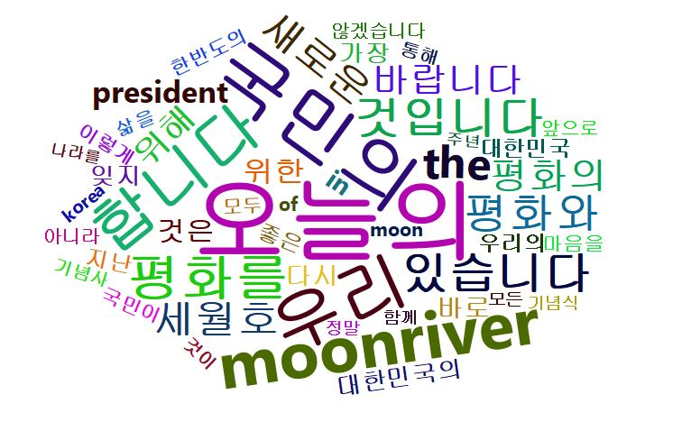

### 트윗 작성 디바이스 현황

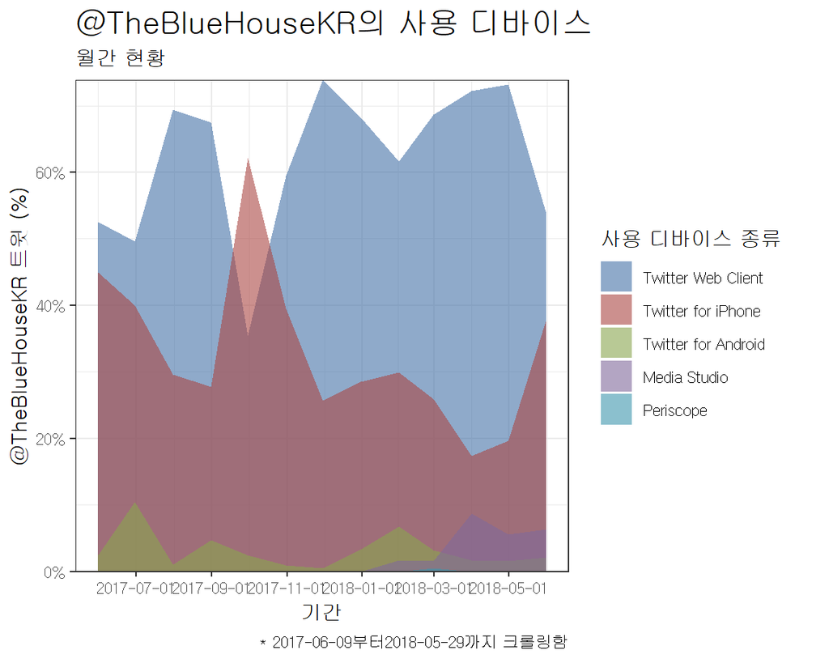

### 2017-06-09부터2018-05-29까지 요약

| 년월 | 트윗건 | 리트윗건 | 좋아요건 |
| --- | --- | --- | --- |
| 2017-06 | 96 | 96,738 | 85,773 |
| 2017-07 | 118 | 123,295 | 126,222 |
| 2017-08 | 101 | 114,562 | 111,980 |
| 2017-09 | 198 | 197,640 | 162,858 |
| 2017-10 | 137 | 116,752 | 102,762 |
| 2017-11 | 239 | 307,536 | 192,463 |
| 2017-12 | 150 | 155,312 | 153,973 |
| 2018-01 | 157 | 160,430 | 141,719 |
| 2018-02 | 173 | 235,051 | 137,268 |
| 2018-03 | 273 | 297,119 | 258,469 |
| 2018-04 | 263 | 356,200 | 285,494 |
| 2018-05 | 228 | 590,271 | 307,433 |

# 현안별 트윗 현황

### 국내 현안

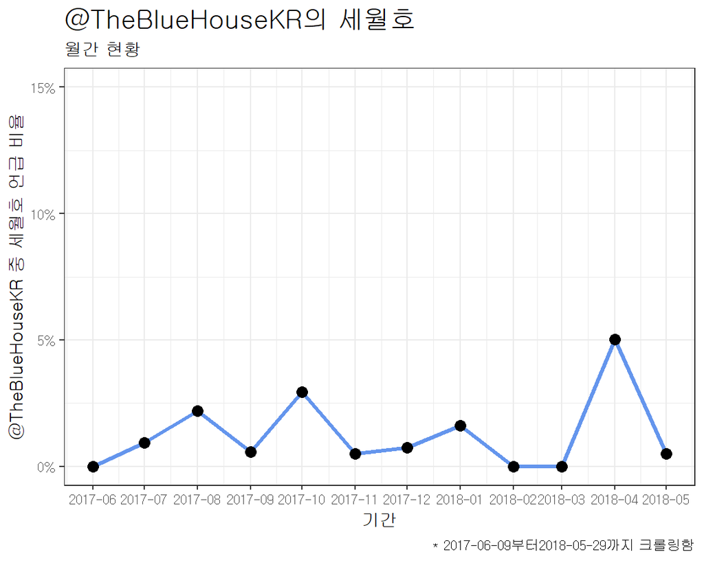

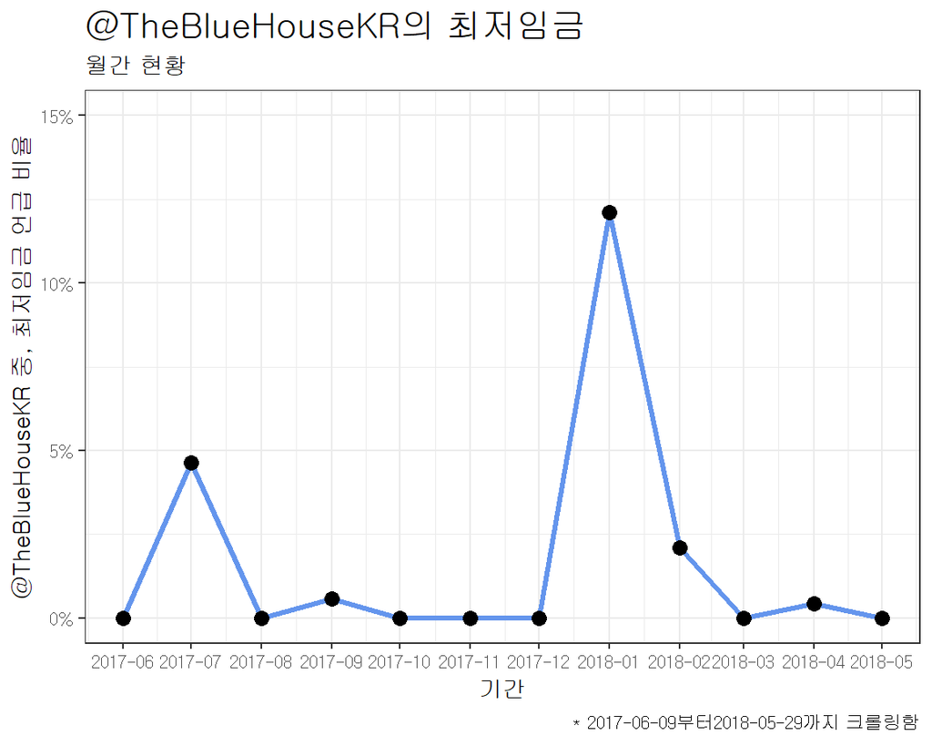

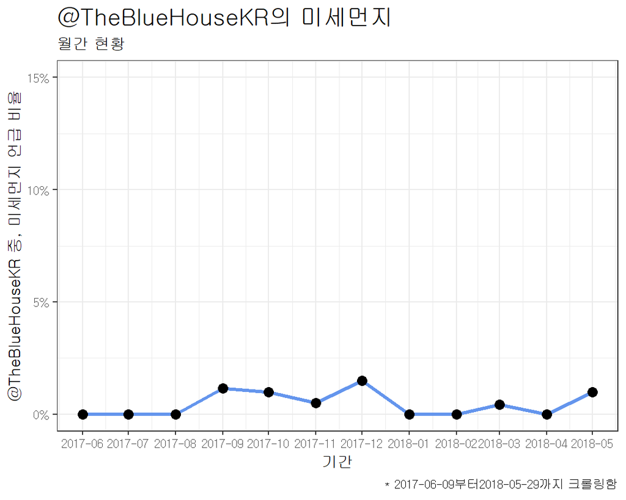

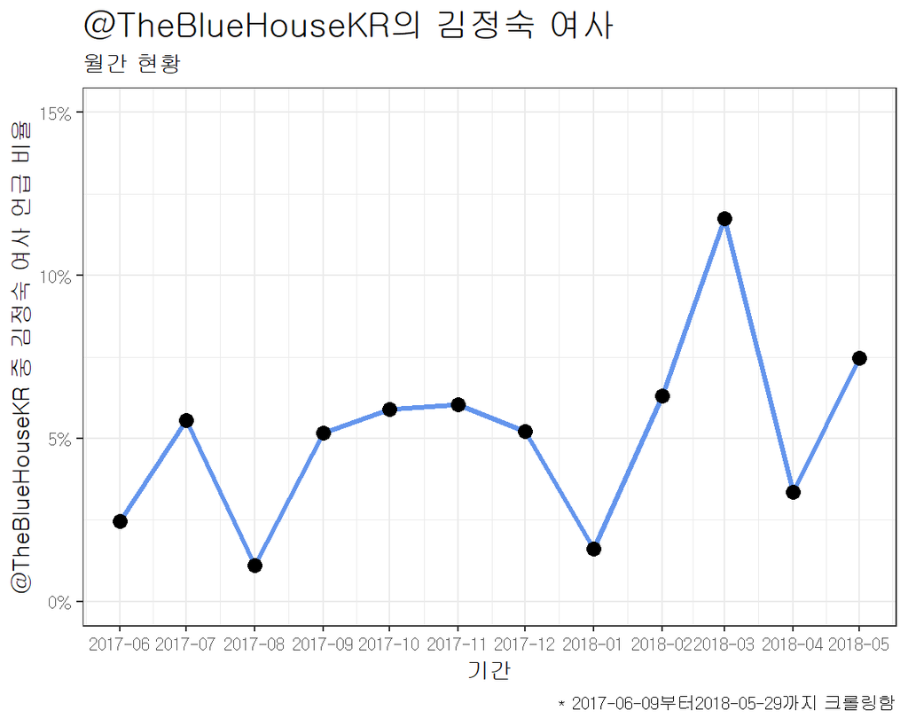

### 국제 외교

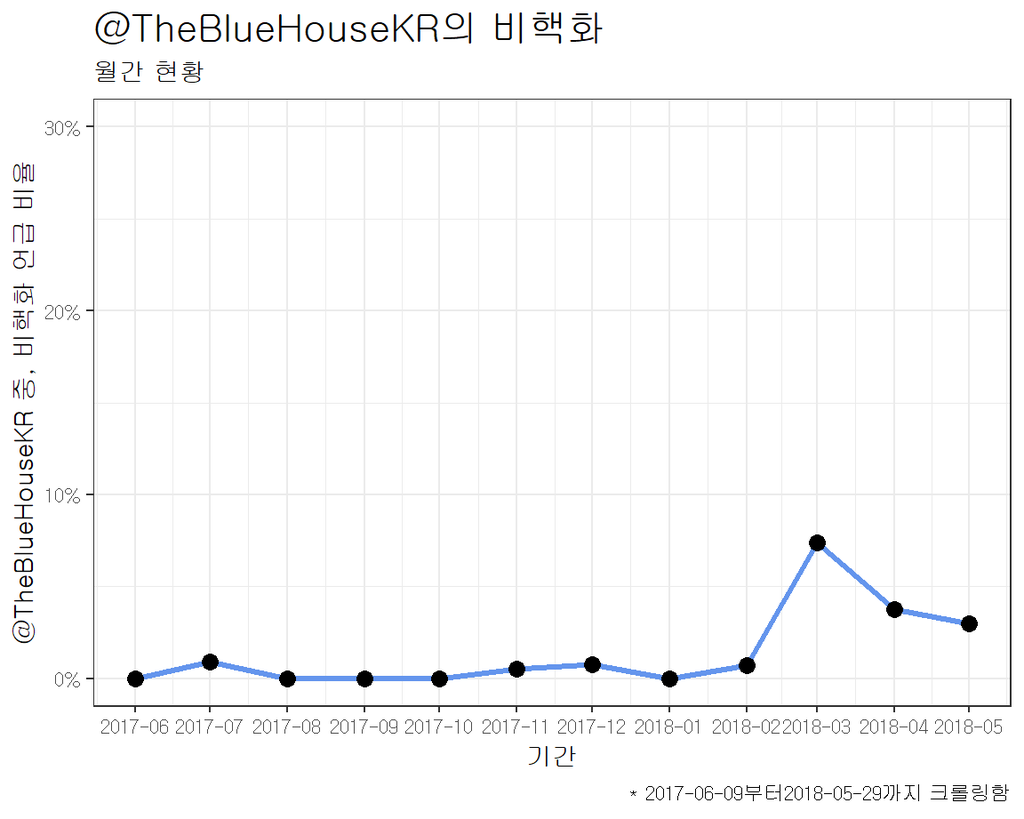

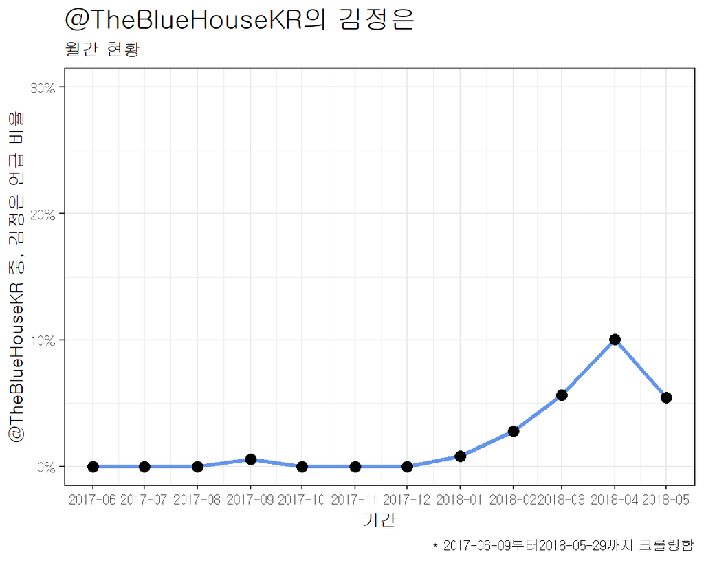

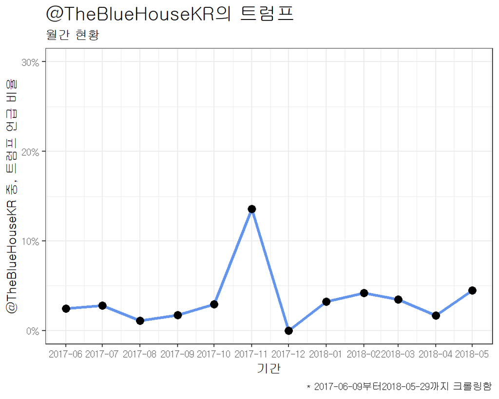

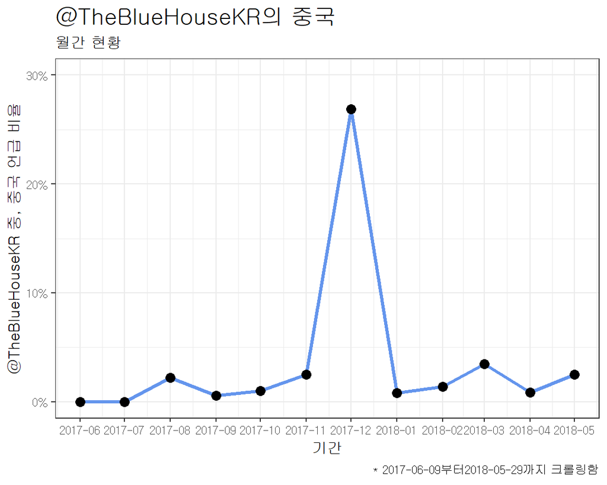

# Topic 모델링과 시각화

### 토픽 모델링

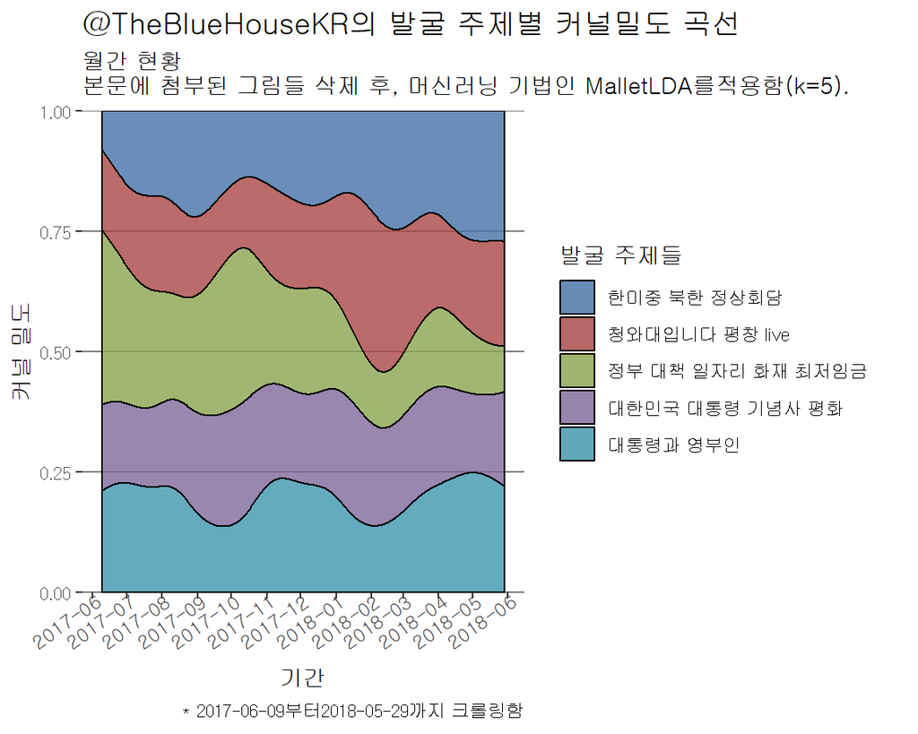

### 각종 시각화

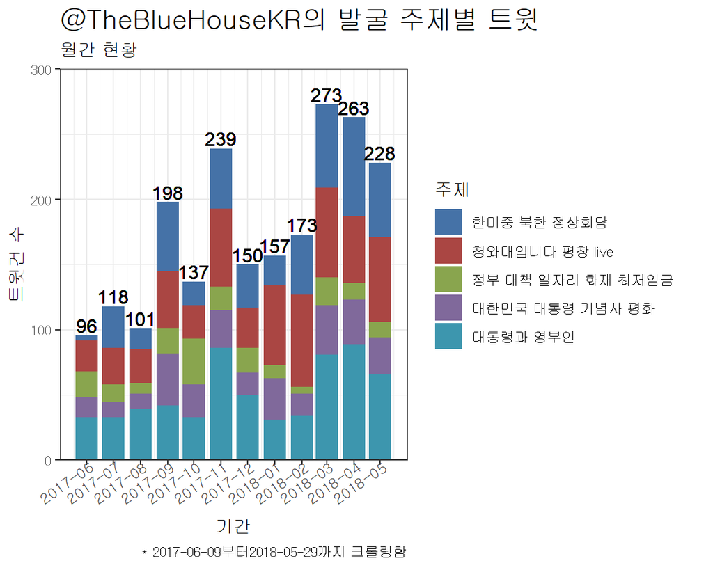

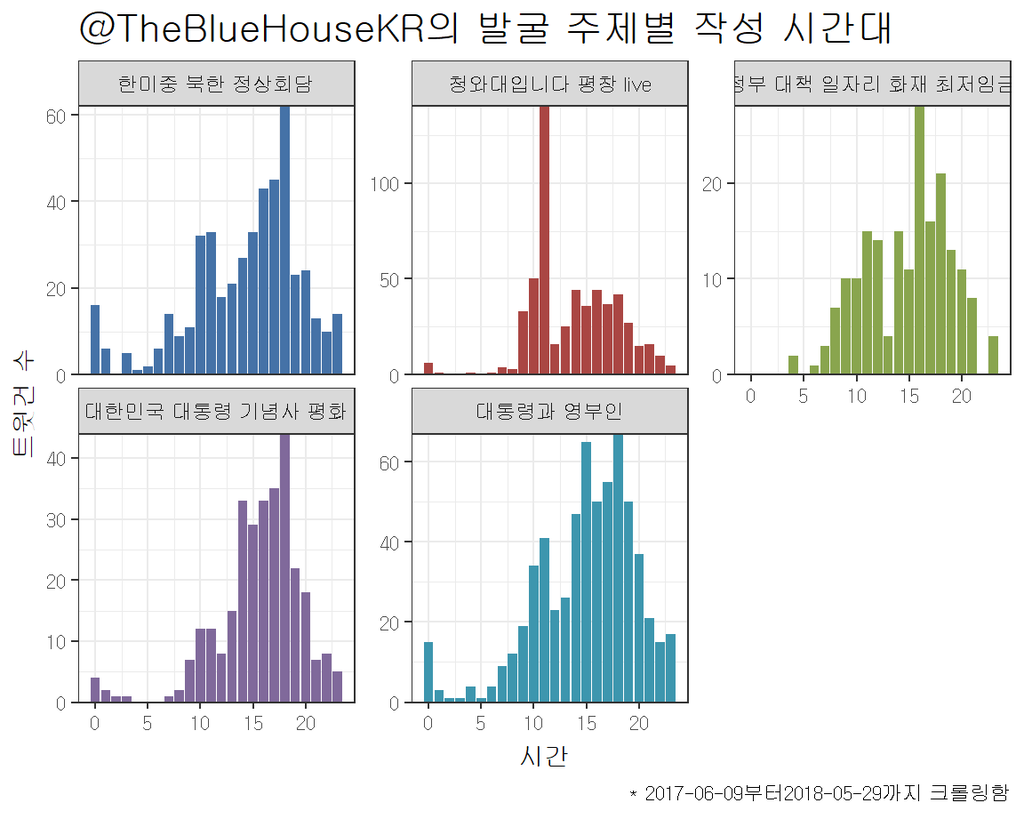

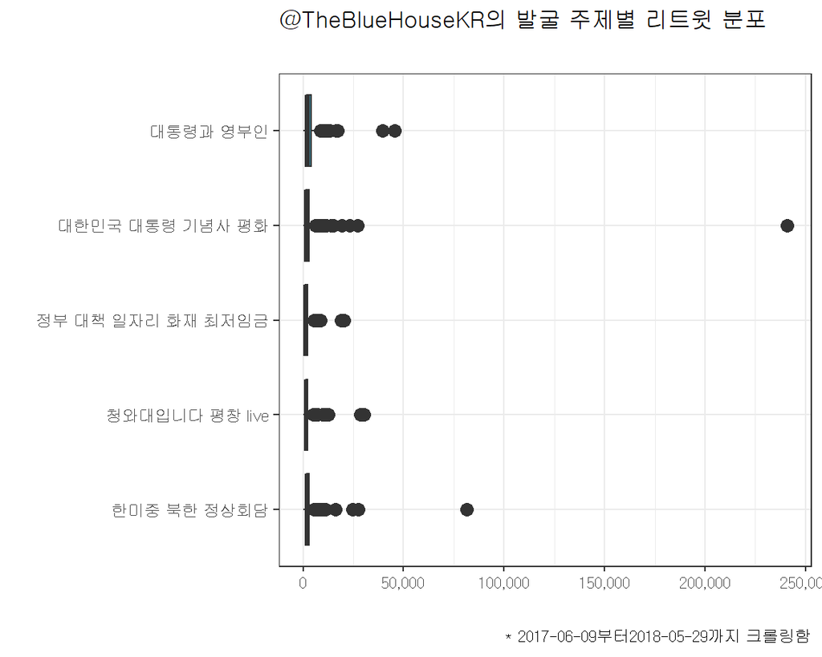

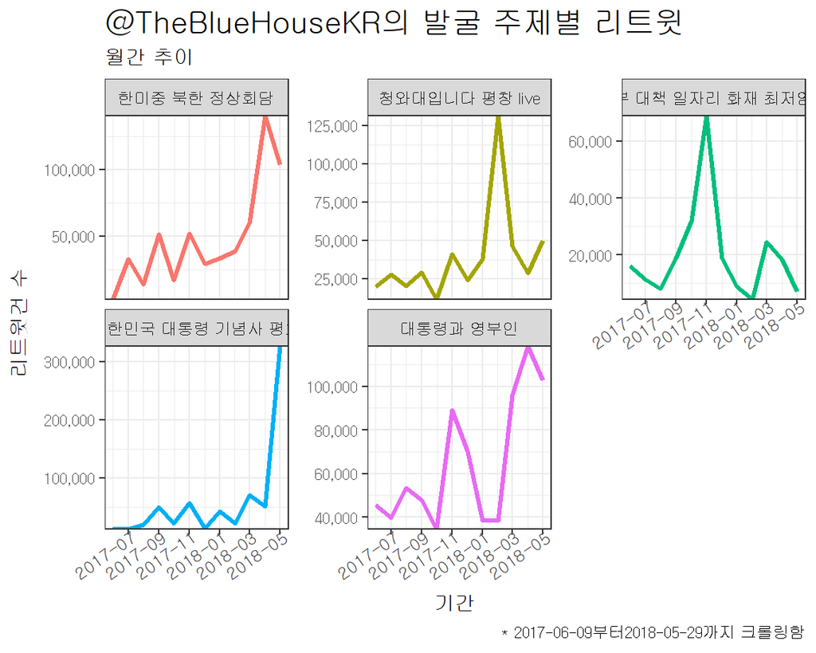